# DINA at the FS-analogous criterion: naive / field / field-s / IJ two-term across both prevalences

- Show All Code
- Hide All Code
- View Source

Campaign dinamr (effMaxSG eps 0.20, J 10, n 500 / 1000 / 1500 at HR 1.50 / 1.75 / 1.00, 12.4% and 31% prevalence); TASK_dinamr_campaign_2026-09-10 and TASK_dinamr_blockC_grfprobe_2026-09-11 (Block C and the deferred Block B cell); transplanted from summary_cert20.qmd

Author

Larry Leon

Published

September 12, 2026

> **This does not certify DINA.** DINA’s candidates are read off a cross-fit surface that a bootstrap would regenerate, so the manuscript’s fixed-family condition (§2.1) does not hold. After the alignment repair the estimate and interval are first-order exact **conditional on the proposed family**. **Every coverage number in this document is coverage of that conditional-on-proposed-family estimand**, and every table says so in its caption. Nothing here is scored against an acceptance criterion; none was pre-registered and none is proposed. The FS ranges quoted in Section 7 are reference lines, not a bar.

**The criterion is FS-analogous by construction.** `effMaxSG` at ε = 0.20 reuses `.compute_inclusion_band()` — the one band helper shared with `forestsearch()` — with DINA’s effect floor log(0.90) = −0.105361 and **no consistency term**. That absent consistency term is the one structural difference from FS, because neither DINA nor GRF has a consistency floor (`REPORT_o1_forwarding_2026-09-10` §V2). DINA applies the band as a **sort key**, so it never empties. `dina_select_statistic = "effect"`, which is also the package default. `FS_S7_ER_JCUTS` is **inert on DINA** — it feeds the consistency-only `method_args`, and DINA’s candidate grid does not read it — so it was deliberately not set; the `er_jcuts` recorded in meta is the template default 10 and governs nothing on this path.

**Grid.** Two prevalence blocks at ε = 0.20: **Block A** = 12.4% (`harm_z1_quantile` at the template default 0.25) and **Block B** = 31% (`FS_S7_Z1Q = 0.60`), each at HR 1.50 and 1.75 for n = 500 / 1000 / 1500; **Block C** = the HR 1.00 null cells at both prevalences. Seeds 8316951 + sim_id, sim_id 1–2000 as two seed-disjoint batches of 1,000, then combined. **GRF is out of scope.**

**Standing conventions.** Bounds read by location, never as significance at the null; Wilson 95% limits everywhere; marginal and error SDs side by side; NPV beside sens/spec/PPV; winner-only and winner-floor excluded throughout.

# 1 Bundles and the Gate 2 record

```r
library(forestsearch)
library(ggplot2)
library(kableExtra)   # kbl(), kable_styling(), scroll_box()
`%||%` <- function(a, b) if (is.null(a) || length(a) == 0 || all(is.na(a))) b else a
R <- "results/"
mk <- function(block, prev, n, hr, arm) {
  z <- if (block == "A") "" else "_z1q60"
  list(label = sprintf("%s: HR %.2f, n %d", block, hr, n),
       block = block, prev = prev, n = n, hr = hr, arm = arm,
       file = sprintf("%sdina_effMaxSG_fb_mr_field_m1_h%03d_knoise0_n%d%s_nb20_dinamr_combined_1_2000.rds",
                      R, round(100 * hr), n, z))
}
cells <- c(
  lapply(list(c(1.50,500),c(1.50,1000),c(1.50,1500),c(1.75,500),c(1.75,1000),c(1.75,1500)),
         function(x) mk("A", 0.124, as.integer(x[2]), x[1], "harm")),
  lapply(list(c(1.50,500),c(1.50,1000),c(1.50,1500),c(1.75,500),c(1.75,1000),c(1.75,1500)),
         function(x) mk("B", 0.31,  as.integer(x[2]), x[1], "harm")),
  lapply(list(c(1.00,500),c(1.00,1000),c(1.00,1500)),
         function(x) mk("A", 0.124, as.integer(x[2]), x[1], "null")),
  lapply(list(c(1.00,500),c(1.00,1000),c(1.00,1500)),
         function(x) mk("B", 0.31,  as.integer(x[2]), x[1], "null")))
names(cells) <- vapply(cells, `[[`, "", "label")

present <- vapply(cells, function(cl) file.exists(cl$file), TRUE)
B  <- lapply(cells[present], function(cl) readRDS(cl$file))
CL <- cells[present]; labs <- names(CL)
NN  <- vapply(CL, `[[`, 0L, "n");   HR  <- vapply(CL, `[[`, 0, "hr")
ARM <- vapply(CL, `[[`, "", "arm"); BLK <- vapply(CL, `[[`, "", "block")
harm_labs <- labs[ARM == "harm"]; null_labs <- labs[ARM == "null"]
A_labs <- labs[BLK == "A"]; B_labs <- labs[BLK == "B"]

# THE ABSENT-CELL GUARD (the A3 behaviour on the e1stud set: a per-cell chunk
# rendered an empty table rather than being skipped).  Every chunk below that
# could produce an empty artifact is wrapped in have() / skip_note().
have <- function(x) length(x) > 0L && nrow(as.data.frame(x)) > 0L
skip_note <- function(what) cat(sprintf("\n*Skipped: %s. Not rendered empty -- the cell(s) it needs are absent from this render.*\n\n", what))

missing_cells <- names(cells)[!present]
cat(sprintf("Cells on disk: %d of %d.\n", sum(present), length(cells)))
```

```
Cells on disk: 18 of 18.
```

```r
if (length(missing_cells))
  cat("DEFERRED / NOT ON DISK (omitted from every table below, not rendered empty):\n  - ",
      paste(missing_cells, collapse = "\n  - "), "\n", sep = "")
```

```r
if (!length(labs)) { skip_note("the whole document: no dinamr bundle is on disk") } else {
INV <- do.call(rbind, lapply(labs, function(k) {
  b <- B[[k]]; r <- b$results; m <- b$meta
  data.frame(cell = k, block = BLK[[k]], n = NN[[k]], HR = HR[[k]], arm = ARM[[k]], rows = nrow(r),
             engine = m$subgroup_method %||% NA, campaign = m$campaign_tag %||% NA,
             focus = m$sg_focus %||% NA, eps = m$effect_neighborhood %||% NA,
             z1q = m$harm_z1_quantile %||% NA, prev_super = m$harm_prevalence_super %||% NA,
             prev_trial = mean(r$n_true) / NN[[k]],
             scale_c = m$field_scale_complement %||% NA, decomp = m$field_decompose %||% NA,
             recov = m$field_recovery %||% NA, ij = m$ij_residual %||% NA,
             fsver = m$forestsearch_version %||% NA,
             detected = sum(r$detected %in% 1L),
             detection = mean(r$detected %in% 1L),
             K_med = stats::median(r$n_family, na.rm = TRUE),
             K_q90 = unname(stats::quantile(r$n_family, .9, na.rm = TRUE)),
             marg_H = unname(b$truth$marg_H), marg_Hc = unname(b$truth$marg_Hc)) }))
kbl(INV, digits = 4, booktabs = TRUE, row.names = FALSE,
    caption = "The cells on disk: engine and knobs as recorded in the pooled meta, realized prevalence (super-population and trial mean), DETECTION RATE, proposed-family size (median, q90), and the marginal Cox targets. Cells absent from disk are omitted here and everywhere below.") |>
  kable_styling(font_size = 9)
}
```

The cells on disk: engine and knobs as recorded in the pooled meta, realized prevalence (super-population and trial mean), DETECTION RATE, proposed-family size (median, q90), and the marginal Cox targets. Cells absent from disk are omitted here and everywhere below.

| cell | block | n | HR | arm | rows | engine | campaign | focus | eps | z1q | prev_super | prev_trial | scale_c | decomp | recov | ij | fsver | detected | detection | K_med | K_q90 | marg_H | marg_Hc |
| --- | --- | --- | --- | --- | --- | --- | --- | --- | --- | --- | --- | --- | --- | --- | --- | --- | --- | --- | --- | --- | --- | --- | --- |
| A: HR 1.50, n 500 | A | 500 | 1.50 | harm | 2000 | dina | dinamr | effMaxSG | 0.2 | 0.25 | 0.1242 | 0.1236 | selected | TRUE | TRUE | two_term | 0.3.5 | 1750 | 0.8750 | 253.5 | 1111.2 | 1.5086 | 0.6569 |
| A: HR 1.50, n 1000 | A | 1000 | 1.50 | harm | 2000 | dina | dinamr | effMaxSG | 0.2 | 0.25 | 0.1242 | 0.1239 | selected | TRUE | TRUE | two_term | 0.3.5 | 1677 | 0.8385 | 156.0 | 628.0 | 1.5086 | 0.6569 |
| A: HR 1.50, n 1500 | A | 1500 | 1.50 | harm | 2000 | dina | dinamr | effMaxSG | 0.2 | 0.25 | 0.1242 | 0.1240 | selected | TRUE | TRUE | two_term | 0.3.5 | 1597 | 0.7985 | 103.0 | 394.0 | 1.5086 | 0.6569 |
| A: HR 1.75, n 500 | A | 500 | 1.75 | harm | 2000 | dina | dinamr | effMaxSG | 0.2 | 0.25 | 0.1242 | 0.1236 | selected | TRUE | TRUE | two_term | 0.3.5 | 1816 | 0.9080 | 332.0 | 1273.5 | 1.7691 | 0.6569 |
| A: HR 1.75, n 1000 | A | 1000 | 1.75 | harm | 2000 | dina | dinamr | effMaxSG | 0.2 | 0.25 | 0.1242 | 0.1239 | selected | TRUE | TRUE | two_term | 0.3.5 | 1813 | 0.9065 | 232.0 | 807.2 | 1.7691 | 0.6569 |
| A: HR 1.75, n 1500 | A | 1500 | 1.75 | harm | 2000 | dina | dinamr | effMaxSG | 0.2 | 0.25 | 0.1242 | 0.1240 | selected | TRUE | TRUE | two_term | 0.3.5 | 1796 | 0.8980 | 177.0 | 526.0 | 1.7691 | 0.6569 |
| B: HR 1.50, n 500 | B | 500 | 1.50 | harm | 2000 | dina | dinamr | effMaxSG | 0.2 | 0.60 | 0.3066 | 0.3059 | selected | TRUE | TRUE | two_term | 0.3.5 | 1997 | 0.9985 | 1495.0 | 2880.8 | 1.4990 | 0.7206 |
| B: HR 1.50, n 1000 | B | 1000 | 1.50 | harm | 2000 | dina | dinamr | effMaxSG | 0.2 | 0.60 | 0.3066 | 0.3063 | selected | TRUE | TRUE | two_term | 0.3.5 | 2000 | 1.0000 | 1709.5 | 2984.3 | 1.4990 | 0.7206 |
| B: HR 1.50, n 1500 | B | 1500 | 1.50 | harm | 2000 | dina | dinamr | effMaxSG | 0.2 | 0.60 | 0.3066 | 0.3065 | selected | TRUE | TRUE | two_term | 0.3.5 | 2000 | 1.0000 | 1743.5 | 2850.3 | 1.4990 | 0.7206 |
| B: HR 1.75, n 500 | B | 500 | 1.75 | harm | 2000 | dina | dinamr | effMaxSG | 0.2 | 0.60 | 0.3066 | 0.3059 | selected | TRUE | TRUE | two_term | 0.3.5 | 2000 | 1.0000 | 1954.5 | 2982.2 | 1.7462 | 0.7206 |
| B: HR 1.75, n 1000 | B | 1000 | 1.75 | harm | 2000 | dina | dinamr | effMaxSG | 0.2 | 0.60 | 0.3066 | 0.3063 | selected | TRUE | TRUE | two_term | 0.3.5 | 2000 | 1.0000 | 2257.5 | 3160.0 | 1.7462 | 0.7206 |
| B: HR 1.75, n 1500 | B | 1500 | 1.75 | harm | 2000 | dina | dinamr | effMaxSG | 0.2 | 0.60 | 0.3066 | 0.3065 | selected | TRUE | TRUE | two_term | 0.3.5 | 2000 | 1.0000 | 2355.5 | 3108.0 | 1.7462 | 0.7206 |
| A: HR 1.00, n 500 | A | 500 | 1.00 | null | 2000 | dina | dinamr | effMaxSG | 0.2 | 0.25 | 0.1242 | 0.1236 | selected | TRUE | TRUE | two_term | 0.3.5 | 1427 | 0.7135 | 137.0 | 745.6 | 1.0005 | 0.6569 |
| A: HR 1.00, n 1000 | A | 1000 | 1.00 | null | 2000 | dina | dinamr | effMaxSG | 0.2 | 0.25 | 0.1242 | 0.1239 | selected | TRUE | TRUE | two_term | 0.3.5 | 1049 | 0.5245 | 66.0 | 355.4 | 1.0005 | 0.6569 |
| A: HR 1.00, n 1500 | A | 1500 | 1.00 | null | 2000 | dina | dinamr | effMaxSG | 0.2 | 0.25 | 0.1242 | 0.1240 | selected | TRUE | TRUE | two_term | 0.3.5 | 687 | 0.3435 | 36.0 | 211.2 | 1.0005 | 0.6569 |
| B: HR 1.00, n 500 | B | 500 | 1.00 | null | 2000 | dina | dinamr | effMaxSG | 0.2 | 0.60 | 0.3066 | 0.3059 | selected | TRUE | TRUE | two_term | 0.3.5 | 1860 | 0.9300 | 485.5 | 1965.4 | 0.9999 | 0.7206 |
| B: HR 1.00, n 1000 | B | 1000 | 1.00 | null | 2000 | dina | dinamr | effMaxSG | 0.2 | 0.60 | 0.3066 | 0.3063 | selected | TRUE | TRUE | two_term | 0.3.5 | 1852 | 0.9260 | 349.0 | 1347.8 | 0.9999 | 0.7206 |
| B: HR 1.00, n 1500 | B | 1500 | 1.00 | null | 2000 | dina | dinamr | effMaxSG | 0.2 | 0.60 | 0.3066 | 0.3065 | selected | TRUE | TRUE | two_term | 0.3.5 | 1776 | 0.8880 | 278.5 | 895.5 | 0.9999 | 0.7206 |

## 1.1 Detection rate, recorded prominently

Every summary in this document conditions on detection, and DINA’s detection rate differs from FS’s. It is therefore stated before any coverage number.

```r
if (!have(labs)) skip_note("the detection table") else {
DET <- INV[, c("cell", "block", "n", "HR", "arm", "detected", "detection", "K_med", "K_q90", "prev_trial")]
DET <- DET[order(DET$arm, DET$block, DET$HR, DET$n), ]
kbl(DET, digits = 4, booktabs = TRUE, row.names = FALSE,
    caption = "DETECTION RATE per cell out of 2,000 replicates, with the proposed-family size (median and q90) and the realized trial prevalence beside it. Every coverage number in this document is computed on the detected replicates of the cell named in its row, and is coverage of the conditional-on-proposed-family estimand.") |>
  kable_styling(font_size = 10)
}
```

DETECTION RATE per cell out of 2,000 replicates, with the proposed-family size (median and q90) and the realized trial prevalence beside it. Every coverage number in this document is computed on the detected replicates of the cell named in its row, and is coverage of the conditional-on-proposed-family estimand.

| cell | block | n | HR | arm | detected | detection | K_med | K_q90 | prev_trial |
| --- | --- | --- | --- | --- | --- | --- | --- | --- | --- |
| A: HR 1.50, n 500 | A | 500 | 1.50 | harm | 1750 | 0.8750 | 253.5 | 1111.2 | 0.1236 |
| A: HR 1.50, n 1000 | A | 1000 | 1.50 | harm | 1677 | 0.8385 | 156.0 | 628.0 | 0.1239 |
| A: HR 1.50, n 1500 | A | 1500 | 1.50 | harm | 1597 | 0.7985 | 103.0 | 394.0 | 0.1240 |
| A: HR 1.75, n 500 | A | 500 | 1.75 | harm | 1816 | 0.9080 | 332.0 | 1273.5 | 0.1236 |
| A: HR 1.75, n 1000 | A | 1000 | 1.75 | harm | 1813 | 0.9065 | 232.0 | 807.2 | 0.1239 |
| A: HR 1.75, n 1500 | A | 1500 | 1.75 | harm | 1796 | 0.8980 | 177.0 | 526.0 | 0.1240 |
| B: HR 1.50, n 500 | B | 500 | 1.50 | harm | 1997 | 0.9985 | 1495.0 | 2880.8 | 0.3059 |
| B: HR 1.50, n 1000 | B | 1000 | 1.50 | harm | 2000 | 1.0000 | 1709.5 | 2984.3 | 0.3063 |
| B: HR 1.50, n 1500 | B | 1500 | 1.50 | harm | 2000 | 1.0000 | 1743.5 | 2850.3 | 0.3065 |
| B: HR 1.75, n 500 | B | 500 | 1.75 | harm | 2000 | 1.0000 | 1954.5 | 2982.2 | 0.3059 |
| B: HR 1.75, n 1000 | B | 1000 | 1.75 | harm | 2000 | 1.0000 | 2257.5 | 3160.0 | 0.3063 |
| B: HR 1.75, n 1500 | B | 1500 | 1.75 | harm | 2000 | 1.0000 | 2355.5 | 3108.0 | 0.3065 |
| A: HR 1.00, n 500 | A | 500 | 1.00 | null | 1427 | 0.7135 | 137.0 | 745.6 | 0.1236 |
| A: HR 1.00, n 1000 | A | 1000 | 1.00 | null | 1049 | 0.5245 | 66.0 | 355.4 | 0.1239 |
| A: HR 1.00, n 1500 | A | 1500 | 1.00 | null | 687 | 0.3435 | 36.0 | 211.2 | 0.1240 |
| B: HR 1.00, n 500 | B | 500 | 1.00 | null | 1860 | 0.9300 | 485.5 | 1965.4 | 0.3059 |
| B: HR 1.00, n 1000 | B | 1000 | 1.00 | null | 1852 | 0.9260 | 349.0 | 1347.8 | 0.3063 |
| B: HR 1.00, n 1500 | B | 1500 | 1.00 | null | 1776 | 0.8880 | 278.5 | 895.5 | 0.3065 |

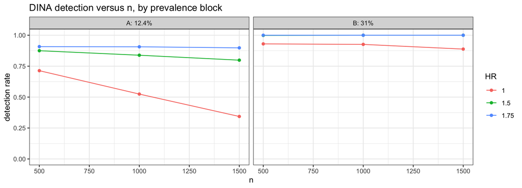

```r
if (!have(labs)) skip_note("the detection plot") else {
DP <- INV[, c("n", "HR", "block", "detection")]
DP$HR <- factor(DP$HR); DP$block <- factor(DP$block, levels = c("A","B"),
                                           labels = c("A: 12.4%", "B: 31%"))
ggplot(DP, aes(n, detection, colour = HR, group = HR)) +
  geom_point() + geom_line() + facet_wrap(~ block) + ylim(0, 1) +
  labs(x = "n", y = "detection rate", title = "DINA detection versus n, by prevalence block") +
  theme_bw(base_size = 11)
}
```

## 1.2 Structurally-NA columns

```r
if (!have(labs)) skip_note("the structural-NA table") else {
SN <- do.call(rbind, lapply(labs, function(k) {
  r <- B[[k]]$results
  f <- function(cn) if (!cn %in% names(r)) "not a recorder column" else
                    if (all(is.na(r[[cn]]))) "all-NA (structural)" else "POPULATED"
  data.frame(cell = k, n_cons_qual = f("n_cons_qual"), band_n = f("band_n"),
             p_star = if ("p_star" %in% names(r)) f("p_star") else "not a recorder column") }))
kbl(SN, booktabs = TRUE, row.names = FALSE,
    caption = "n_cons_qual and band_n are STRUCTURALLY NA on DINA: both read grp.consistency$out_sg$result, which the DINA branch never produces. p_star is not a recorder column at all -- it is the admission set's consistency term, NULL on DINA by the branch's own design. These are reported as structural, NOT as failures.") |>
  kable_styling(font_size = 10)
}
```

n_cons_qual and band_n are STRUCTURALLY NA on DINA: both read grp.consistency$out_sg$result, which the DINA branch never produces. p_star is not a recorder column at all -- it is the admission set's consistency term, NULL on DINA by the branch's own design. These are reported as structural, NOT as failures.

| cell | n_cons_qual | band_n | p_star |
| --- | --- | --- | --- |
| A: HR 1.50, n 500 | all-NA (structural) | all-NA (structural) | not a recorder column |
| A: HR 1.50, n 1000 | all-NA (structural) | all-NA (structural) | not a recorder column |
| A: HR 1.50, n 1500 | all-NA (structural) | all-NA (structural) | not a recorder column |
| A: HR 1.75, n 500 | all-NA (structural) | all-NA (structural) | not a recorder column |
| A: HR 1.75, n 1000 | all-NA (structural) | all-NA (structural) | not a recorder column |
| A: HR 1.75, n 1500 | all-NA (structural) | all-NA (structural) | not a recorder column |
| B: HR 1.50, n 500 | all-NA (structural) | all-NA (structural) | not a recorder column |
| B: HR 1.50, n 1000 | all-NA (structural) | all-NA (structural) | not a recorder column |
| B: HR 1.50, n 1500 | all-NA (structural) | all-NA (structural) | not a recorder column |
| B: HR 1.75, n 500 | all-NA (structural) | all-NA (structural) | not a recorder column |
| B: HR 1.75, n 1000 | all-NA (structural) | all-NA (structural) | not a recorder column |
| B: HR 1.75, n 1500 | all-NA (structural) | all-NA (structural) | not a recorder column |
| A: HR 1.00, n 500 | all-NA (structural) | all-NA (structural) | not a recorder column |
| A: HR 1.00, n 1000 | all-NA (structural) | all-NA (structural) | not a recorder column |
| A: HR 1.00, n 1500 | all-NA (structural) | all-NA (structural) | not a recorder column |
| B: HR 1.00, n 500 | all-NA (structural) | all-NA (structural) | not a recorder column |
| B: HR 1.00, n 1000 | all-NA (structural) | all-NA (structural) | not a recorder column |
| B: HR 1.00, n 1500 | all-NA (structural) | all-NA (structural) | not a recorder column |

# 2 Standard tables: constructions on both blocks

```r
subst_s <- function(r) { for (s in c("est2","up1s","lo1s","lo2s","hi2s","lo_se","hi_se","se","lam_mean"))
  r[[paste0("fld_Hc_", s)]] <- r[[paste0("fld_Hc_", s, "_s")]]; r }
err_sd <- function(r, block, est) { d <- r[r$detected %in% 1L, ]
  e <- switch(est, naive = d[[paste0("nv_", block, "_est")]],
                   mr    = d[[paste0("mr_", block, "_est")]],
                   fld   = d[[paste0("fld_", block, "_est2")]])
  ok <- is.finite(e) & is.finite(d[[paste0("betaHhat_", block)]])
  stats::sd(log(e[ok]) - log(d[[paste0("betaHhat_", block)]][ok])) }
cov_block <- function(r, block, side) {
  t1 <- fs_sim_bias_coverage(r, block = block, estimators = c("naive","mr","fld"), side = side)
  t1$sd_err <- vapply(as.character(t1$estimator), function(e) err_sd(r, block, e), 0)
  t1$construction <- c(naive="naive", mr="IJ two-term", fld="field")[as.character(t1$estimator)]
  if (block == "Hc") { rs <- subst_s(r)
    t2 <- fs_sim_bias_coverage(rs, block = "Hc", estimators = "fld", side = side)
    t2$sd_err <- err_sd(rs, "Hc", "fld"); t2$construction <- "field-s"; t1 <- rbind(t1, t2) }
  t1$se_over_sd_err <- t1$se_mean / t1$sd_err
  t1$b_err <- t1$bias_log / t1$sd_err
  # SECOND GAUSSIAN REFERENCE, on the ERROR SD.  cov1_ref (from
  # fs_sim_bias_coverage) is built on the MARGINAL SD; this twin uses the error
  # SD of the de-biased residual, which is the SD the interval is actually
  # trying to cover.  Formulae, stated here and in every caption that shows it:
  #   lower bounds (harm block Hhat):        cov1_ref_err = Phi(1.645 * SE/sd_err - b_err)
  #   upper bounds (complement block Hhat^c): cov1_ref_err = Phi(1.645 * SE/sd_err + b_err)
  # with SE/sd_err = se_over_sd_err and b_err = bias_log / sd_err.
  z95_ <- stats::qnorm(0.95)
  t1$cov1_ref_err <- if (identical(side, "lower"))
      stats::pnorm(z95_ * t1$se_over_sd_err - t1$b_err) else
      stats::pnorm(z95_ * t1$se_over_sd_err + t1$b_err)
  t1 }
```

```r
if (!have(labs)) skip_note("the standard construction tables") else {
COV <- do.call(rbind, lapply(labs, function(k) { r <- B[[k]]$results
  rbind(cbind(cell = k, block_grp = BLK[[k]], n_sample = NN[[k]], hr_cell = HR[[k]], arm = ARM[[k]],
              block = "Hhat (lower)",   cov_block(r, "H",  "lower")),
        cbind(cell = k, block_grp = BLK[[k]], n_sample = NN[[k]], hr_cell = HR[[k]], arm = ARM[[k]],
              block = "Hhat^c (upper)", cov_block(r, "Hc", "upper"))) }))
COV$construction <- factor(COV$construction, levels = c("naive","field","field-s","IJ two-term"))
COV <- COV[order(match(COV$cell, labs), COV$block, COV$construction), ]
for (blk in c("A","B")) {
  sub <- COV[COV$block_grp == blk, ]
  if (!have(sub)) { skip_note(sprintf("the standard table for Block %s", blk)); next }
  print(kbl(sub[, c("cell","block","construction","n_sample","n","bias_log","sd_emp","sd_err",
                    "b","b_err","se_mean","r","se_over_sd_err","cov1","cov1_wilson_lo",
                    "cov1_wilson_hi","cov2","cov1_ref","cov1_ref_err")],
      digits = 3, booktabs = TRUE, row.names = FALSE,
      caption = sprintf("BLOCK %s (%s prevalence). Per cell and block: bias on the log scale; marginal SD (sd_emp) and error SD (sd_err) side by side; b = bias / marginal SD, b_err = bias / error SD; mean SE; r = SE / marginal SD and SE / error SD; cov1 = one-sided 95%% coverage on the exposed side (lower for beta(Hhat), upper for beta(Hhat^c)) with Wilson limits; cov2 = two-sided; cov1_ref = the Gaussian reference on the MARGINAL SD, cov1_ref_err its twin on the ERROR SD -- cov1_ref_err = Phi(1.645 * se_over_sd_err - b_err) for the harm block's LOWER bound and Phi(1.645 * se_over_sd_err + b_err) for the complement block's UPPER bound, where b_err = bias_log / sd_err. EVERY COVERAGE COLUMN (cov1, cov1_wilson_lo, cov1_wilson_hi, cov2) IS COVERAGE OF THE CONDITIONAL-ON-PROPOSED-FAMILY ESTIMAND, on detected replicates only. The harm block has no field-s row (field-s = field there by construction). naive is a reference, never a product.",
                          blk, if (blk == "A") "12.4%" else "31%")) |>
      kable_styling(font_size = 9))
}
}
```

[output not shown]

[output cut: 2646 more lines]

[output not shown]

```r
if (!have(labs)) skip_note("the across-cell summary") else {
ACR <- do.call(rbind, lapply(split(COV, list(COV$block, COV$construction, COV$arm, COV$block_grp),
                                   drop = TRUE), function(d)
  data.frame(prevalence_block = d$block_grp[1], arm = d$arm[1], block = d$block[1],
             construction = d$construction[1], cells = nrow(d),
             cov1_min = min(d$cov1), cov1_mean = mean(d$cov1), cov1_max = max(d$cov1),
             cov2_mean = mean(d$cov2), b_mean = mean(d$b), r_mean = mean(d$r),
             se_over_sd_err_mean = mean(d$se_over_sd_err))))
ACR <- ACR[order(ACR$prevalence_block, ACR$arm, ACR$block, ACR$construction), ]
kbl(ACR, digits = 3, booktabs = TRUE, row.names = FALSE,
    caption = "Across cells within each prevalence block and arm: range and mean of the one-sided coverage, mean two-sided coverage, mean b and r. All coverages are of the conditional-on-proposed-family estimand.") |>
  kable_styling(font_size = 9)
}
```

Across cells within each prevalence block and arm: range and mean of the one-sided coverage, mean two-sided coverage, mean b and r. All coverages are of the conditional-on-proposed-family estimand.

| prevalence_block | arm | block | construction | cells | cov1_min | cov1_mean | cov1_max | cov2_mean | b_mean | r_mean | se_over_sd_err_mean |
| --- | --- | --- | --- | --- | --- | --- | --- | --- | --- | --- | --- |
| A | harm | Hhat (lower) | naive | 6 | 0.370 | 0.564 | 0.747 | 0.681 | 1.292 | 0.836 | 0.910 |
| A | harm | Hhat (lower) | field | 6 | 0.902 | 0.921 | 0.944 | 0.931 | 0.238 | 0.797 | 0.937 |
| A | harm | Hhat (lower) | IJ two-term | 6 | 0.973 | 0.980 | 0.989 | 0.992 | 0.371 | 1.206 | 1.406 |
| A | harm | Hhat^c (upper) | naive | 6 | 0.850 | 0.887 | 0.912 | 0.933 | -0.535 | 1.050 | 1.063 |
| A | harm | Hhat^c (upper) | field | 6 | 0.918 | 0.934 | 0.948 | 0.941 | -0.096 | 0.969 | 0.979 |
| A | harm | Hhat^c (upper) | field-s | 6 | 0.921 | 0.937 | 0.949 | 0.945 | -0.097 | 0.980 | 0.989 |
| A | harm | Hhat^c (upper) | IJ two-term | 6 | 0.998 | 0.999 | 1.000 | 1.000 | -0.155 | 1.903 | 1.917 |
| A | null | Hhat (lower) | naive | 3 | 0.265 | 0.289 | 0.304 | 0.456 | 2.507 | 1.203 | 1.117 |
| A | null | Hhat (lower) | field | 3 | 0.825 | 0.850 | 0.875 | 0.895 | 0.789 | 0.973 | 0.978 |
| A | null | Hhat (lower) | IJ two-term | 3 | 0.965 | 0.968 | 0.974 | 0.990 | 1.084 | 1.529 | 1.528 |
| A | null | Hhat^c (upper) | naive | 3 | 0.864 | 0.906 | 0.937 | 0.950 | -0.530 | 1.116 | 1.136 |
| A | null | Hhat^c (upper) | field | 3 | 0.927 | 0.941 | 0.952 | 0.956 | -0.101 | 1.019 | 1.029 |
| A | null | Hhat^c (upper) | field-s | 3 | 0.930 | 0.943 | 0.953 | 0.957 | -0.101 | 1.032 | 1.042 |
| A | null | Hhat^c (upper) | IJ two-term | 3 | 0.998 | 0.999 | 1.000 | 1.000 | -0.169 | 2.022 | 2.045 |
| B | harm | Hhat (lower) | naive | 6 | 0.377 | 0.598 | 0.794 | 0.698 | 1.297 | 0.888 | 0.749 |
| B | harm | Hhat (lower) | field | 6 | 0.915 | 0.943 | 0.961 | 0.917 | -0.063 | 1.008 | 0.915 |
| B | harm | Hhat (lower) | IJ two-term | 6 | 0.967 | 0.980 | 0.993 | 0.984 | 0.031 | 1.301 | 1.158 |
| B | harm | Hhat^c (upper) | naive | 6 | 0.781 | 0.842 | 0.886 | 0.901 | -0.553 | 0.827 | 1.024 |
| B | harm | Hhat^c (upper) | field | 6 | 0.900 | 0.925 | 0.940 | 0.931 | -0.095 | 0.777 | 0.939 |
| B | harm | Hhat^c (upper) | field-s | 6 | 0.910 | 0.933 | 0.944 | 0.944 | -0.098 | 0.810 | 0.979 |
| B | harm | Hhat^c (upper) | IJ two-term | 6 | 0.997 | 0.998 | 0.999 | 1.000 | -0.156 | 1.506 | 1.828 |
| B | null | Hhat (lower) | naive | 3 | 0.280 | 0.398 | 0.524 | 0.527 | 1.855 | 0.974 | 0.883 |
| B | null | Hhat (lower) | field | 3 | 0.906 | 0.929 | 0.947 | 0.954 | 0.391 | 1.103 | 1.038 |
| B | null | Hhat (lower) | IJ two-term | 3 | 0.966 | 0.979 | 0.991 | 0.994 | 0.592 | 1.564 | 1.451 |
| B | null | Hhat^c (upper) | naive | 3 | 0.788 | 0.817 | 0.835 | 0.898 | -0.893 | 1.039 | 1.121 |
| B | null | Hhat^c (upper) | field | 3 | 0.895 | 0.915 | 0.925 | 0.938 | -0.265 | 0.941 | 0.994 |
| B | null | Hhat^c (upper) | field-s | 3 | 0.903 | 0.923 | 0.936 | 0.946 | -0.266 | 0.970 | 1.025 |
| B | null | Hhat^c (upper) | IJ two-term | 3 | 0.997 | 0.998 | 0.999 | 1.000 | -0.371 | 1.849 | 1.960 |

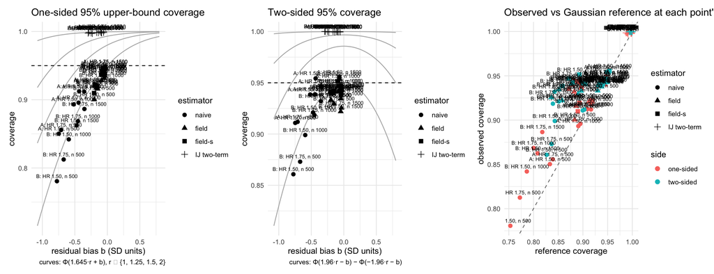

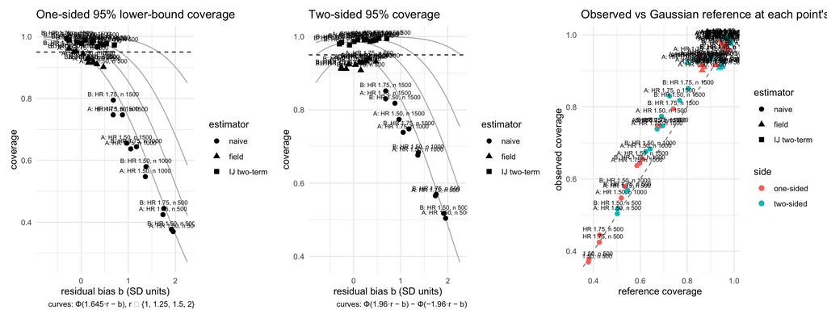

```r
if (!length(harm_labs)) skip_note("the bias/coverage panels (no harm cell on disk)") else {
for (sd_ in list(list(bl = "Hhat^c (upper)", side = "upper"), list(bl = "Hhat (lower)", side = "lower"))) {
  tab <- COV[COV$block == sd_$bl & COV$arm == "harm", ]
  if (!have(tab)) { skip_note(sprintf("the %s panel", sd_$bl)); next }
  tab$estimator <- tab$construction
  tab <- tab[, setdiff(names(tab), c("n_sample","hr_cell","arm","block","block_grp",
                                     "sd_err","se_over_sd_err","b_err","construction"))]
  print(fs_plot_bias_coverage(tab, curves = c(1, 1.25, 1.5, 2), side = sd_$side))
}
}
```

# 3 Coverage versus n, both prevalences

```r
# THE FS COMPARATOR THAT SHARES THE DGM DRAWS, per cell, with its OWN criterion.
# Block A (12.4%): p12ext at HR 1.50/1.00 and tier2 at HR 1.75 -- maxeffCons, eps 0.10.
# Block B (31%)  : cert20 at n 1000/1500 and e1stud at n 500  -- effMaxSG, eps 0.20;
#                  at HR 1.00 (Block C's 31% cells) cert20 at all three n.
# The criterion therefore MATCHES DINA's at 31% and DIFFERS at 12.4%; every FS
# number below carries its own sg_focus and eps so the reader never has to
# remember which.
fs_file <- function(blk, hr, n) {
  if (blk == "A") {
    camp <- if (abs(hr - 1.75) < 1e-9) "tier2" else if (abs(hr - 1.00) < 1e-9 && n == 500L) "tier2" else "p12ext"
    sprintf("%sfs_maxeffCons_fb_mr_field_m1_h%03d_knoise0_n%d_%s_combined_1_2000.rds", R, round(100*hr), n, camp)
  } else {
    # e1stud was run only at HR 1.50 and 1.75.  At HR 1.00 the n = 500 / 31%
    # comparator is cert20, which IS on disk and is likewise effMaxSG at
    # eps 0.20 -- so the null cells at 31% stay criterion-matched
    # (TASK_dinamr_blockC_grfprobe_2026-09-11).
    camp <- if (n == 500L && abs(hr - 1.00) > 1e-9) "e1stud" else "cert20"
    sprintf("%sfs_effMaxSG_fb_mr_field_m1_h%03d_knoise0_n%d_z1q60_nb20_%s_combined_1_2000.rds", R, round(100*hr), n, camp)
  } }
fs_for <- function(k) { f <- fs_file(BLK[[k]], HR[[k]], NN[[k]])
  if (!file.exists(f)) return(NULL); b <- readRDS(f)
  list(b = b, file = basename(f), campaign = b$meta$campaign_tag %||% NA,
       focus = b$meta$sg_focus %||% NA, eps = b$meta$effect_neighborhood %||% NA_real_) }
fs_crit <- function(x) sprintf("%s / %s / eps %s", x$campaign, x$focus, format(x$eps))
```

```r
wil <- function(p, n, z = stats::qnorm(0.975)) {
  ctr <- (p + z^2 / (2 * n)) / (1 + z^2 / n)
  hw  <- z * sqrt(p * (1 - p) / n + z^2 / (4 * n^2)) / (1 + z^2 / n)
  c(ctr - hw, ctr + hw) }
z95 <- stats::qnorm(0.95); z975 <- stats::qnorm(0.975)
covs_cell <- function(k) {
  r <- B[[k]]$results
  d <- r[r$detected %in% 1L & is.finite(r$betaHhat_H) & is.finite(r$betaHhat_Hc) &
         is.finite(r$fld_H_lo1s) & is.finite(r$fld_Hc_up1s_s), , drop = FALSE]
  if (!nrow(d)) return(NULL)
  cH  <- mean(d$betaHhat_H  >= d$fld_H_lo1s)
  cC  <- mean(d$betaHhat_Hc <= d$fld_Hc_up1s_s)
  cCf <- mean(d$betaHhat_Hc <= d$fld_Hc_up1s)
  ij_H  <- mean(d$betaHhat_H  >= d$mr_H_lo  & d$betaHhat_H  <= d$mr_H_hi)
  ij_Hc <- mean(d$betaHhat_Hc >= d$mr_Hc_lo & d$betaHhat_Hc <= d$mr_Hc_hi)
  # the two-sided miss, split by side -- the question in Stage 3 item 5
  miss_lo <- mean(d$betaHhat_H < d$mr_H_lo)     # truth below the interval
  miss_hi <- mean(d$betaHhat_H > d$mr_H_hi)     # truth above the interval
  jt  <- mean(d$betaHhat_H >= d$fld_joint_bonf_loH   & d$betaHhat_Hc <= d$fld_joint_bonf_upHc)
  jts <- mean(d$betaHhat_H >= d$fld_joint_s_bonf_loH & d$betaHhat_Hc <= d$fld_joint_s_bonf_upHc)
  g <- function(p) { w <- wil(p, nrow(d)); c(p, w) }
  data.frame(cell = k, block = BLK[[k]], n = NN[[k]], HR = HR[[k]], arm = ARM[[k]], n_eval = nrow(d),
             harm_field = cH, harm_field_lo = g(cH)[2], harm_field_hi = g(cH)[3],
             comp_field_s = cC, comp_field_s_lo = g(cC)[2], comp_field_s_hi = g(cC)[3],
             comp_field = cCf, comp_field_lo = g(cCf)[2], comp_field_hi = g(cCf)[3],
             ij2_H = ij_H, ij2_H_lo = g(ij_H)[2], ij2_H_hi = g(ij_H)[3],
             miss_below = miss_lo, miss_above = miss_hi,
             ij2_Hc = ij_Hc, ij2_Hc_lo = g(ij_Hc)[2], ij2_Hc_hi = g(ij_Hc)[3],
             joint_bonf = jt, joint_bonf_lo = g(jt)[2], joint_bonf_hi = g(jt)[3],
             joint_s_bonf = jts, joint_s_bonf_lo = g(jts)[2], joint_s_bonf_hi = g(jts)[3]) }
VSN <- if (length(labs)) do.call(rbind, lapply(labs, covs_cell)) else NULL
if (have(VSN)) VSN <- VSN[order(VSN$arm, VSN$block, VSN$HR, VSN$n), ]
```

```r
if (!have(VSN)) skip_note("coverage versus n") else {
vh <- VSN[VSN$arm == "harm", ]
if (!have(vh)) skip_note("the harm-block coverage table") else
kbl(vh[, c("cell","block","n","HR","n_eval","harm_field","harm_field_lo","harm_field_hi",
           "ij2_H","ij2_H_lo","ij2_H_hi","miss_below","miss_above")],
    digits = 4, booktabs = TRUE, row.names = FALSE,
    caption = "Harm cells, both prevalence blocks: one-sided 95% LOWER coverage of beta(Hhat) by the field bound, and TWO-SIDED coverage by the IJ two-term interval, with Wilson limits, against n at each HR; the two-sided miss split by side (miss_below = truth under the lower limit, miss_above = truth over the upper limit). All coverages are of the conditional-on-proposed-family estimand, on detected replicates.") |>
  kable_styling(font_size = 9)
}
```

Harm cells, both prevalence blocks: one-sided 95% LOWER coverage of beta(Hhat) by the field bound, and TWO-SIDED coverage by the IJ two-term interval, with Wilson limits, against n at each HR; the two-sided miss split by side (miss_below = truth under the lower limit, miss_above = truth over the upper limit). All coverages are of the conditional-on-proposed-family estimand, on detected replicates.

| cell | block | n | HR | n_eval | harm_field | harm_field_lo | harm_field_hi | ij2_H | ij2_H_lo | ij2_H_hi | miss_below | miss_above |
| --- | --- | --- | --- | --- | --- | --- | --- | --- | --- | --- | --- | --- |
| A: HR 1.50, n 500 | A | 500 | 1.50 | 1750 | 0.9017 | 0.8869 | 0.9148 | 0.9949 | 0.9903 | 0.9973 | 0.0040 | 0.0011 |
| A: HR 1.50, n 1000 | A | 1000 | 1.50 | 1677 | 0.9153 | 0.9010 | 0.9277 | 0.9887 | 0.9824 | 0.9927 | 0.0089 | 0.0024 |
| A: HR 1.50, n 1500 | A | 1500 | 1.50 | 1597 | 0.9286 | 0.9149 | 0.9402 | 0.9925 | 0.9869 | 0.9957 | 0.0025 | 0.0050 |
| A: HR 1.75, n 500 | A | 500 | 1.75 | 1816 | 0.9108 | 0.8968 | 0.9231 | 0.9950 | 0.9906 | 0.9974 | 0.0050 | 0.0000 |
| A: HR 1.75, n 1000 | A | 1000 | 1.75 | 1813 | 0.9272 | 0.9143 | 0.9383 | 0.9912 | 0.9857 | 0.9946 | 0.0061 | 0.0028 |
| A: HR 1.75, n 1500 | A | 1500 | 1.75 | 1796 | 0.9443 | 0.9327 | 0.9540 | 0.9911 | 0.9856 | 0.9945 | 0.0028 | 0.0061 |
| B: HR 1.50, n 500 | B | 500 | 1.50 | 1997 | 0.9159 | 0.9029 | 0.9273 | 0.9905 | 0.9852 | 0.9939 | 0.0095 | 0.0000 |
| B: HR 1.50, n 1000 | B | 1000 | 1.50 | 2000 | 0.9515 | 0.9412 | 0.9601 | 0.9865 | 0.9804 | 0.9907 | 0.0065 | 0.0070 |
| B: HR 1.50, n 1500 | B | 1500 | 1.50 | 2000 | 0.9610 | 0.9516 | 0.9686 | 0.9840 | 0.9775 | 0.9886 | 0.0045 | 0.0115 |
| B: HR 1.75, n 500 | B | 500 | 1.75 | 2000 | 0.9155 | 0.9025 | 0.9269 | 0.9870 | 0.9810 | 0.9911 | 0.0095 | 0.0035 |
| B: HR 1.75, n 1000 | B | 1000 | 1.75 | 2000 | 0.9505 | 0.9401 | 0.9592 | 0.9770 | 0.9695 | 0.9827 | 0.0070 | 0.0160 |
| B: HR 1.75, n 1500 | B | 1500 | 1.75 | 2000 | 0.9610 | 0.9516 | 0.9686 | 0.9800 | 0.9729 | 0.9853 | 0.0040 | 0.0160 |

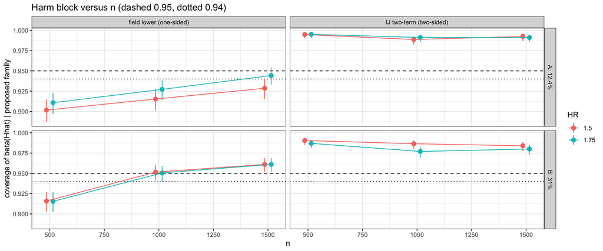

```r
if (!have(VSN) || !have(VSN[VSN$arm == "harm", ])) skip_note("the harm-block coverage plot") else {
ph <- VSN[VSN$arm == "harm", ]
PH <- rbind(
  data.frame(n = ph$n, HR = factor(ph$HR), blk = ph$block,
             construction = "field lower (one-sided)", cov = ph$harm_field,
             lo = ph$harm_field_lo, hi = ph$harm_field_hi),
  data.frame(n = ph$n, HR = factor(ph$HR), blk = ph$block,
             construction = "IJ two-term (two-sided)", cov = ph$ij2_H,
             lo = ph$ij2_H_lo, hi = ph$ij2_H_hi))
PH$blk <- factor(PH$blk, levels = c("A","B"), labels = c("A: 12.4%", "B: 31%"))
ggplot(PH, aes(n, cov, colour = HR, group = HR)) +
  geom_hline(yintercept = 0.95, linetype = 2) + geom_hline(yintercept = 0.94, linetype = 3) +
  geom_pointrange(aes(ymin = lo, ymax = hi), position = position_dodge(width = 60)) +
  geom_line(position = position_dodge(width = 60)) +
  facet_grid(blk ~ construction) +
  labs(x = "n", y = "coverage of beta(Hhat) | proposed family",
       title = "Harm block versus n (dashed 0.95, dotted 0.94)") + theme_bw(base_size = 11)
}
```

```r
if (!have(VSN) || !have(VSN[VSN$arm == "harm", ])) skip_note("the complement-block table") else
kbl(VSN[VSN$arm == "harm", c("cell","block","n","HR","n_eval","comp_field_s","comp_field_s_lo",
                             "comp_field_s_hi","comp_field","ij2_Hc","ij2_Hc_lo","ij2_Hc_hi",
                             "joint_bonf","joint_s_bonf","joint_s_bonf_lo","joint_s_bonf_hi")],
    digits = 4, booktabs = TRUE, row.names = FALSE,
    caption = "Harm cells: one-sided 95% UPPER coverage of beta(Hhat^c) by field-s (Wilson) with the unscaled field beside it; two-sided IJ two-term coverage; and the Bonferroni joint pair from the unscaled joint and from joint_s. Conditional-on-proposed-family estimand throughout.") |>
  kable_styling(font_size = 9)
```

Harm cells: one-sided 95% UPPER coverage of beta(Hhat^c) by field-s (Wilson) with the unscaled field beside it; two-sided IJ two-term coverage; and the Bonferroni joint pair from the unscaled joint and from joint_s. Conditional-on-proposed-family estimand throughout.

| cell | block | n | HR | n_eval | comp_field_s | comp_field_s_lo | comp_field_s_hi | comp_field | ij2_Hc | ij2_Hc_lo | ij2_Hc_hi | joint_bonf | joint_s_bonf | joint_s_bonf_lo | joint_s_bonf_hi |
| --- | --- | --- | --- | --- | --- | --- | --- | --- | --- | --- | --- | --- | --- | --- | --- |
| A: HR 1.50, n 500 | A | 500 | 1.50 | 1750 | 0.9223 | 0.9088 | 0.9339 | 0.9206 | 1.0000 | 0.9978 | 1.0000 | 0.9046 | 0.9086 | 0.8942 | 0.9212 |
| A: HR 1.50, n 1000 | A | 1000 | 1.50 | 1677 | 0.9422 | 0.9299 | 0.9524 | 0.9410 | 0.9994 | 0.9966 | 0.9999 | 0.9261 | 0.9284 | 0.9151 | 0.9398 |
| A: HR 1.50, n 1500 | A | 1500 | 1.50 | 1597 | 0.9461 | 0.9340 | 0.9562 | 0.9399 | 1.0000 | 0.9976 | 1.0000 | 0.9324 | 0.9349 | 0.9217 | 0.9460 |
| A: HR 1.75, n 500 | A | 500 | 1.75 | 1816 | 0.9213 | 0.9080 | 0.9328 | 0.9180 | 1.0000 | 0.9979 | 1.0000 | 0.9169 | 0.9169 | 0.9033 | 0.9287 |
| A: HR 1.75, n 1000 | A | 1000 | 1.75 | 1813 | 0.9388 | 0.9268 | 0.9489 | 0.9382 | 0.9994 | 0.9969 | 0.9999 | 0.9288 | 0.9300 | 0.9173 | 0.9408 |
| A: HR 1.75, n 1500 | A | 1500 | 1.75 | 1796 | 0.9488 | 0.9376 | 0.9580 | 0.9482 | 1.0000 | 0.9979 | 1.0000 | 0.9404 | 0.9415 | 0.9297 | 0.9515 |
| B: HR 1.50, n 500 | B | 500 | 1.50 | 1997 | 0.9099 | 0.8965 | 0.9217 | 0.9004 | 1.0000 | 0.9981 | 1.0000 | 0.9084 | 0.9119 | 0.8986 | 0.9235 |
| B: HR 1.50, n 1000 | B | 1000 | 1.50 | 2000 | 0.9365 | 0.9250 | 0.9464 | 0.9285 | 1.0000 | 0.9981 | 1.0000 | 0.9405 | 0.9455 | 0.9347 | 0.9546 |
| B: HR 1.50, n 1500 | B | 1500 | 1.50 | 2000 | 0.9420 | 0.9309 | 0.9514 | 0.9320 | 1.0000 | 0.9981 | 1.0000 | 0.9460 | 0.9535 | 0.9434 | 0.9619 |
| B: HR 1.75, n 500 | B | 500 | 1.75 | 2000 | 0.9195 | 0.9068 | 0.9306 | 0.9160 | 0.9995 | 0.9972 | 0.9999 | 0.9005 | 0.9080 | 0.8945 | 0.9199 |
| B: HR 1.75, n 1000 | B | 1000 | 1.75 | 2000 | 0.9435 | 0.9325 | 0.9528 | 0.9395 | 1.0000 | 0.9981 | 1.0000 | 0.9390 | 0.9440 | 0.9330 | 0.9533 |
| B: HR 1.75, n 1500 | B | 1500 | 1.75 | 2000 | 0.9440 | 0.9330 | 0.9533 | 0.9350 | 0.9995 | 0.9972 | 0.9999 | 0.9455 | 0.9520 | 0.9417 | 0.9605 |

# 4 The two-sided question: does FS’s harm-block decay with n at 12.4% appear on DINA?

On FS at 12.4% the harm-block **two-sided** IJ coverage decays with n — 0.977 → 0.932 → 0.901 at HR 1.50 and 0.961 → 0.917 → 0.913 at HR 1.75, across n = 500 / 1000 / 1500 (`p12ext` / `tier2`, read as they stand). The same trajectory is computed here on DINA, with the miss split by side.

```r
FS_REF <- data.frame(HR = c(1.50,1.50,1.50,1.75,1.75,1.75), n = c(500,1000,1500,500,1000,1500),
                     fs_ij2_H = c(0.977,0.932,0.901,0.961,0.917,0.913),
                     # the criterion each FS number was produced under -- NOT DINA's
                     fs_criterion = c(rep("p12ext / maxeffCons / eps 0.1", 3),
                                      rep("tier2 / maxeffCons / eps 0.1", 3)),
                     stringsAsFactors = FALSE)
if (!have(VSN)) skip_note("the two-sided comparison") else {
TS <- VSN[VSN$arm == "harm" & VSN$block == "A", c("cell","n","HR","n_eval","ij2_H","ij2_H_lo","ij2_H_hi","miss_below","miss_above")]
if (!have(TS)) skip_note("the two-sided comparison at 12.4% (Block A not on disk)") else {
TS <- merge(TS, FS_REF, by = c("HR","n"), all.x = TRUE)
TS <- TS[order(TS$HR, TS$n), ]
TS$dina_minus_fs <- TS$ij2_H - TS$fs_ij2_H
kbl(TS[, c("cell","n","HR","n_eval","ij2_H","ij2_H_lo","ij2_H_hi","miss_below","miss_above","fs_ij2_H","fs_criterion","dina_minus_fs")],
    digits = 4, booktabs = TRUE, row.names = FALSE,
    caption = "BLOCK A (12.4%), harm cells: DINA's two-sided IJ two-term coverage of beta(Hhat) against n, with the miss split by side, beside the committed FS trajectory (fs_ij2_H, from p12ext / tier2 read as they stand). DINA's column is coverage of the conditional-on-proposed-family estimand at effMaxSG / eps 0.20; FS's is its own, produced under the criterion named in fs_criterion -- maxeffCons at eps 0.10, which is NOT DINA's, so at 12.4% the criterion is a fourth confounded difference. See @sec-fsgrid. Descriptive, not a contest.") |>
  kable_styling(font_size = 10)
}
}
```

BLOCK A (12.4%), harm cells: DINA's two-sided IJ two-term coverage of beta(Hhat) against n, with the miss split by side, beside the committed FS trajectory (fs_ij2_H, from p12ext / tier2 read as they stand). DINA's column is coverage of the conditional-on-proposed-family estimand at effMaxSG / eps 0.20; FS's is its own, produced under the criterion named in fs_criterion -- maxeffCons at eps 0.10, which is NOT DINA's, so at 12.4% the criterion is a fourth confounded difference. See @sec-fsgrid. Descriptive, not a contest.

| cell | n | HR | n_eval | ij2_H | ij2_H_lo | ij2_H_hi | miss_below | miss_above | fs_ij2_H | fs_criterion | dina_minus_fs |
| --- | --- | --- | --- | --- | --- | --- | --- | --- | --- | --- | --- |
| A: HR 1.50, n 500 | 500 | 1.50 | 1750 | 0.9949 | 0.9903 | 0.9973 | 0.0040 | 0.0011 | 0.977 | p12ext / maxeffCons / eps 0.1 | 0.0179 |
| A: HR 1.50, n 1000 | 1000 | 1.50 | 1677 | 0.9887 | 0.9824 | 0.9927 | 0.0089 | 0.0024 | 0.932 | p12ext / maxeffCons / eps 0.1 | 0.0567 |
| A: HR 1.50, n 1500 | 1500 | 1.50 | 1597 | 0.9925 | 0.9869 | 0.9957 | 0.0025 | 0.0050 | 0.901 | p12ext / maxeffCons / eps 0.1 | 0.0915 |
| A: HR 1.75, n 500 | 500 | 1.75 | 1816 | 0.9950 | 0.9906 | 0.9974 | 0.0050 | 0.0000 | 0.961 | tier2 / maxeffCons / eps 0.1 | 0.0340 |
| A: HR 1.75, n 1000 | 1000 | 1.75 | 1813 | 0.9912 | 0.9857 | 0.9946 | 0.0061 | 0.0028 | 0.917 | tier2 / maxeffCons / eps 0.1 | 0.0742 |
| A: HR 1.75, n 1500 | 1500 | 1.75 | 1796 | 0.9911 | 0.9856 | 0.9945 | 0.0028 | 0.0061 | 0.913 | tier2 / maxeffCons / eps 0.1 | 0.0781 |

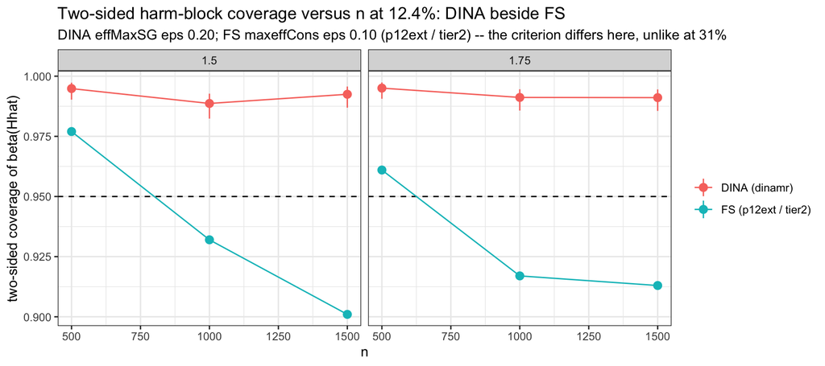

```r
if (!have(VSN) || !have(VSN[VSN$arm == "harm" & VSN$block == "A", ])) skip_note("the two-sided plot") else {
TP2 <- rbind(
  data.frame(n = TS$n, HR = factor(TS$HR), who = "DINA (dinamr)", cov = TS$ij2_H, lo = TS$ij2_H_lo, hi = TS$ij2_H_hi),
  data.frame(n = TS$n, HR = factor(TS$HR), who = "FS (p12ext / tier2)", cov = TS$fs_ij2_H, lo = NA, hi = NA))
ggplot(TP2, aes(n, cov, colour = who, group = who)) +
  geom_hline(yintercept = 0.95, linetype = 2) +
  geom_pointrange(aes(ymin = lo, ymax = hi), na.rm = TRUE) + geom_line() + facet_wrap(~ HR) +
  labs(x = "n", y = "two-sided coverage of beta(Hhat)", colour = NULL,
       title = "Two-sided harm-block coverage versus n at 12.4%: DINA beside FS",
       subtitle = "DINA effMaxSG eps 0.20; FS maxeffCons eps 0.10 (p12ext / tier2) -- the criterion differs here, unlike at 31%") +
  theme_bw(base_size = 11)
}
```

# 5 Classification versus n and prevalence

```r
if (!have(labs)) skip_note("the classification table") else {
IDENT <- do.call(rbind, lapply(labs, function(k) {
  r <- B[[k]]$results; d <- r[r$detected %in% 1L, , drop = FALSE]; tr <- B[[k]]$truth
  if (!nrow(d)) return(NULL)
  rat <- d$n_harm / d$n_true
  onv_H  <- mean(log(d$nv_H_est)  - log(d$betaHhat_H))
  onv_Hc <- mean(log(d$nv_Hc_est) - log(d$betaHhat_Hc))
  sdm_H  <- stats::sd(log(d$nv_H_est));  sde_H  <- stats::sd(log(d$nv_H_est)  - log(d$betaHhat_H))
  sdm_Hc <- stats::sd(log(d$nv_Hc_est)); sde_Hc <- stats::sd(log(d$nv_Hc_est) - log(d$betaHhat_Hc))
  data.frame(cell = k, block = BLK[[k]], n = NN[[k]], HR = HR[[k]], arm = ARM[[k]],
             detection = mean(r$detected %in% 1L), n_det = nrow(d),
             sens = mean(d$sens), spec = mean(d$spec), ppv = mean(d$ppv), npv = mean(d$npv),
             absH_mean = mean(d$n_sel), absHtrue_mean = mean(d$n_true),
             Hhat_over_H_med = stats::median(rat), Hhat_over_H_q90 = unname(stats::quantile(rat, .9)),
             beta_H_mean = mean(d$betaHhat_H), planted_H = unname(tr$marg_H),
             beta_Hc_mean = mean(d$betaHhat_Hc), planted_Hc = unname(tr$marg_Hc),
             naive_opt_H_marg = onv_H / sdm_H, naive_opt_H_err = onv_H / sde_H,
             naive_opt_Hc_marg = onv_Hc / sdm_Hc, naive_opt_Hc_err = onv_Hc / sde_Hc,
             p_hat_mean = mean(d$p_hat_H[is.finite(d$p_hat_H)]),
             K_mean = mean(d$n_family, na.rm = TRUE),
             K_med = stats::median(d$n_family, na.rm = TRUE)) }))
IDENT <- IDENT[order(IDENT$arm, IDENT$block, IDENT$HR, IDENT$n), ]
kbl(IDENT, digits = 3, booktabs = TRUE, row.names = FALSE,
    caption = "Classification against n and prevalence: detection; sens / spec / PPV / NPV; mean |Hhat|; |Hhat|/|H| median and q90; the realized beta(Hhat) and beta(Hhat^c) against the PLANTED marginal Cox targets; the naive optimism in marginal-SD and error-SD units on both blocks; mean p-hat; and the proposed-family size K. n_cons_qual is omitted -- it is structurally NA on DINA (@sec-structna).") |>
  kable_styling(font_size = 8)
}
```

Classification against n and prevalence: detection; sens / spec / PPV / NPV; mean |Hhat|; |Hhat|/|H| median and q90; the realized beta(Hhat) and beta(Hhat^c) against the PLANTED marginal Cox targets; the naive optimism in marginal-SD and error-SD units on both blocks; mean p-hat; and the proposed-family size K. n_cons_qual is omitted -- it is structurally NA on DINA (@sec-structna).

| cell | block | n | HR | arm | detection | n_det | sens | spec | ppv | npv | absH_mean | absHtrue_mean | Hhat_over_H_med | Hhat_over_H_q90 | beta_H_mean | planted_H | beta_Hc_mean | planted_Hc | naive_opt_H_marg | naive_opt_H_err | naive_opt_Hc_marg | naive_opt_Hc_err | p_hat_mean | K_mean | K_med |
| --- | --- | --- | --- | --- | --- | --- | --- | --- | --- | --- | --- | --- | --- | --- | --- | --- | --- | --- | --- | --- | --- | --- | --- | --- | --- |
| A: HR 1.50, n 500 | A | 500 | 1.50 | harm | 0.875 | 1750 | 0.530 | 0.852 | 0.349 | 0.929 | 97.895 | 61.972 | 1.476 | 2.260 | 0.882 | 1.509 | 0.679 | 0.657 | 1.954 | 1.781 | -0.747 | -0.780 | 0.196 | 437.071 | 253.5 |
| A: HR 1.50, n 1000 | A | 1000 | 1.50 | harm | 0.839 | 1677 | 0.650 | 0.895 | 0.492 | 0.948 | 173.149 | 124.183 | 1.304 | 1.976 | 1.009 | 1.509 | 0.665 | 0.657 | 1.363 | 1.437 | -0.518 | -0.519 | 0.228 | 258.035 | 156.0 |
| A: HR 1.50, n 1500 | A | 1500 | 1.50 | harm | 0.798 | 1597 | 0.727 | 0.903 | 0.546 | 0.959 | 263.079 | 186.597 | 1.299 | 1.978 | 1.056 | 1.509 | 0.658 | 0.657 | 0.964 | 1.223 | -0.434 | -0.436 | 0.277 | 166.482 | 103.0 |
| A: HR 1.75, n 500 | A | 500 | 1.75 | harm | 0.908 | 1816 | 0.593 | 0.867 | 0.408 | 0.939 | 95.691 | 61.999 | 1.445 | 2.233 | 1.006 | 1.769 | 0.680 | 0.657 | 1.737 | 1.639 | -0.710 | -0.736 | 0.189 | 516.394 | 332.0 |
| A: HR 1.75, n 1000 | A | 1000 | 1.75 | harm | 0.906 | 1813 | 0.726 | 0.916 | 0.582 | 0.960 | 164.501 | 124.215 | 1.248 | 1.824 | 1.210 | 1.769 | 0.662 | 0.657 | 1.053 | 1.195 | -0.443 | -0.442 | 0.238 | 336.753 | 232.0 |
| A: HR 1.75, n 1500 | A | 1500 | 1.75 | harm | 0.898 | 1796 | 0.804 | 0.928 | 0.643 | 0.971 | 245.018 | 186.405 | 1.245 | 1.730 | 1.281 | 1.769 | 0.653 | 0.657 | 0.680 | 0.915 | -0.357 | -0.352 | 0.296 | 236.622 | 177.0 |
| B: HR 1.50, n 500 | B | 500 | 1.50 | harm | 0.999 | 1997 | 0.497 | 0.902 | 0.674 | 0.808 | 109.990 | 152.947 | 0.667 | 1.048 | 1.228 | 1.499 | 0.827 | 0.721 | 1.916 | 1.581 | -0.776 | -0.880 | 0.130 | 1597.258 | 1495.0 |
| B: HR 1.50, n 1000 | B | 1000 | 1.50 | harm | 1.000 | 2000 | 0.642 | 0.933 | 0.799 | 0.863 | 242.866 | 306.254 | 0.776 | 1.148 | 1.346 | 1.499 | 0.790 | 0.721 | 1.376 | 1.154 | -0.593 | -0.737 | 0.104 | 1784.682 | 1709.5 |
| B: HR 1.50, n 1500 | B | 1500 | 1.50 | harm | 1.000 | 2000 | 0.788 | 0.939 | 0.850 | 0.918 | 425.949 | 459.686 | 0.999 | 1.248 | 1.393 | 1.499 | 0.754 | 0.721 | 0.877 | 0.775 | -0.472 | -0.591 | 0.110 | 1782.546 | 1743.5 |
| B: HR 1.75, n 500 | B | 500 | 1.75 | harm | 1.000 | 2000 | 0.538 | 0.921 | 0.733 | 0.824 | 109.604 | 152.953 | 0.669 | 1.043 | 1.460 | 1.746 | 0.841 | 0.721 | 1.754 | 1.401 | -0.672 | -0.788 | 0.138 | 1890.439 | 1954.5 |
| B: HR 1.75, n 1000 | B | 1000 | 1.75 | harm | 1.000 | 2000 | 0.689 | 0.950 | 0.848 | 0.882 | 245.462 | 306.254 | 0.806 | 1.137 | 1.609 | 1.746 | 0.794 | 0.721 | 1.174 | 0.975 | -0.452 | -0.598 | 0.125 | 2211.533 | 2257.5 |
| B: HR 1.75, n 1500 | B | 1500 | 1.75 | harm | 1.000 | 2000 | 0.822 | 0.955 | 0.889 | 0.931 | 424.472 | 459.686 | 1.000 | 1.198 | 1.660 | 1.746 | 0.755 | 0.721 | 0.683 | 0.615 | -0.353 | -0.466 | 0.149 | 2276.633 | 2355.5 |
| A: HR 1.00, n 500 | A | 500 | 1.00 | null | 0.714 | 1427 | 0.346 | 0.825 | 0.218 | 0.900 | 98.380 | 61.966 | 1.483 | 2.342 | 0.691 | 1.000 | 0.663 | 0.657 | 2.390 | 2.225 | -0.734 | -0.744 | 0.206 | 292.771 | 137.0 |
| A: HR 1.00, n 1000 | A | 1000 | 1.00 | null | 0.524 | 1049 | 0.378 | 0.852 | 0.269 | 0.907 | 176.339 | 124.041 | 1.325 | 2.090 | 0.711 | 1.000 | 0.660 | 0.657 | 2.488 | 2.338 | -0.492 | -0.507 | 0.249 | 140.819 | 66.0 |
| A: HR 1.00, n 1500 | A | 1500 | 1.00 | null | 0.344 | 687 | 0.421 | 0.866 | 0.314 | 0.914 | 255.325 | 186.715 | 1.260 | 2.008 | 0.728 | 1.000 | 0.658 | 0.657 | 2.642 | 2.420 | -0.363 | -0.367 | 0.308 | 80.527 | 36.0 |
| B: HR 1.00, n 500 | B | 500 | 1.00 | null | 0.930 | 1860 | 0.356 | 0.849 | 0.497 | 0.753 | 106.898 | 153.013 | 0.636 | 1.056 | 0.831 | 1.000 | 0.766 | 0.721 | 2.123 | 1.977 | -0.948 | -0.982 | 0.155 | 766.597 | 485.5 |
| B: HR 1.00, n 1000 | B | 1000 | 1.00 | null | 0.926 | 1852 | 0.457 | 0.870 | 0.593 | 0.790 | 229.882 | 306.242 | 0.684 | 1.160 | 0.863 | 1.000 | 0.756 | 0.721 | 1.857 | 1.666 | -0.884 | -0.957 | 0.131 | 553.530 | 349.0 |
| B: HR 1.00, n 1500 | B | 1500 | 1.00 | null | 0.888 | 1776 | 0.578 | 0.871 | 0.656 | 0.833 | 399.606 | 459.877 | 0.830 | 1.307 | 0.884 | 1.000 | 0.745 | 0.721 | 1.585 | 1.411 | -0.848 | -0.947 | 0.134 | 392.918 | 278.5 |

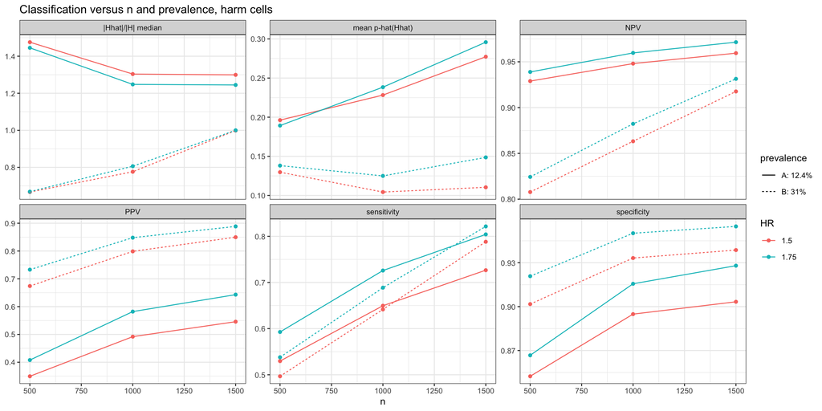

```r
if (!have(labs) || !length(harm_labs)) skip_note("the classification plot") else {
ID <- IDENT[IDENT$arm == "harm", ]
if (!have(ID)) skip_note("the classification plot") else {
IP <- do.call(rbind, lapply(list(
  c("sensitivity","sens"), c("specificity","spec"), c("PPV","ppv"), c("NPV","npv"),
  c("|Hhat|/|H| median","Hhat_over_H_med"), c("mean p-hat(Hhat)","p_hat_mean")),
  function(x) data.frame(n = ID$n, HR = factor(ID$HR), blk = ID$block, what = x[1], v = ID[[x[2]]])))
IP$blk <- factor(IP$blk, levels = c("A","B"), labels = c("A: 12.4%","B: 31%"))
ggplot(IP, aes(n, v, colour = HR, linetype = blk, group = interaction(HR, blk))) +
  geom_point() + geom_line() + facet_wrap(~ what, scales = "free_y", nrow = 2) +
  labs(x = "n", y = NULL, linetype = "prevalence",
       title = "Classification versus n and prevalence, harm cells") + theme_bw(base_size = 10)
}
}
```

# 6 The proposed family

Size distribution per cell, and whether it stabilizes with n — the mechanism Supplementary S8.3 offers for conditional coverage recovering with n.

```r
if (!have(labs)) skip_note("the family-size table") else {
FAM <- do.call(rbind, lapply(labs, function(k) {
  r <- B[[k]]$results; K <- r$n_family[is.finite(r$n_family)]
  q <- stats::quantile(K, c(0, .1, .25, .5, .75, .9, 1), names = FALSE)
  data.frame(cell = k, block = BLK[[k]], n = NN[[k]], HR = HR[[k]], arm = ARM[[k]], reps = length(K),
             K_min = q[1], K_q10 = q[2], K_q25 = q[3], K_med = q[4], K_q75 = q[5],
             K_q90 = q[6], K_max = q[7], K_mean = mean(K), K_sd = stats::sd(K),
             K_cv = stats::sd(K) / mean(K), K_iqr_over_med = (q[5] - q[3]) / q[4]) }))
FAM <- FAM[order(FAM$arm, FAM$block, FAM$HR, FAM$n), ]
kbl(FAM, digits = 3, booktabs = TRUE, row.names = FALSE,
    caption = "The PROPOSED-FAMILY SIZE (n_family) distribution per cell: min, q10, q25, median, q75, q90, max, mean, SD, coefficient of variation, and the IQR relative to the median. K_cv and K_iqr_over_med are the stabilization read: a family whose relative spread shrinks with n is the S8.3 mechanism; one whose spread does not is not.") |>
  kable_styling(font_size = 9)
}
```

The PROPOSED-FAMILY SIZE (n_family) distribution per cell: min, q10, q25, median, q75, q90, max, mean, SD, coefficient of variation, and the IQR relative to the median. K_cv and K_iqr_over_med are the stabilization read: a family whose relative spread shrinks with n is the S8.3 mechanism; one whose spread does not is not.

| cell | block | n | HR | arm | reps | K_min | K_q10 | K_q25 | K_med | K_q75 | K_q90 | K_max | K_mean | K_sd | K_cv | K_iqr_over_med |
| --- | --- | --- | --- | --- | --- | --- | --- | --- | --- | --- | --- | --- | --- | --- | --- | --- |
| A: HR 1.50, n 500 | A | 500 | 1.50 | harm | 1750 | 1 | 18.0 | 76.25 | 253.5 | 589.75 | 1111.2 | 3229 | 437.071 | 524.887 | 1.201 | 2.026 |
| A: HR 1.50, n 1000 | A | 1000 | 1.50 | harm | 1677 | 1 | 14.0 | 50.00 | 156.0 | 349.00 | 628.0 | 2596 | 258.035 | 305.729 | 1.185 | 1.917 |
| A: HR 1.50, n 1500 | A | 1500 | 1.50 | harm | 1597 | 1 | 8.0 | 33.00 | 103.0 | 239.00 | 394.0 | 1954 | 166.482 | 190.082 | 1.142 | 2.000 |
| A: HR 1.75, n 500 | A | 500 | 1.75 | harm | 1816 | 1 | 28.0 | 106.00 | 332.0 | 702.00 | 1273.5 | 3246 | 516.394 | 570.480 | 1.105 | 1.795 |
| A: HR 1.75, n 1000 | A | 1000 | 1.75 | harm | 1813 | 1 | 26.0 | 82.00 | 232.0 | 452.00 | 807.2 | 2721 | 336.753 | 356.543 | 1.059 | 1.595 |
| A: HR 1.75, n 1500 | A | 1500 | 1.75 | harm | 1796 | 1 | 18.0 | 61.75 | 177.0 | 330.00 | 526.0 | 2315 | 236.622 | 236.851 | 1.001 | 1.516 |
| B: HR 1.50, n 500 | B | 500 | 1.50 | harm | 1997 | 3 | 407.6 | 858.00 | 1495.0 | 2341.00 | 2880.8 | 3556 | 1597.258 | 900.429 | 0.564 | 0.992 |
| B: HR 1.50, n 1000 | B | 1000 | 1.50 | harm | 2000 | 48 | 662.8 | 1113.75 | 1709.5 | 2464.25 | 2984.3 | 3814 | 1784.682 | 844.589 | 0.473 | 0.790 |
| B: HR 1.50, n 1500 | B | 1500 | 1.50 | harm | 2000 | 55 | 760.7 | 1191.00 | 1743.5 | 2375.00 | 2850.3 | 3794 | 1782.546 | 772.647 | 0.433 | 0.679 |
| B: HR 1.75, n 500 | B | 500 | 1.75 | harm | 2000 | 37 | 667.0 | 1226.00 | 1954.5 | 2589.00 | 2982.2 | 3557 | 1890.439 | 848.429 | 0.449 | 0.697 |
| B: HR 1.75, n 1000 | B | 1000 | 1.75 | harm | 2000 | 241 | 1185.8 | 1660.75 | 2257.5 | 2817.25 | 3160.0 | 3821 | 2211.533 | 745.448 | 0.337 | 0.512 |
| B: HR 1.75, n 1500 | B | 1500 | 1.75 | harm | 2000 | 384 | 1341.9 | 1775.75 | 2355.5 | 2812.00 | 3108.0 | 3726 | 2276.633 | 673.402 | 0.296 | 0.440 |
| A: HR 1.00, n 500 | A | 500 | 1.00 | null | 1427 | 1 | 13.0 | 40.00 | 137.0 | 372.00 | 745.6 | 3224 | 292.771 | 416.286 | 1.422 | 2.423 |
| A: HR 1.00, n 1000 | A | 1000 | 1.00 | null | 1049 | 1 | 5.8 | 24.00 | 66.0 | 178.00 | 355.4 | 1611 | 140.819 | 200.289 | 1.422 | 2.333 |
| A: HR 1.00, n 1500 | A | 1500 | 1.00 | null | 687 | 1 | 2.0 | 12.00 | 36.0 | 104.50 | 211.2 | 1186 | 80.527 | 117.396 | 1.458 | 2.569 |
| B: HR 1.00, n 500 | B | 500 | 1.00 | null | 1860 | 1 | 42.0 | 175.00 | 485.5 | 1130.00 | 1965.4 | 3476 | 766.597 | 772.826 | 1.008 | 1.967 |
| B: HR 1.00, n 1000 | B | 1000 | 1.00 | null | 1852 | 1 | 37.1 | 136.00 | 349.0 | 743.75 | 1347.8 | 3739 | 553.530 | 599.559 | 1.083 | 1.741 |
| B: HR 1.00, n 1500 | B | 1500 | 1.00 | null | 1776 | 1 | 29.0 | 107.00 | 278.5 | 508.00 | 895.5 | 3364 | 392.918 | 423.503 | 1.078 | 1.440 |

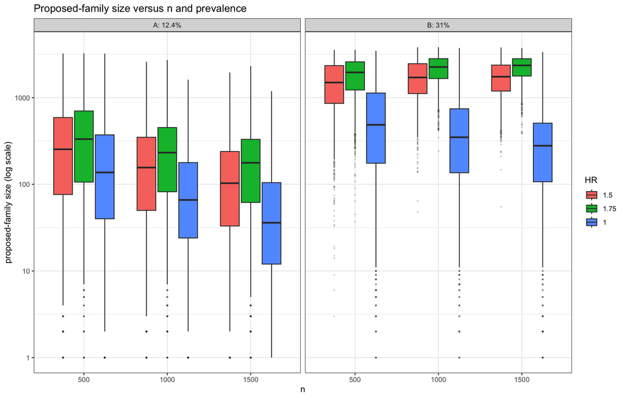

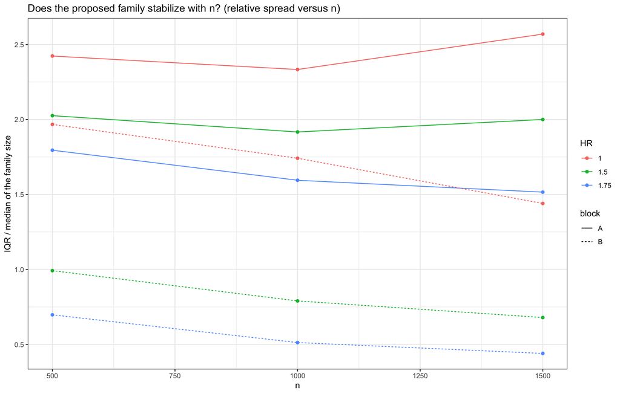

```r
if (!have(labs)) skip_note("the family-size plots") else {
FK <- do.call(rbind, lapply(labs, function(k) {
  r <- B[[k]]$results
  data.frame(cell = k, block = BLK[[k]], n = factor(NN[[k]]), HR = factor(HR[[k]]),
             arm = ARM[[k]], K = r$n_family[is.finite(r$n_family)]) }))
FK$blk <- factor(FK$block, levels = c("A","B"), labels = c("A: 12.4%","B: 31%"))
print(ggplot(FK, aes(n, K, fill = HR)) + geom_boxplot(outlier.alpha = 0.15, outlier.size = 0.5) +
  scale_y_log10() + facet_wrap(~ blk) +
  labs(x = "n", y = "proposed-family size (log scale)",
       title = "Proposed-family size versus n and prevalence") + theme_bw(base_size = 11))
print(ggplot(FAM, aes(n, K_iqr_over_med, colour = factor(HR), group = interaction(HR, block),
                      linetype = block)) +
  geom_point() + geom_line() +
  labs(x = "n", y = "IQR / median of the family size", colour = "HR", linetype = "block",
       title = "Does the proposed family stabilize with n? (relative spread versus n)") +
  theme_bw(base_size = 11))
}
```

# 7 Beside the FS grid, with the confound stated

> **The confound, and it is not the same in the two blocks.**

> FS and DINA always differ in **the identifier** *and* in **how the family is constructed**, and each conditions on **a different detection set**. FS’s family is the consistency-screened candidate table, fixed for a given fit; DINA’s is a qualifying candidate table read off a cross-fit surface that a bootstrap would regenerate. FS’s coverage is of its own estimand; DINA’s is of the conditional-on-proposed-family estimand.

> Every FS number in this document therefore carries its own `campaign / sg_focus / eps`. A row-by-row gap is **not** attributable to any one difference alone. What follows is **descriptive, not a contest**, and the FS numbers are reference lines, not a bar.

```r
FSC <- list(
  # 31% -- cert20 (n 1000/1500) and e1stud (n 500), read as they stand
  list(lab="FS B: HR 1.50, n 500",  blk="B", n=500L,  hr=1.50, f="fs_effMaxSG_fb_mr_field_m1_h150_knoise0_n500_z1q60_nb20_e1stud_combined_1_2000.rds"),
  list(lab="FS B: HR 1.50, n 1000", blk="B", n=1000L, hr=1.50, f="fs_effMaxSG_fb_mr_field_m1_h150_knoise0_n1000_z1q60_nb20_cert20_combined_1_2000.rds"),
  list(lab="FS B: HR 1.50, n 1500", blk="B", n=1500L, hr=1.50, f="fs_effMaxSG_fb_mr_field_m1_h150_knoise0_n1500_z1q60_nb20_cert20_combined_1_2000.rds"),
  list(lab="FS B: HR 1.75, n 500",  blk="B", n=500L,  hr=1.75, f="fs_effMaxSG_fb_mr_field_m1_h175_knoise0_n500_z1q60_nb20_e1stud_combined_1_2000.rds"),
  list(lab="FS B: HR 1.75, n 1000", blk="B", n=1000L, hr=1.75, f="fs_effMaxSG_fb_mr_field_m1_h175_knoise0_n1000_z1q60_nb20_cert20_combined_1_2000.rds"),
  list(lab="FS B: HR 1.75, n 1500", blk="B", n=1500L, hr=1.75, f="fs_effMaxSG_fb_mr_field_m1_h175_knoise0_n1500_z1q60_nb20_cert20_combined_1_2000.rds"),
  # 12.4% -- tier2 (n 500 HR 1.75, n 1000/1500 HR 1.75) and p12ext
  list(lab="FS A: HR 1.50, n 500",  blk="A", n=500L,  hr=1.50, f="fs_maxeffCons_fb_mr_field_m1_h150_knoise0_n500_p12ext_combined_1_2000.rds"),
  list(lab="FS A: HR 1.50, n 1000", blk="A", n=1000L, hr=1.50, f="fs_maxeffCons_fb_mr_field_m1_h150_knoise0_n1000_p12ext_combined_1_2000.rds"),
  list(lab="FS A: HR 1.50, n 1500", blk="A", n=1500L, hr=1.50, f="fs_maxeffCons_fb_mr_field_m1_h150_knoise0_n1500_p12ext_combined_1_2000.rds"),
  list(lab="FS A: HR 1.75, n 500",  blk="A", n=500L,  hr=1.75, f="fs_maxeffCons_fb_mr_field_m1_h175_knoise0_n500_tier2_combined_1_2000.rds"),
  list(lab="FS A: HR 1.75, n 1000", blk="A", n=1000L, hr=1.75, f="fs_maxeffCons_fb_mr_field_m1_h175_knoise0_n1000_tier2_combined_1_2000.rds"),
  list(lab="FS A: HR 1.75, n 1500", blk="A", n=1500L, hr=1.75, f="fs_maxeffCons_fb_mr_field_m1_h175_knoise0_n1500_tier2_combined_1_2000.rds"))
FSC <- Filter(function(x) file.exists(paste0(R, x$f)), FSC)
if (!length(FSC)) skip_note("the FS comparator grid (no committed FS bundle on disk)") else {
FSG <- do.call(rbind, lapply(FSC, function(x) {
  b <- readRDS(paste0(R, x$f)); r <- b$results
  d <- r[r$detected %in% 1L & is.finite(r$betaHhat_H) & is.finite(r$betaHhat_Hc) &
         is.finite(r$fld_H_lo1s) & is.finite(r$fld_Hc_up1s_s), , drop = FALSE]
  data.frame(cell = x$lab, engine = "FS (consistency)", block = x$blk, n = x$n, HR = x$hr,
             criterion = sprintf("%s / %s / eps %s", b$meta$campaign_tag %||% NA,
                                 b$meta$sg_focus %||% NA, format(b$meta$effect_neighborhood %||% NA)),
             campaign = b$meta$campaign_tag %||% NA, focus = b$meta$sg_focus %||% NA,
             eps = b$meta$effect_neighborhood %||% NA_real_,
             detection = mean(r$detected %in% 1L), n_eval = nrow(d),
             K_med = stats::median(r$n_family, na.rm = TRUE),
             harm_field = mean(d$betaHhat_H >= d$fld_H_lo1s),
             comp_field_s = mean(d$betaHhat_Hc <= d$fld_Hc_up1s_s),
             ij2_H = mean(d$betaHhat_H >= d$mr_H_lo & d$betaHhat_H <= d$mr_H_hi),
             ij2_Hc = mean(d$betaHhat_Hc >= d$mr_Hc_lo & d$betaHhat_Hc <= d$mr_Hc_hi),
             sens = mean(d$sens), ppv = mean(d$ppv)) }))
DNG <- if (have(VSN)) do.call(rbind, lapply(which(VSN$arm == "harm"), function(i) {
  k <- VSN$cell[i]; d <- B[[k]]$results
  dd <- d[d$detected %in% 1L, , drop = FALSE]
  data.frame(cell = k, engine = "DINA (dinamr)", block = VSN$block[i], n = VSN$n[i], HR = VSN$HR[i],
             criterion = "dinamr / effMaxSG / eps 0.2",
             campaign = "dinamr", focus = "effMaxSG", eps = 0.20,
             detection = mean(d$detected %in% 1L), n_eval = VSN$n_eval[i],
             K_med = stats::median(d$n_family, na.rm = TRUE),
             harm_field = VSN$harm_field[i], comp_field_s = VSN$comp_field_s[i],
             ij2_H = VSN$ij2_H[i], ij2_Hc = VSN$ij2_Hc[i],
             sens = mean(dd$sens), ppv = mean(dd$ppv)) })) else NULL
SIDE <- rbind(FSG, DNG)
SIDE <- SIDE[order(SIDE$block, SIDE$HR, SIDE$n, SIDE$engine), ]
kbl(SIDE, digits = 4, booktabs = TRUE, row.names = FALSE,
    caption = "DINA beside the committed FS grid (cert20 / tier2 / p12ext read AS THEY STAND, not re-run), matched on prevalence block, HR and n. DIFFERENT IDENTIFIER AND DIFFERENT FAMILY CONSTRUCTION, each conditioning on a different detection set -- AND, at 12.4% ONLY, a DIFFERENT CRITERION: the `criterion` column carries each row's campaign / sg_focus / eps, which is effMaxSG / eps 0.20 on both engines in Block B but maxeffCons / eps 0.10 for FS in Block A. See the confound above. DINA's coverage columns are the conditional-on-proposed-family estimand; FS's are its own. Descriptive, not a contest; no criterion is applied.") |>
  kable_styling(font_size = 9)
}
```

DINA beside the committed FS grid (cert20 / tier2 / p12ext read AS THEY STAND, not re-run), matched on prevalence block, HR and n. DIFFERENT IDENTIFIER AND DIFFERENT FAMILY CONSTRUCTION, each conditioning on a different detection set -- AND, at 12.4% ONLY, a DIFFERENT CRITERION: the `criterion` column carries each row's campaign / sg_focus / eps, which is effMaxSG / eps 0.20 on both engines in Block B but maxeffCons / eps 0.10 for FS in Block A. See the confound above. DINA's coverage columns are the conditional-on-proposed-family estimand; FS's are its own. Descriptive, not a contest; no criterion is applied.

| cell | engine | block | n | HR | criterion | campaign | focus | eps | detection | n_eval | K_med | harm_field | comp_field_s | ij2_H | ij2_Hc | sens | ppv |
| --- | --- | --- | --- | --- | --- | --- | --- | --- | --- | --- | --- | --- | --- | --- | --- | --- | --- |
| A: HR 1.50, n 500 | DINA (dinamr) | A | 500 | 1.50 | dinamr / effMaxSG / eps 0.2 | dinamr | effMaxSG | 0.2 | 0.8750 | 1750 | 253.5 | 0.9017 | 0.9223 | 0.9949 | 1.0000 | 0.5296 | 0.3494 |
| FS A: HR 1.50, n 500 | FS (consistency) | A | 500 | 1.50 | p12ext / maxeffCons / eps 0.1 | p12ext | maxeffCons | 0.1 | 0.9110 | 1822 | 1223.0 | 0.9654 | 0.9374 | 0.9769 | 1.0000 | 0.5732 | 0.5082 |
| A: HR 1.50, n 1000 | DINA (dinamr) | A | 1000 | 1.50 | dinamr / effMaxSG / eps 0.2 | dinamr | effMaxSG | 0.2 | 0.8385 | 1677 | 156.0 | 0.9153 | 0.9422 | 0.9887 | 0.9994 | 0.6496 | 0.4919 |
| FS A: HR 1.50, n 1000 | FS (consistency) | A | 1000 | 1.50 | p12ext / maxeffCons / eps 0.1 | p12ext | maxeffCons | 0.1 | 0.9740 | 1948 | 1299.0 | 0.9410 | 0.9533 | 0.9322 | 0.9995 | 0.6975 | 0.7059 |
| A: HR 1.50, n 1500 | DINA (dinamr) | A | 1500 | 1.50 | dinamr / effMaxSG / eps 0.2 | dinamr | effMaxSG | 0.2 | 0.7985 | 1597 | 103.0 | 0.9286 | 0.9461 | 0.9925 | 1.0000 | 0.7266 | 0.5458 |
| FS A: HR 1.50, n 1500 | FS (consistency) | A | 1500 | 1.50 | p12ext / maxeffCons / eps 0.1 | p12ext | maxeffCons | 0.1 | 0.9880 | 1976 | 1297.0 | 0.9565 | 0.9585 | 0.9008 | 0.9990 | 0.8198 | 0.8200 |
| A: HR 1.75, n 500 | DINA (dinamr) | A | 500 | 1.75 | dinamr / effMaxSG / eps 0.2 | dinamr | effMaxSG | 0.2 | 0.9080 | 1816 | 332.0 | 0.9108 | 0.9213 | 0.9950 | 1.0000 | 0.5927 | 0.4078 |
| FS A: HR 1.75, n 500 | FS (consistency) | A | 500 | 1.75 | tier2 / maxeffCons / eps 0.1 | tier2 | maxeffCons | 0.1 | 0.9500 | 1900 | 1223.0 | 0.9663 | 0.9405 | 0.9611 | 1.0000 | 0.6594 | 0.5902 |
| A: HR 1.75, n 1000 | DINA (dinamr) | A | 1000 | 1.75 | dinamr / effMaxSG / eps 0.2 | dinamr | effMaxSG | 0.2 | 0.9065 | 1813 | 232.0 | 0.9272 | 0.9388 | 0.9912 | 0.9994 | 0.7259 | 0.5821 |
| FS A: HR 1.75, n 1000 | FS (consistency) | A | 1000 | 1.75 | tier2 / maxeffCons / eps 0.1 | tier2 | maxeffCons | 0.1 | 0.9950 | 1990 | 1299.0 | 0.9437 | 0.9563 | 0.9166 | 0.9995 | 0.7867 | 0.7943 |
| A: HR 1.75, n 1500 | DINA (dinamr) | A | 1500 | 1.75 | dinamr / effMaxSG / eps 0.2 | dinamr | effMaxSG | 0.2 | 0.8980 | 1796 | 177.0 | 0.9443 | 0.9488 | 0.9911 | 1.0000 | 0.8042 | 0.6431 |
| FS A: HR 1.75, n 1500 | FS (consistency) | A | 1500 | 1.75 | tier2 / maxeffCons / eps 0.1 | tier2 | maxeffCons | 0.1 | 0.9990 | 1998 | 1297.0 | 0.9600 | 0.9605 | 0.9129 | 0.9995 | 0.8829 | 0.8767 |
| B: HR 1.50, n 500 | DINA (dinamr) | B | 500 | 1.50 | dinamr / effMaxSG / eps 0.2 | dinamr | effMaxSG | 0.2 | 0.9985 | 1997 | 1495.0 | 0.9159 | 0.9099 | 0.9905 | 1.0000 | 0.4967 | 0.6741 |
| FS B: HR 1.50, n 500 | FS (consistency) | B | 500 | 1.50 | e1stud / effMaxSG / eps 0.2 | e1stud | effMaxSG | 0.2 | 0.9995 | 1999 | 1223.0 | 0.9745 | 0.9125 | 0.9810 | 1.0000 | 0.5903 | 0.7063 |
| B: HR 1.50, n 1000 | DINA (dinamr) | B | 1000 | 1.50 | dinamr / effMaxSG / eps 0.2 | dinamr | effMaxSG | 0.2 | 1.0000 | 2000 | 1709.5 | 0.9515 | 0.9365 | 0.9865 | 1.0000 | 0.6416 | 0.7988 |
| FS B: HR 1.50, n 1000 | FS (consistency) | B | 1000 | 1.50 | cert20 / effMaxSG / eps 0.2 | cert20 | effMaxSG | 0.2 | 1.0000 | 2000 | 1299.0 | 0.9585 | 0.9420 | 0.9710 | 1.0000 | 0.7078 | 0.8040 |
| B: HR 1.50, n 1500 | DINA (dinamr) | B | 1500 | 1.50 | dinamr / effMaxSG / eps 0.2 | dinamr | effMaxSG | 0.2 | 1.0000 | 2000 | 1743.5 | 0.9610 | 0.9420 | 0.9840 | 1.0000 | 0.7882 | 0.8498 |
| FS B: HR 1.50, n 1500 | FS (consistency) | B | 1500 | 1.50 | cert20 / effMaxSG / eps 0.2 | cert20 | effMaxSG | 0.2 | 1.0000 | 2000 | 1297.0 | 0.9615 | 0.9465 | 0.9755 | 0.9995 | 0.8391 | 0.8374 |
| B: HR 1.75, n 500 | DINA (dinamr) | B | 500 | 1.75 | dinamr / effMaxSG / eps 0.2 | dinamr | effMaxSG | 0.2 | 1.0000 | 2000 | 1954.5 | 0.9155 | 0.9195 | 0.9870 | 0.9995 | 0.5379 | 0.7330 |
| FS B: HR 1.75, n 500 | FS (consistency) | B | 500 | 1.75 | e1stud / effMaxSG / eps 0.2 | e1stud | effMaxSG | 0.2 | 0.9995 | 1999 | 1223.0 | 0.9700 | 0.9195 | 0.9720 | 0.9995 | 0.6603 | 0.7785 |
| B: HR 1.75, n 1000 | DINA (dinamr) | B | 1000 | 1.75 | dinamr / effMaxSG / eps 0.2 | dinamr | effMaxSG | 0.2 | 1.0000 | 2000 | 2257.5 | 0.9505 | 0.9435 | 0.9770 | 1.0000 | 0.6887 | 0.8480 |
| FS B: HR 1.75, n 1000 | FS (consistency) | B | 1000 | 1.75 | cert20 / effMaxSG / eps 0.2 | cert20 | effMaxSG | 0.2 | 1.0000 | 2000 | 1299.0 | 0.9525 | 0.9420 | 0.9740 | 1.0000 | 0.7689 | 0.8600 |
| B: HR 1.75, n 1500 | DINA (dinamr) | B | 1500 | 1.75 | dinamr / effMaxSG / eps 0.2 | dinamr | effMaxSG | 0.2 | 1.0000 | 2000 | 2355.5 | 0.9610 | 0.9440 | 0.9800 | 0.9995 | 0.8215 | 0.8886 |
| FS B: HR 1.75, n 1500 | FS (consistency) | B | 1500 | 1.75 | cert20 / effMaxSG / eps 0.2 | cert20 | effMaxSG | 0.2 | 1.0000 | 2000 | 1297.0 | 0.9610 | 0.9460 | 0.9805 | 0.9995 | 0.8740 | 0.8827 |

# 8 p-hat and the recovery diagnostics on a model-generated family

```r
recov_cols <- c("fld_recov_sens_H","fld_recov_ppv_H","fld_recov_sens_Hc","fld_recov_npv_Hc",
                "fld_recov_q10","fld_recov_q50","fld_recov_q90","fld_recov_share1","fld_recov_n_used")
if (!have(labs)) skip_note("the recovery diagnostics") else {
RCV <- do.call(rbind, lapply(labs, function(k) {
  r <- B[[k]]$results; d <- r[r$detected %in% 1L, , drop = FALSE]
  if (!nrow(d) || !all(recov_cols %in% names(d))) return(NULL)
  qq <- function(x) stats::quantile(x[is.finite(x)], c(.1,.5,.9), names = FALSE)
  ph <- d$p_hat_H[is.finite(d$p_hat_H)]
  data.frame(cell = k, block = BLK[[k]], n = NN[[k]], HR = HR[[k]], arm = ARM[[k]], n_det = nrow(d),
             p_hat_q10 = qq(ph)[1], p_hat_med = qq(ph)[2], p_hat_q90 = qq(ph)[3], p_hat_mean = mean(ph),
             rho_c_med = stats::median(d$fld_Hc_scale_ratio),
             scale_cv_med = stats::median(d$fld_Hc_scale_cv),
             sens_H = mean(d$fld_recov_sens_H), ppv_H = mean(d$fld_recov_ppv_H),
             sens_Hc = mean(d$fld_recov_sens_Hc), npv_Hc = mean(d$fld_recov_npv_Hc),
             cont_q10 = mean(d$fld_recov_q10), cont_q50 = mean(d$fld_recov_q50),
             cont_q90 = mean(d$fld_recov_q90), share1 = mean(d$fld_recov_share1),
             n_used = mean(d$fld_recov_n_used)) }))
RCV <- RCV[order(RCV$arm, RCV$block, RCV$HR, RCV$n), ]
kbl(RCV, digits = 4, booktabs = TRUE, row.names = FALSE,
    caption = "p-hat and the recovery diagnostics on DINA's MODEL-GENERATED family: the p-hat(Hhat) distribution (q10 / median / q90 / mean); rho-c = the complement scale ratio and the within-replicate scale CV; and the nine recovery columns -- sens_H / ppv_H / sens_Hc / npv_Hc and the containment quantiles q10 / q50 / q90 with the share at exactly 1 and the evaluation count. Described, not interpreted beyond the record.") |>
  kable_styling(font_size = 8)
}
```

p-hat and the recovery diagnostics on DINA's MODEL-GENERATED family: the p-hat(Hhat) distribution (q10 / median / q90 / mean); rho-c = the complement scale ratio and the within-replicate scale CV; and the nine recovery columns -- sens_H / ppv_H / sens_Hc / npv_Hc and the containment quantiles q10 / q50 / q90 with the share at exactly 1 and the evaluation count. Described, not interpreted beyond the record.

| cell | block | n | HR | arm | n_det | p_hat_q10 | p_hat_med | p_hat_q90 | p_hat_mean | rho_c_med | scale_cv_med | sens_H | ppv_H | sens_Hc | npv_Hc | cont_q10 | cont_q50 | cont_q90 | share1 | n_used |
| --- | --- | --- | --- | --- | --- | --- | --- | --- | --- | --- | --- | --- | --- | --- | --- | --- | --- | --- | --- | --- |
| A: HR 1.50, n 500 | A | 500 | 1.50 | harm | 1750 | 0.0354 | 0.1340 | 0.4476 | 0.1963 | 1.0073 | 0.0358 | 0.5697 | 0.6131 | 0.9115 | 0.8939 | 0.2852 | 0.5612 | 0.8738 | 0.1027 | 974.0777 |
| A: HR 1.50, n 1000 | A | 1000 | 1.50 | harm | 1677 | 0.0478 | 0.1638 | 0.5275 | 0.2283 | 1.0079 | 0.0306 | 0.6238 | 0.6639 | 0.9313 | 0.9192 | 0.3495 | 0.6245 | 0.8957 | 0.1375 | 972.2701 |
| A: HR 1.50, n 1500 | A | 1500 | 1.50 | harm | 1597 | 0.0605 | 0.2132 | 0.6087 | 0.2772 | 1.0066 | 0.0276 | 0.6882 | 0.7257 | 0.9415 | 0.9305 | 0.4384 | 0.6976 | 0.9287 | 0.1920 | 965.6537 |
| A: HR 1.75, n 500 | A | 500 | 1.75 | harm | 1816 | 0.0386 | 0.1378 | 0.4186 | 0.1893 | 1.0080 | 0.0356 | 0.5678 | 0.6022 | 0.9103 | 0.8963 | 0.2794 | 0.5598 | 0.8738 | 0.0967 | 983.8018 |
| A: HR 1.75, n 1000 | A | 1000 | 1.75 | harm | 1813 | 0.0524 | 0.1840 | 0.5101 | 0.2384 | 1.0061 | 0.0300 | 0.6401 | 0.6638 | 0.9329 | 0.9266 | 0.3620 | 0.6484 | 0.9068 | 0.1493 | 986.7512 |
| A: HR 1.75, n 1500 | A | 1500 | 1.75 | harm | 1796 | 0.0698 | 0.2453 | 0.5916 | 0.2958 | 1.0043 | 0.0265 | 0.7140 | 0.7291 | 0.9440 | 0.9412 | 0.4633 | 0.7328 | 0.9397 | 0.2113 | 984.1136 |
| B: HR 1.50, n 500 | B | 500 | 1.50 | harm | 1997 | 0.0249 | 0.0916 | 0.2853 | 0.1298 | 1.0137 | 0.0452 | 0.4967 | 0.5591 | 0.8919 | 0.8609 | 0.2016 | 0.4777 | 0.8250 | 0.0561 | 999.7201 |
| B: HR 1.50, n 1000 | B | 1000 | 1.50 | harm | 2000 | 0.0226 | 0.0745 | 0.2229 | 0.1044 | 1.0404 | 0.0510 | 0.5122 | 0.6285 | 0.9095 | 0.8529 | 0.2229 | 0.4972 | 0.8280 | 0.0443 | 1000.0000 |
| B: HR 1.50, n 1500 | B | 1500 | 1.50 | harm | 2000 | 0.0238 | 0.0848 | 0.2278 | 0.1104 | 1.0631 | 0.0574 | 0.5782 | 0.7284 | 0.9225 | 0.8487 | 0.2904 | 0.5809 | 0.8619 | 0.0472 | 1000.0000 |
| B: HR 1.75, n 500 | B | 500 | 1.75 | harm | 2000 | 0.0310 | 0.0972 | 0.3054 | 0.1381 | 1.0191 | 0.0462 | 0.5100 | 0.5739 | 0.8963 | 0.8653 | 0.2112 | 0.4970 | 0.8326 | 0.0599 | 999.9915 |
| B: HR 1.75, n 1000 | B | 1000 | 1.75 | harm | 2000 | 0.0290 | 0.0953 | 0.2618 | 0.1250 | 1.0489 | 0.0525 | 0.5393 | 0.6658 | 0.9192 | 0.8599 | 0.2431 | 0.5347 | 0.8431 | 0.0490 | 1000.0000 |
| B: HR 1.75, n 1500 | B | 1500 | 1.75 | harm | 2000 | 0.0362 | 0.1199 | 0.2940 | 0.1486 | 1.0650 | 0.0568 | 0.6174 | 0.7725 | 0.9361 | 0.8640 | 0.3262 | 0.6324 | 0.8846 | 0.0633 | 1000.0000 |
| A: HR 1.00, n 500 | A | 500 | 1.00 | null | 1427 | 0.0393 | 0.1450 | 0.4688 | 0.2064 | 1.0066 | 0.0335 | 0.5853 | 0.6338 | 0.9156 | 0.8960 | 0.3093 | 0.5749 | 0.8808 | 0.1124 | 951.2362 |
| A: HR 1.00, n 1000 | A | 1000 | 1.00 | null | 1049 | 0.0428 | 0.1752 | 0.5882 | 0.2494 | 1.0062 | 0.0256 | 0.6391 | 0.6942 | 0.9388 | 0.9192 | 0.3800 | 0.6312 | 0.9038 | 0.1630 | 917.9371 |
| A: HR 1.00, n 1500 | A | 1500 | 1.00 | null | 687 | 0.0486 | 0.2382 | 0.7006 | 0.3076 | 1.0047 | 0.0191 | 0.7164 | 0.7618 | 0.9526 | 0.9370 | 0.4955 | 0.7264 | 0.9274 | 0.2493 | 876.6346 |
| B: HR 1.00, n 500 | B | 500 | 1.00 | null | 1860 | 0.0266 | 0.1017 | 0.3538 | 0.1554 | 1.0062 | 0.0420 | 0.5184 | 0.5716 | 0.8948 | 0.8688 | 0.2285 | 0.5008 | 0.8424 | 0.0751 | 984.5274 |
| B: HR 1.00, n 1000 | B | 1000 | 1.00 | null | 1852 | 0.0214 | 0.0788 | 0.3146 | 0.1314 | 1.0186 | 0.0454 | 0.5206 | 0.6173 | 0.9075 | 0.8607 | 0.2354 | 0.5036 | 0.8360 | 0.0674 | 986.2300 |
| B: HR 1.00, n 1500 | B | 1500 | 1.00 | null | 1776 | 0.0187 | 0.0798 | 0.3248 | 0.1342 | 1.0300 | 0.0509 | 0.5658 | 0.6889 | 0.9136 | 0.8503 | 0.2906 | 0.5549 | 0.8610 | 0.0734 | 982.8159 |

## 8.1 Does the low-p̂ / high-p̂ bias structure found for FS appear on DINA?

```r
prep <- function(r) {
  need <- c("betaHhat_H","betaHhat_Hc","fld_H_est2","fld_H_lo1s","fld_H_se",
            "fld_Hc_est2","fld_Hc_est2_s","fld_Hc_up1s","fld_Hc_up1s_s","fld_Hc_se_s",
            "fld_Hc_scale_ratio","p_hat_H","mr_H_est","mr_Hc_est","n_harm","n_true")
  need <- need[need %in% names(r)]
  d <- r[r$detected %in% 1L, , drop = FALSE]
  d <- d[Reduce(`&`, lapply(need, function(cn) is.finite(d[[cn]]))), , drop = FALSE]
  if (!nrow(d)) return(d)
  d$ef_H <- log(d$fld_H_est2)    - log(d$betaHhat_H)
  d$ef_s <- log(d$fld_Hc_est2_s) - log(d$betaHhat_Hc)
  d$ratio_H <- d$n_harm / d$n_true
  d }
strat_row <- function(d, cell, stratum) {
  bH <- mean(d$ef_H)/stats::sd(d$ef_H); rH <- mean(d$fld_H_se)/stats::sd(d$ef_H)
  bC <- mean(d$ef_s)/stats::sd(d$ef_s); rC <- mean(d$fld_Hc_se_s)/stats::sd(d$ef_s)
  cfH <- mean(d$betaHhat_H  >= d$fld_H_lo1s);    wH <- wil(cfH, nrow(d))
  cfC <- mean(d$betaHhat_Hc <= d$fld_Hc_up1s_s); wC <- wil(cfC, nrow(d))
  cfCu <- mean(d$betaHhat_Hc <= d$fld_Hc_up1s)   # unscaled field, beside field-s (cert20 parity)
  data.frame(cell = cell, stratum = stratum, n = nrow(d), p_hat_mean = mean(d$p_hat_H),
             Hhat_over_H = mean(d$ratio_H), rho_c = mean(d$fld_Hc_scale_ratio),
             mean_ef_H = mean(d$ef_H), SD_ef_H = stats::sd(d$ef_H), b_H = bH, r_H = rH,
             cov_field_H = cfH, wH_lo = wH[1], wH_hi = wH[2],
             gauss_H = stats::pnorm(z95 * rH - bH),
             mean_ef_s = mean(d$ef_s), SD_ef_s = stats::sd(d$ef_s), b_C = bC, r_C = rC,
             cov_field_C = cfCu, cov_field_s_C = cfC, wC_lo = wC[1], wC_hi = wC[2],
             gauss_C = stats::pnorm(z95 * rC + bC)) }
TERT <- if (length(labs)) do.call(rbind, lapply(labs, function(k) {
  d <- prep(B[[k]]$results); if (nrow(d) < 30L) return(NULL)
  br <- stats::quantile(d$p_hat_H, c(0, 1/3, 2/3, 1), names = FALSE)
  if (length(unique(br)) < 3L) return(strat_row(d, k, "all (p-hat not splittable)"))
  g <- cut(d$p_hat_H, breaks = unique(br), include.lowest = TRUE, labels = FALSE)
  rbind(strat_row(d, k, "all"),
        do.call(rbind, lapply(sort(unique(g)), function(t) {
          dk <- d[g == t, , drop = FALSE]
          strat_row(dk, k, sprintf("p-hat T%d [%.3f, %.3f]", t, min(dk$p_hat_H), max(dk$p_hat_H))) }))) })) else NULL
if (!have(TERT)) skip_note("the p-hat tertile tables (no cell with >= 30 usable replicates)") else {
print(kbl(TERT[, c("cell","stratum","n","p_hat_mean","Hhat_over_H","mean_ef_H","SD_ef_H",
                   "b_H","r_H","cov_field_H","wH_lo","wH_hi","gauss_H")],
    digits = 4, booktabs = TRUE, row.names = FALSE,
    caption = "Harm block by p-hat(Hhat) tertile within each cell: the field's residual error ef_H = log(fld_H_est2) - log(beta(Hhat)), its ERROR SD, b and r, the observed one-sided lower coverage with Wilson limits, and the Gaussian-implied coverage from the stratum's own numbers. gauss_H = Phi(1.645 * r_H - b_H) with r_H = mean(fld_H_se)/SD(ef_H) and b_H = mean(ef_H)/SD(ef_H): these are ALREADY built on the ERROR SD, not the marginal SD. Conditional-on-proposed-family estimand.") |>
  kable_styling(font_size = 8))
print(kbl(TERT[, c("cell","stratum","n","p_hat_mean","rho_c","mean_ef_s","SD_ef_s",
                   "b_C","r_C","cov_field_C","cov_field_s_C","wC_lo","wC_hi","gauss_C")],
    digits = 4, booktabs = TRUE, row.names = FALSE,
    caption = "Complement block by p-hat tertile: ef_s = log(fld_Hc_est2_s) - log(beta(Hhat^c)), its error SD, b and r, the UNSCALED field's observed upper coverage (cov_field_C) beside field-s (cov_field_s_C, Wilson), and the Gaussian-implied field-s value. Conditional-on-proposed-family estimand.") |>
  kable_styling(font_size = 8))
}
```

[output not shown]

[output cut: 2221 more lines]

[output not shown]

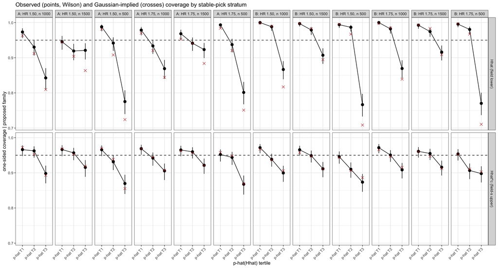

```r
if (!have(TERT) || !length(harm_labs)) skip_note("the tertile plot") else {
TT <- TERT[TERT$stratum != "all" & !grepl("not splittable", TERT$stratum) & TERT$cell %in% harm_labs, ]
if (!have(TT)) skip_note("the tertile plot") else {
TT$tertile <- sub(" \\[.*", "", TT$stratum)
TP <- rbind(data.frame(cell = TT$cell, tertile = TT$tertile, blk = "Hhat (field lower)",
                       cov = TT$cov_field_H,   lo = TT$wH_lo, hi = TT$wH_hi, implied = TT$gauss_H),
            data.frame(cell = TT$cell, tertile = TT$tertile, blk = "Hhat^c (field-s upper)",
                       cov = TT$cov_field_s_C, lo = TT$wC_lo, hi = TT$wC_hi, implied = TT$gauss_C))
ggplot(TP, aes(tertile, cov, group = 1)) + geom_hline(yintercept = 0.95, linetype = 2) +
  geom_pointrange(aes(ymin = lo, ymax = hi)) + geom_line() +
  geom_point(aes(y = implied), shape = 4, colour = "firebrick", size = 2) +
  facet_grid(blk ~ cell) +
  labs(x = "p-hat(Hhat) tertile", y = "one-sided coverage | proposed family",
       title = "Observed (points, Wilson) and Gaussian-implied (crosses) coverage by stable-pick stratum") +
  theme_bw(base_size = 9) + theme(axis.text.x = element_text(angle = 45, hjust = 1))
}
}
```

# 9 Stratified tables: by proposed-family size and by p̂

Everything in this section is **descriptive**. No acceptance criterion is applied, and every coverage figure is coverage of the **conditional-on-proposed-family** estimand on detected replicates.

**The two stratifications.**

- **Proposed-family size.** Within-cell empirical tertiles of `n_family`, plus **two extra rows that deliberately overlap them**: `K = 1` (the family is a single candidate, so the “family” imposes no choice at all) and `K <= 5`. Overlapping rows are marked; they are not a partition and must not be summed.
- **p̂(Ĥ).** The bins **the FS summaries use**, stated so the comparison is like-for-like: `summary_cert20.qmd` (§tert), `summary_tier2.qmd`, `summary_p12ext.qmd`, `summary_e1stud.qmd` (all as `tert()`) and `summary_complement_variance.qmd` (§A2/A5/A6 as `strat()`) every one use **within-cell empirical tertiles** — `quantile(v, c(0, 1/3, 2/3, 1))` cut with `include.lowest = TRUE` — **not fixed cut-points**. The same definition is used here.

**Retained bias** is the bias that survives the correction, on the log scale: `mean(log(est) - log(beta(Hhat)))` within the stratum, for each product.

```r
tert_fs <- function(v) {                     # the FS summaries' own binning, verbatim in form
  if (!any(is.finite(v))) return(rep(NA_integer_, length(v)))
  br <- stats::quantile(v, c(0, 1/3, 2/3, 1), na.rm = TRUE, names = FALSE)
  if (length(unique(br)) < 2L) return(rep(1L, length(v)))
  cut(v, breaks = unique(br), include.lowest = TRUE, labels = FALSE) }
det_rows <- function(k) { r <- B[[k]]$results
  d <- r[r$detected %in% 1L, , drop = FALSE]
  keep <- is.finite(d$betaHhat_H) & is.finite(d$betaHhat_Hc) & is.finite(d$n_family) &
          is.finite(d$p_hat_H) & is.finite(d$fld_H_lo1s) & is.finite(d$fld_Hc_up1s_s)
  d[keep, , drop = FALSE] }
# Coverage of every product, Wilson, plus retained bias, on one stratum.
prod_rows <- function(d, cell, stratum, overlap = FALSE) {
  if (!nrow(d)) return(NULL)
  w <- function(p) wil(p, nrow(d))
  bias <- function(e) mean(log(e) - log(d$betaHhat_H))
  biasC <- function(e) mean(log(e) - log(d$betaHhat_Hc))
  mk <- function(block, product, cov, side, bi) {
    ww <- w(cov)
    data.frame(cell = cell, stratum = stratum, overlapping = overlap, n = nrow(d),
               block = block, product = product, side = side, coverage = cov,
               wilson_lo = ww[1], wilson_hi = ww[2], retained_bias_log = bi,
               stringsAsFactors = FALSE) }
  rbind(
    mk("Hhat",   "naive",       mean(d$betaHhat_H >= d$nv_H_lo & d$betaHhat_H <= d$nv_H_hi),
       "two-sided", bias(d$nv_H_est)),
    mk("Hhat",   "field",       mean(d$betaHhat_H >= d$fld_H_lo1s), "one-sided lower",
       bias(d$fld_H_est2)),
    mk("Hhat",   "field 2s",    mean(d$betaHhat_H >= d$fld_H_lo2s & d$betaHhat_H <= d$fld_H_hi2s),
       "two-sided", bias(d$fld_H_est2)),
    mk("Hhat",   "IJ two-term", mean(d$betaHhat_H >= d$mr_H_lo & d$betaHhat_H <= d$mr_H_hi),
       "two-sided", bias(d$mr_H_est)),
    mk("Hhat^c", "naive",       mean(d$betaHhat_Hc >= d$nv_Hc_lo & d$betaHhat_Hc <= d$nv_Hc_hi),
       "two-sided", biasC(d$nv_Hc_est)),
    mk("Hhat^c", "field",       mean(d$betaHhat_Hc <= d$fld_Hc_up1s), "one-sided upper",
       biasC(d$fld_Hc_est2)),
    mk("Hhat^c", "field-s",     mean(d$betaHhat_Hc <= d$fld_Hc_up1s_s), "one-sided upper",
       biasC(d$fld_Hc_est2_s)),
    mk("Hhat^c", "IJ two-term", mean(d$betaHhat_Hc >= d$mr_Hc_lo & d$betaHhat_Hc <= d$mr_Hc_hi),
       "two-sided", biasC(d$mr_Hc_est)),
    mk("joint",  "Bonferroni",  mean(d$betaHhat_H >= d$fld_joint_bonf_loH &
                                     d$betaHhat_Hc <= d$fld_joint_bonf_upHc), "joint", NA_real_),
    mk("joint",  "Bonferroni-s",mean(d$betaHhat_H >= d$fld_joint_s_bonf_loH &
                                     d$betaHhat_Hc <= d$fld_joint_s_bonf_upHc), "joint", NA_real_))
}
# The IJ two-sided miss, split by side, per stratum.
miss_rows <- function(d, cell, stratum, overlap = FALSE) {
  if (!nrow(d)) return(NULL)
  data.frame(cell = cell, stratum = stratum, overlapping = overlap, n = nrow(d),
             ij2_H = mean(d$betaHhat_H >= d$mr_H_lo & d$betaHhat_H <= d$mr_H_hi),
             miss_below_H = mean(d$betaHhat_H < d$mr_H_lo),
             miss_above_H = mean(d$betaHhat_H > d$mr_H_hi),
             ij2_Hc = mean(d$betaHhat_Hc >= d$mr_Hc_lo & d$betaHhat_Hc <= d$mr_Hc_hi),
             miss_below_Hc = mean(d$betaHhat_Hc < d$mr_Hc_lo),
             miss_above_Hc = mean(d$betaHhat_Hc > d$mr_Hc_hi),
             stringsAsFactors = FALSE) }
strata_of <- function(d, by) {
  v <- if (by == "K") d$n_family else d$p_hat_H
  g <- tert_fs(v); out <- list()
  for (t in sort(unique(g[!is.na(g)]))) {
    dk <- d[!is.na(g) & g == t, , drop = FALSE]
    out[[length(out)+1]] <- list(d = dk, ov = FALSE,
      lab = sprintf("%s T%d [%s, %s]", if (by == "K") "K" else "p-hat", t,
                    format(min(v[!is.na(g) & g==t])), format(max(v[!is.na(g) & g==t])))) }
  if (by == "K") {
    out[[length(out)+1]] <- list(d = d[d$n_family == 1L, , drop = FALSE], ov = TRUE, lab = "K = 1 (overlapping)")
    out[[length(out)+1]] <- list(d = d[d$n_family <= 5L, , drop = FALSE], ov = TRUE, lab = "K <= 5 (overlapping)") }
  out[[length(out)+1]] <- list(d = d, ov = TRUE, lab = "all detected (overlapping)")
  out }
```

## 9.1 Every product by proposed-family-size stratum

```r
if (!have(labs)) skip_note("the family-size stratified tables") else {
SK <- do.call(rbind, lapply(labs, function(k) { d <- det_rows(k)
  if (!nrow(d)) return(NULL)
  do.call(rbind, lapply(strata_of(d, "K"), function(S) prod_rows(S$d, k, S$lab, S$ov))) }))
if (!have(SK)) skip_note("the family-size stratified tables") else
kbl(SK, digits = 4, booktabs = TRUE, row.names = FALSE,
    caption = "EVERY PRODUCT by within-cell proposed-family-size (n_family) stratum: coverage with Wilson 95% limits, and the RETAINED BIAS on the log scale, mean(log(est) - log(beta(Hhat))). K tertiles are a partition; the K = 1, K <= 5 and 'all detected' rows OVERLAP them and each other and must not be summed (the `overlapping` column flags this). Conditional-on-proposed-family estimand throughout. Descriptive; no criterion applied.") |>
  kable_styling(font_size = 7) |> scroll_box(height = "600px")
}
```

EVERY PRODUCT by within-cell proposed-family-size (n_family) stratum: coverage with Wilson 95% limits, and the RETAINED BIAS on the log scale, mean(log(est) - log(beta(Hhat))). K tertiles are a partition; the K = 1, K <= 5 and 'all detected' rows OVERLAP them and each other and must not be summed (the `overlapping` column flags this). Conditional-on-proposed-family estimand throughout. Descriptive; no criterion applied.

| cell | stratum | overlapping | n | block | product | side | coverage | wilson_lo | wilson_hi | retained_bias_log |
| --- | --- | --- | --- | --- | --- | --- | --- | --- | --- | --- |
| A: HR 1.50, n 500 | K T1 [1, 119] | FALSE | 584 | Hhat | naive | two-sided | 0.7911 | 0.7563 | 0.8221 | 0.4078 |
| A: HR 1.50, n 500 | K T1 [1, 119] | FALSE | 584 | Hhat | field | one-sided lower | 0.9418 | 0.9197 | 0.9580 | 0.0741 |
| A: HR 1.50, n 500 | K T1 [1, 119] | FALSE | 584 | Hhat | field 2s | two-sided | 0.9229 | 0.8984 | 0.9419 | 0.0741 |
| A: HR 1.50, n 500 | K T1 [1, 119] | FALSE | 584 | Hhat | IJ two-term | two-sided | 0.9949 | 0.9850 | 0.9983 | 0.1286 |
| A: HR 1.50, n 500 | K T1 [1, 119] | FALSE | 584 | Hhat^c | naive | two-sided | 0.8493 | 0.8180 | 0.8760 | -0.1576 |
| A: HR 1.50, n 500 | K T1 [1, 119] | FALSE | 584 | Hhat^c | field | one-sided upper | 0.8425 | 0.8107 | 0.8698 | -0.1114 |
| A: HR 1.50, n 500 | K T1 [1, 119] | FALSE | 584 | Hhat^c | field-s | one-sided upper | 0.8476 | 0.8162 | 0.8745 | -0.1115 |
| A: HR 1.50, n 500 | K T1 [1, 119] | FALSE | 584 | Hhat^c | IJ two-term | two-sided | 1.0000 | 0.9935 | 1.0000 | -0.1190 |
| A: HR 1.50, n 500 | K T1 [1, 119] | FALSE | 584 | joint | Bonferroni | joint | 0.8647 | 0.8346 | 0.8901 | NA |
| A: HR 1.50, n 500 | K T1 [1, 119] | FALSE | 584 | joint | Bonferroni-s | joint | 0.8733 | 0.8438 | 0.8978 | NA |
| A: HR 1.50, n 500 | K T2 [120, 443] | FALSE | 583 | Hhat | naive | two-sided | 0.4906 | 0.4502 | 0.5311 | 0.5670 |
| A: HR 1.50, n 500 | K T2 [120, 443] | FALSE | 583 | Hhat | field | one-sided lower | 0.9039 | 0.8773 | 0.9253 | 0.1338 |
| A: HR 1.50, n 500 | K T2 [120, 443] | FALSE | 583 | Hhat | field 2s | two-sided | 0.9468 | 0.9255 | 0.9623 | 0.1338 |
| A: HR 1.50, n 500 | K T2 [120, 443] | FALSE | 583 | Hhat | IJ two-term | two-sided | 0.9983 | 0.9903 | 0.9997 | 0.1945 |
| A: HR 1.50, n 500 | K T2 [120, 443] | FALSE | 583 | Hhat^c | naive | two-sided | 0.9022 | 0.8754 | 0.9238 | -0.1190 |
| A: HR 1.50, n 500 | K T2 [120, 443] | FALSE | 583 | Hhat^c | field | one-sided upper | 0.9297 | 0.9060 | 0.9477 | -0.0380 |
| A: HR 1.50, n 500 | K T2 [120, 443] | FALSE | 583 | Hhat^c | field-s | one-sided upper | 0.9297 | 0.9060 | 0.9477 | -0.0381 |
| A: HR 1.50, n 500 | K T2 [120, 443] | FALSE | 583 | Hhat^c | IJ two-term | two-sided | 1.0000 | 0.9935 | 1.0000 | -0.0516 |
| A: HR 1.50, n 500 | K T2 [120, 443] | FALSE | 583 | joint | Bonferroni | joint | 0.9280 | 0.9041 | 0.9463 | NA |
| A: HR 1.50, n 500 | K T2 [120, 443] | FALSE | 583 | joint | Bonferroni-s | joint | 0.9297 | 0.9060 | 0.9477 | NA |
| A: HR 1.50, n 500 | K T3 [444, 3229] | FALSE | 583 | Hhat | naive | two-sided | 0.2298 | 0.1975 | 0.2657 | 0.7709 |
| A: HR 1.50, n 500 | K T3 [444, 3229] | FALSE | 583 | Hhat | field | one-sided lower | 0.8593 | 0.8288 | 0.8852 | 0.2471 |
| A: HR 1.50, n 500 | K T3 [444, 3229] | FALSE | 583 | Hhat | field 2s | two-sided | 0.9262 | 0.9021 | 0.9448 | 0.2471 |
| A: HR 1.50, n 500 | K T3 [444, 3229] | FALSE | 583 | Hhat | IJ two-term | two-sided | 0.9914 | 0.9801 | 0.9963 | 0.3216 |
| A: HR 1.50, n 500 | K T3 [444, 3229] | FALSE | 583 | Hhat^c | naive | two-sided | 0.9811 | 0.9665 | 0.9894 | -0.0296 |
| A: HR 1.50, n 500 | K T3 [444, 3229] | FALSE | 583 | Hhat^c | field | one-sided upper | 0.9897 | 0.9777 | 0.9953 | 0.0625 |
| A: HR 1.50, n 500 | K T3 [444, 3229] | FALSE | 583 | Hhat^c | field-s | one-sided upper | 0.9897 | 0.9777 | 0.9953 | 0.0622 |
| A: HR 1.50, n 500 | K T3 [444, 3229] | FALSE | 583 | Hhat^c | IJ two-term | two-sided | 1.0000 | 0.9935 | 1.0000 | 0.0473 |
| A: HR 1.50, n 500 | K T3 [444, 3229] | FALSE | 583 | joint | Bonferroni | joint | 0.9211 | 0.8964 | 0.9403 | NA |
| A: HR 1.50, n 500 | K T3 [444, 3229] | FALSE | 583 | joint | Bonferroni-s | joint | 0.9228 | 0.8983 | 0.9418 | NA |

[output cut: 940 more lines]

## 9.2 Every product by p̂ bin (the FS summaries’ within-cell tertiles)

```r
if (!have(labs)) skip_note("the p-hat stratified tables") else {
SP <- do.call(rbind, lapply(labs, function(k) { d <- det_rows(k)
  if (!nrow(d)) return(NULL)
  do.call(rbind, lapply(strata_of(d, "p"), function(S) prod_rows(S$d, k, S$lab, S$ov))) }))
if (!have(SP)) skip_note("the p-hat stratified tables") else
kbl(SP, digits = 4, booktabs = TRUE, row.names = FALSE,
    caption = "EVERY PRODUCT by p-hat(Hhat) bin. The bins are the within-cell empirical tertiles the FS summaries use -- quantile(v, c(0, 1/3, 2/3, 1)) cut with include.lowest = TRUE, as in summary_cert20 (sec-tert), summary_tier2, summary_p12ext, summary_e1stud and summary_complement_variance -- NOT fixed cut-points. Coverage with Wilson 95% limits and the retained log-scale bias. The 'all detected' row overlaps the tertiles. Conditional-on-proposed-family estimand. Descriptive; no criterion applied.") |>
  kable_styling(font_size = 7) |> scroll_box(height = "600px")
}
```

EVERY PRODUCT by p-hat(Hhat) bin. The bins are the within-cell empirical tertiles the FS summaries use -- quantile(v, c(0, 1/3, 2/3, 1)) cut with include.lowest = TRUE, as in summary_cert20 (sec-tert), summary_tier2, summary_p12ext, summary_e1stud and summary_complement_variance -- NOT fixed cut-points. Coverage with Wilson 95% limits and the retained log-scale bias. The 'all detected' row overlaps the tertiles. Conditional-on-proposed-family estimand. Descriptive; no criterion applied.

| cell | stratum | overlapping | n | block | product | side | coverage | wilson_lo | wilson_hi | retained_bias_log |
| --- | --- | --- | --- | --- | --- | --- | --- | --- | --- | --- |
| A: HR 1.50, n 500 | p-hat T1 [0, 0.0888] | FALSE | 584 | Hhat | naive | two-sided | 0.4726 | 0.4324 | 0.5131 | 0.5346 |
| A: HR 1.50, n 500 | p-hat T1 [0, 0.0888] | FALSE | 584 | Hhat | field | one-sided lower | 0.9880 | 0.9755 | 0.9942 | 0.0343 |
| A: HR 1.50, n 500 | p-hat T1 [0, 0.0888] | FALSE | 584 | Hhat | field 2s | two-sided | 0.9932 | 0.9825 | 0.9973 | 0.0343 |
| A: HR 1.50, n 500 | p-hat T1 [0, 0.0888] | FALSE | 584 | Hhat | IJ two-term | two-sided | 0.9983 | 0.9904 | 0.9997 | 0.1068 |
| A: HR 1.50, n 500 | p-hat T1 [0, 0.0888] | FALSE | 584 | Hhat^c | naive | two-sided | 0.9486 | 0.9276 | 0.9638 | -0.0804 |
| A: HR 1.50, n 500 | p-hat T1 [0, 0.0888] | FALSE | 584 | Hhat^c | field | one-sided upper | 0.9640 | 0.9457 | 0.9764 | 0.0145 |
| A: HR 1.50, n 500 | p-hat T1 [0, 0.0888] | FALSE | 584 | Hhat^c | field-s | one-sided upper | 0.9658 | 0.9477 | 0.9777 | 0.0146 |
| A: HR 1.50, n 500 | p-hat T1 [0, 0.0888] | FALSE | 584 | Hhat^c | IJ two-term | two-sided | 1.0000 | 0.9935 | 1.0000 | -0.0025 |
| A: HR 1.50, n 500 | p-hat T1 [0, 0.0888] | FALSE | 584 | joint | Bonferroni | joint | 0.9795 | 0.9644 | 0.9882 | NA |
| A: HR 1.50, n 500 | p-hat T1 [0, 0.0888] | FALSE | 584 | joint | Bonferroni-s | joint | 0.9812 | 0.9666 | 0.9895 | NA |
| A: HR 1.50, n 500 | p-hat T2 [0.089, 0.213] | FALSE | 583 | Hhat | naive | two-sided | 0.5129 | 0.4723 | 0.5532 | 0.5777 |
| A: HR 1.50, n 500 | p-hat T2 [0.089, 0.213] | FALSE | 583 | Hhat | field | one-sided lower | 0.9417 | 0.9196 | 0.9580 | 0.1453 |
| A: HR 1.50, n 500 | p-hat T2 [0.089, 0.213] | FALSE | 583 | Hhat | field 2s | two-sided | 0.9743 | 0.9580 | 0.9843 | 0.1453 |
| A: HR 1.50, n 500 | p-hat T2 [0.089, 0.213] | FALSE | 583 | Hhat | IJ two-term | two-sided | 1.0000 | 0.9935 | 1.0000 | 0.2053 |
| A: HR 1.50, n 500 | p-hat T2 [0.089, 0.213] | FALSE | 583 | Hhat^c | naive | two-sided | 0.9091 | 0.8830 | 0.9298 | -0.0968 |
| A: HR 1.50, n 500 | p-hat T2 [0.089, 0.213] | FALSE | 583 | Hhat^c | field | one-sided upper | 0.9245 | 0.9002 | 0.9433 | -0.0205 |
| A: HR 1.50, n 500 | p-hat T2 [0.089, 0.213] | FALSE | 583 | Hhat^c | field-s | one-sided upper | 0.9314 | 0.9079 | 0.9492 | -0.0207 |
| A: HR 1.50, n 500 | p-hat T2 [0.089, 0.213] | FALSE | 583 | Hhat^c | IJ two-term | two-sided | 1.0000 | 0.9935 | 1.0000 | -0.0324 |
| A: HR 1.50, n 500 | p-hat T2 [0.089, 0.213] | FALSE | 583 | joint | Bonferroni | joint | 0.9451 | 0.9235 | 0.9609 | NA |
| A: HR 1.50, n 500 | p-hat T2 [0.089, 0.213] | FALSE | 583 | joint | Bonferroni-s | joint | 0.9485 | 0.9275 | 0.9637 | NA |
| A: HR 1.50, n 500 | p-hat T3 [0.2132, 0.9488] | FALSE | 583 | Hhat | naive | two-sided | 0.5266 | 0.4860 | 0.5668 | 0.6332 |
| A: HR 1.50, n 500 | p-hat T3 [0.2132, 0.9488] | FALSE | 583 | Hhat | field | one-sided lower | 0.7753 | 0.7397 | 0.8073 | 0.2754 |
| A: HR 1.50, n 500 | p-hat T3 [0.2132, 0.9488] | FALSE | 583 | Hhat | field 2s | two-sided | 0.8285 | 0.7957 | 0.8569 | 0.2754 |
| A: HR 1.50, n 500 | p-hat T3 [0.2132, 0.9488] | FALSE | 583 | Hhat | IJ two-term | two-sided | 0.9863 | 0.9732 | 0.9930 | 0.3326 |
| A: HR 1.50, n 500 | p-hat T3 [0.2132, 0.9488] | FALSE | 583 | Hhat^c | naive | two-sided | 0.8748 | 0.8454 | 0.8992 | -0.1292 |
| A: HR 1.50, n 500 | p-hat T3 [0.2132, 0.9488] | FALSE | 583 | Hhat^c | field | one-sided upper | 0.8731 | 0.8436 | 0.8977 | -0.0812 |
| A: HR 1.50, n 500 | p-hat T3 [0.2132, 0.9488] | FALSE | 583 | Hhat^c | field-s | one-sided upper | 0.8696 | 0.8399 | 0.8946 | -0.0814 |
| A: HR 1.50, n 500 | p-hat T3 [0.2132, 0.9488] | FALSE | 583 | Hhat^c | IJ two-term | two-sided | 1.0000 | 0.9935 | 1.0000 | -0.0886 |
| A: HR 1.50, n 500 | p-hat T3 [0.2132, 0.9488] | FALSE | 583 | joint | Bonferroni | joint | 0.7890 | 0.7541 | 0.8202 | NA |
| A: HR 1.50, n 500 | p-hat T3 [0.2132, 0.9488] | FALSE | 583 | joint | Bonferroni-s | joint | 0.7959 | 0.7613 | 0.8266 | NA |

[output cut: 690 more lines]

## 9.3 Family-size stratum by p̂ bin: counts

```r
if (!have(labs)) skip_note("the stratum cross-tabulation") else {
XT <- do.call(rbind, lapply(labs, function(k) { d <- det_rows(k)
  if (nrow(d) < 9L) return(NULL)
  gk <- tert_fs(d$n_family); gp <- tert_fs(d$p_hat_H)
  base <- do.call(rbind, lapply(sort(unique(gk[!is.na(gk)])), function(a)
    do.call(rbind, lapply(sort(unique(gp[!is.na(gp)])), function(b)
      data.frame(cell = k, K_stratum = sprintf("K T%d", a), p_hat_bin = sprintf("p-hat T%d", b),
                 count = sum(!is.na(gk) & !is.na(gp) & gk == a & gp == b),
                 stringsAsFactors = FALSE)))))
  extra <- do.call(rbind, lapply(list(c("K = 1", "1"), c("K <= 5", "5")), function(x)
    do.call(rbind, lapply(sort(unique(gp[!is.na(gp)])), function(b)
      data.frame(cell = k, K_stratum = paste0(x[1], " (overlapping)"),
                 p_hat_bin = sprintf("p-hat T%d", b),
                 count = sum(d$n_family <= as.integer(x[2]) &
                             (if (x[2] == "1") d$n_family == 1L else TRUE) &
                             !is.na(gp) & gp == b),
                 stringsAsFactors = FALSE)))))
  rbind(base, extra) }))
if (!have(XT)) skip_note("the stratum cross-tabulation") else {
XW <- reshape(XT, idvar = c("cell", "K_stratum"), timevar = "p_hat_bin", direction = "wide")
names(XW) <- sub("^count\\.", "", names(XW))
kbl(XW, booktabs = TRUE, row.names = FALSE,
    caption = "Counts: proposed-family-size stratum by p-hat bin, within each cell. The K = 1 and K <= 5 rows OVERLAP the K tertiles. This is the table that says whether the two stratifications are measuring the same thing or different things -- a strongly diagonal count pattern means p-hat and family size carry the same information in this design.") |>
  kable_styling(font_size = 8) |> scroll_box(height = "500px")
}
}
```

Counts: proposed-family-size stratum by p-hat bin, within each cell. The K = 1 and K <= 5 rows OVERLAP the K tertiles. This is the table that says whether the two stratifications are measuring the same thing or different things -- a strongly diagonal count pattern means p-hat and family size carry the same information in this design.

| cell | K_stratum | p-hat T1 | p-hat T2 | p-hat T3 |
| --- | --- | --- | --- | --- |
| A: HR 1.50, n 500 | K T1 | 72 | 161 | 351 |
| A: HR 1.50, n 500 | K T2 | 225 | 225 | 133 |
| A: HR 1.50, n 500 | K T3 | 287 | 197 | 99 |
| A: HR 1.50, n 500 | K = 1 (overlapping) | 0 | 0 | 16 |
| A: HR 1.50, n 500 | K <= 5 (overlapping) | 0 | 0 | 66 |
| A: HR 1.50, n 1000 | K T1 | 55 | 168 | 337 |
| A: HR 1.50, n 1000 | K T2 | 194 | 216 | 148 |
| A: HR 1.50, n 1000 | K T3 | 310 | 175 | 74 |
| A: HR 1.50, n 1000 | K = 1 (overlapping) | 0 | 0 | 17 |
| A: HR 1.50, n 1000 | K <= 5 (overlapping) | 0 | 5 | 77 |
| A: HR 1.50, n 1500 | K T1 | 60 | 145 | 335 |
| A: HR 1.50, n 1500 | K T2 | 197 | 207 | 121 |
| A: HR 1.50, n 1500 | K T3 | 276 | 180 | 76 |
| A: HR 1.50, n 1500 | K = 1 (overlapping) | 0 | 0 | 34 |
| A: HR 1.50, n 1500 | K <= 5 (overlapping) | 2 | 11 | 107 |
| A: HR 1.75, n 500 | K T1 | 104 | 188 | 316 |
| A: HR 1.75, n 500 | K T2 | 230 | 214 | 159 |
| A: HR 1.75, n 500 | K T3 | 272 | 204 | 129 |
| A: HR 1.75, n 500 | K = 1 (overlapping) | 0 | 0 | 9 |
| A: HR 1.75, n 500 | K <= 5 (overlapping) | 0 | 2 | 34 |
| A: HR 1.75, n 1000 | K T1 | 108 | 184 | 316 |
| A: HR 1.75, n 1000 | K T2 | 199 | 226 | 176 |
| A: HR 1.75, n 1000 | K T3 | 300 | 193 | 111 |
| A: HR 1.75, n 1000 | K = 1 (overlapping) | 0 | 0 | 10 |
| A: HR 1.75, n 1000 | K <= 5 (overlapping) | 0 | 3 | 54 |
| A: HR 1.75, n 1500 | K T1 | 113 | 178 | 309 |
| A: HR 1.75, n 1500 | K T2 | 221 | 206 | 170 |
| A: HR 1.75, n 1500 | K T3 | 266 | 213 | 120 |
| A: HR 1.75, n 1500 | K = 1 (overlapping) | 0 | 0 | 18 |
| A: HR 1.75, n 1500 | K <= 5 (overlapping) | 4 | 3 | 76 |

[output cut: 60 more lines]

## 9.4 IJ two-sided misses, split by side, within both stratifications

```r
if (!have(labs)) skip_note("the stratified miss tables") else {
for (by in c("K", "p")) {
  MS <- do.call(rbind, lapply(labs, function(k) { d <- det_rows(k)
    if (!nrow(d)) return(NULL)
    do.call(rbind, lapply(strata_of(d, by), function(S) miss_rows(S$d, k, S$lab, S$ov))) }))
  if (!have(MS)) { skip_note(sprintf("the stratified miss table by %s", by)); next }
  print(kbl(MS, digits = 4, booktabs = TRUE, row.names = FALSE,
      caption = sprintf("IJ two-term TWO-SIDED coverage and its MISS SPLIT BY SIDE, by %s stratum. miss_below = beta(Hhat) under the lower limit; miss_above = over the upper limit; the three sum to 1 within a row. Overlapping rows flagged. Conditional-on-proposed-family estimand.",
                        if (by == "K") "proposed-family-size" else "p-hat")) |>
    kable_styling(font_size = 7) |> scroll_box(height = "500px"))
}
}
```

[output not shown]

[output cut: 2010 more lines]

[output not shown]

## 9.5 γ at its floor, beside the Bonferroni joint coverage

```r
if (!have(labs)) skip_note("the gamma-at-floor table") else {
GM <- do.call(rbind, lapply(labs, function(k) { d <- det_rows(k)
  if (!nrow(d)) return(NULL)
  data.frame(cell = k, block = BLK[[k]], n = NN[[k]], HR = HR[[k]], arm = ARM[[k]], n_eval = nrow(d),
             share_gamma_at_floor = mean(d$fld_joint_gamma == 0.025),
             gamma_min = min(d$fld_joint_gamma), gamma_max = max(d$fld_joint_gamma),
             gamma_mean = mean(d$fld_joint_gamma),
             share_gamma_s_at_floor = mean(d$fld_joint_s_gamma == 0.025),
             joint_bonf = mean(d$betaHhat_H >= d$fld_joint_bonf_loH &
                               d$betaHhat_Hc <= d$fld_joint_bonf_upHc),
             joint_s_bonf = mean(d$betaHhat_H >= d$fld_joint_s_bonf_loH &
                                 d$betaHhat_Hc <= d$fld_joint_s_bonf_upHc),
             stringsAsFactors = FALSE) }))
GM <- GM[order(GM$arm, GM$block, GM$HR, GM$n), ]
gw <- t(vapply(seq_len(nrow(GM)), function(i) wil(GM$joint_s_bonf[i], GM$n_eval[i]), numeric(2)))
GM$joint_s_wilson_lo <- gw[, 1]; GM$joint_s_wilson_hi <- gw[, 2]
kbl(GM, digits = 4, booktabs = TRUE, row.names = FALSE,
    caption = "Per cell: the SHARE OF ROWS WITH gamma AT ITS 0.025 FLOOR (for the joint and joint-s pairs) beside the Bonferroni joint coverage from both pairs, with Wilson limits on joint_s. gamma is the per-replicate joint level the Bonferroni bound is built at; where it sits at the floor the Bonferroni bound coincides exactly with the raw joint bound, and where it does not the two differ -- which is why the Gate 2 identity is gated on the floor rows. Conditional-on-proposed-family estimand.") |>
  kable_styling(font_size = 8)
}
```

Per cell: the SHARE OF ROWS WITH gamma AT ITS 0.025 FLOOR (for the joint and joint-s pairs) beside the Bonferroni joint coverage from both pairs, with Wilson limits on joint_s. gamma is the per-replicate joint level the Bonferroni bound is built at; where it sits at the floor the Bonferroni bound coincides exactly with the raw joint bound, and where it does not the two differ -- which is why the Gate 2 identity is gated on the floor rows. Conditional-on-proposed-family estimand.

| cell | block | n | HR | arm | n_eval | share_gamma_at_floor | gamma_min | gamma_max | gamma_mean | share_gamma_s_at_floor | joint_bonf | joint_s_bonf | joint_s_wilson_lo | joint_s_wilson_hi |
| --- | --- | --- | --- | --- | --- | --- | --- | --- | --- | --- | --- | --- | --- | --- |
| A: HR 1.50, n 500 | A | 500 | 1.50 | harm | 1750 | 0.9246 | 0.025 | 0.028 | 0.0251 | 0.8869 | 0.9046 | 0.9086 | 0.8942 | 0.9212 |
| A: HR 1.50, n 1000 | A | 1000 | 1.50 | harm | 1677 | 0.9064 | 0.025 | 0.028 | 0.0251 | 0.8855 | 0.9261 | 0.9284 | 0.9151 | 0.9398 |
| A: HR 1.50, n 1500 | A | 1500 | 1.50 | harm | 1597 | 0.9073 | 0.025 | 0.028 | 0.0251 | 0.8773 | 0.9324 | 0.9349 | 0.9217 | 0.9460 |
| A: HR 1.75, n 500 | A | 500 | 1.75 | harm | 1816 | 0.9191 | 0.025 | 0.027 | 0.0251 | 0.8789 | 0.9169 | 0.9169 | 0.9033 | 0.9287 |
| A: HR 1.75, n 1000 | A | 1000 | 1.75 | harm | 1813 | 0.8919 | 0.025 | 0.027 | 0.0251 | 0.8593 | 0.9288 | 0.9300 | 0.9173 | 0.9408 |
| A: HR 1.75, n 1500 | A | 1500 | 1.75 | harm | 1796 | 0.8831 | 0.025 | 0.027 | 0.0251 | 0.8530 | 0.9404 | 0.9415 | 0.9297 | 0.9515 |
| B: HR 1.50, n 500 | B | 500 | 1.50 | harm | 1997 | 0.9149 | 0.025 | 0.027 | 0.0251 | 0.8598 | 0.9084 | 0.9119 | 0.8986 | 0.9235 |
| B: HR 1.50, n 1000 | B | 1000 | 1.50 | harm | 2000 | 0.9070 | 0.025 | 0.027 | 0.0251 | 0.8470 | 0.9405 | 0.9455 | 0.9347 | 0.9546 |
| B: HR 1.50, n 1500 | B | 1500 | 1.50 | harm | 2000 | 0.9105 | 0.025 | 0.027 | 0.0251 | 0.8240 | 0.9460 | 0.9535 | 0.9434 | 0.9619 |
| B: HR 1.75, n 500 | B | 500 | 1.75 | harm | 2000 | 0.9020 | 0.025 | 0.027 | 0.0251 | 0.8415 | 0.9005 | 0.9080 | 0.8945 | 0.9199 |
| B: HR 1.75, n 1000 | B | 1000 | 1.75 | harm | 2000 | 0.9040 | 0.025 | 0.027 | 0.0251 | 0.8275 | 0.9390 | 0.9440 | 0.9330 | 0.9533 |
| B: HR 1.75, n 1500 | B | 1500 | 1.75 | harm | 2000 | 0.8905 | 0.025 | 0.027 | 0.0251 | 0.7955 | 0.9455 | 0.9520 | 0.9417 | 0.9605 |
| A: HR 1.00, n 500 | A | 500 | 1.00 | null | 1427 | 0.9320 | 0.025 | 0.027 | 0.0251 | 0.9103 | 0.9026 | 0.9075 | 0.8914 | 0.9215 |
| A: HR 1.00, n 1000 | A | 1000 | 1.00 | null | 1049 | 0.9523 | 0.025 | 0.027 | 0.0250 | 0.9323 | 0.8856 | 0.8875 | 0.8670 | 0.9052 |
| A: HR 1.00, n 1500 | A | 1500 | 1.00 | null | 687 | 0.9389 | 0.025 | 0.028 | 0.0251 | 0.9316 | 0.8821 | 0.8821 | 0.8558 | 0.9041 |
| B: HR 1.00, n 500 | B | 500 | 1.00 | null | 1860 | 0.9258 | 0.025 | 0.027 | 0.0251 | 0.8806 | 0.8957 | 0.9027 | 0.8884 | 0.9153 |
| B: HR 1.00, n 1000 | B | 1000 | 1.00 | null | 1852 | 0.9158 | 0.025 | 0.027 | 0.0251 | 0.8726 | 0.9255 | 0.9325 | 0.9202 | 0.9431 |
| B: HR 1.00, n 1500 | B | 1500 | 1.00 | null | 1776 | 0.9291 | 0.025 | 0.026 | 0.0251 | 0.8812 | 0.9381 | 0.9414 | 0.9295 | 0.9514 |

## 9.6 The same p̂ tertile table on the FS comparator, and the two bias curves overlaid

The identical construction, computed on each cell’s **committed FS comparator bundle** — the one that shares the DGM draws — so the two bias-versus-p̂ curves can be overlaid on **median p̂**. Bins are each bundle’s **own** within-cell empirical tertiles, the FS `tert()` definition, so each engine is binned on its own p̂ distribution rather than on the other’s cut-points.

**The criterion is carried on every row.** At **31% the FS comparator runs DINA’s own criterion** (`effMaxSG`, ε 0.20 — `cert20` / `e1stud`); at **12.4% it does not** (`maxeffCons`, ε 0.10 — `p12ext` / `tier2`). See Section 7 for what that does to the comparison.

**What the overlay shows, cell by cell.** The two curves are not one shape offset by a constant, and they are not described here as such — the relationship changes with n, so it is given per cell at HR 1.50.

- **n = 500.** DINA’s retained bias sits **above** FS’s in **every** tertile, by **+0.11 to +0.26** read by tertile index (T1 +0.107, T2 +0.263, T3 +0.148). DINA runs +0.034 / +0.145 / +0.275 against FS’s −0.073 / −0.118 / +0.127.
- **n = 1500.** DINA’s curve is **nearly flat** — **+0.03 to +0.06** across median p̂ **0.08 to 0.50** — while FS’s **rises from −0.24 to +0.07** across median p̂ **0.20 to 0.60**. Read against median p̂ rather than tertile index, the gap is therefore about **+0.29 near p̂ ≈ 0.2** and **closes near p̂ ≈ 0.5–0.6**.

> **At 12.4% this overlay is criterion-confounded.** The FS side is `maxeffCons` at ε 0.10 against DINA’s `effMaxSG` at ε 0.20 — a different selection functional at half the band width — so the Block A gap is not attributable to the engines. **Block B’s overlay is the one to read for that**, because there the FS comparator runs DINA’s own criterion (`effMaxSG`, ε 0.20) and the criterion drops out of the comparison.

```r
if (!have(labs)) skip_note("the FS p-hat tertile table") else {
phat_tert <- function(r, tag, cell, crit) {
  d <- r[r$detected %in% 1L & is.finite(r$betaHhat_H) & is.finite(r$fld_H_lo1s) &
         is.finite(r$p_hat_H) & is.finite(r$fld_H_est2) & is.finite(r$nv_H_est), , drop = FALSE]
  if (nrow(d) < 30L) return(NULL)
  g <- tert_fs(d$p_hat_H)
  do.call(rbind, lapply(sort(unique(g[!is.na(g)])), function(t) {
    dk <- d[!is.na(g) & g == t, , drop = FALSE]
    cv <- mean(dk$betaHhat_H >= dk$fld_H_lo1s); w <- wil(cv, nrow(dk))
    data.frame(cell = cell, engine = tag, criterion = crit,
               stratum = sprintf("p-hat T%d [%.4f, %.4f]", t, min(dk$p_hat_H), max(dk$p_hat_H)),
               count = nrow(dk), p_hat_med = stats::median(dk$p_hat_H),
               K_med = stats::median(dk$n_family, na.rm = TRUE),
               fldH_cov = cv, wilson_lo = w[1], wilson_hi = w[2],
               retained_bias_log = mean(log(dk$fld_H_est2) - log(dk$betaHhat_H)),
               naive_bias_log = mean(log(dk$nv_H_est) - log(dk$betaHhat_H)),
               stringsAsFactors = FALSE) })) }
FSP <- do.call(rbind, lapply(labs, function(k) {
  x <- fs_for(k)
  rbind(phat_tert(B[[k]]$results, "DINA (dinamr)", k, "dinamr / effMaxSG / eps 0.2"),
        if (is.null(x)) NULL else phat_tert(x$b$results, "FS", k, fs_crit(x))) }))
if (!have(FSP)) skip_note("the FS p-hat tertile table") else
kbl(FSP, digits = 4, booktabs = TRUE, row.names = FALSE,
    caption = "The p-hat tertile table computed IDENTICALLY on DINA and on each cell's committed FS comparator (which shares the DGM draws): count, median p-hat, median family size, field one-sided LOWER coverage of beta(Hhat) with Wilson limits, the retained log-scale bias mean(log(fld_H_est2) - log(beta(Hhat))), and the naive bias beside it. Each bundle is binned on ITS OWN within-cell empirical tertiles (the FS tert() definition), not on the other's cut-points. The `criterion` column carries each FS bundle's campaign / sg_focus / eps: at 31% the FS comparator runs DINA's own criterion (effMaxSG, eps 0.20); at 12.4% it does not (maxeffCons, eps 0.10). Coverage is the conditional-on-proposed-family estimand for DINA and FS's own estimand for FS. Descriptive.") |>
  kable_styling(font_size = 7) |> scroll_box(height = "600px")
}
```

The p-hat tertile table computed IDENTICALLY on DINA and on each cell's committed FS comparator (which shares the DGM draws): count, median p-hat, median family size, field one-sided LOWER coverage of beta(Hhat) with Wilson limits, the retained log-scale bias mean(log(fld_H_est2) - log(beta(Hhat))), and the naive bias beside it. Each bundle is binned on ITS OWN within-cell empirical tertiles (the FS tert() definition), not on the other's cut-points. The `criterion` column carries each FS bundle's campaign / sg_focus / eps: at 31% the FS comparator runs DINA's own criterion (effMaxSG, eps 0.20); at 12.4% it does not (maxeffCons, eps 0.10). Coverage is the conditional-on-proposed-family estimand for DINA and FS's own estimand for FS. Descriptive.

| cell | engine | criterion | stratum | count | p_hat_med | K_med | fldH_cov | wilson_lo | wilson_hi | retained_bias_log | naive_bias_log |
| --- | --- | --- | --- | --- | --- | --- | --- | --- | --- | --- | --- |
| A: HR 1.50, n 500 | DINA (dinamr) | dinamr / effMaxSG / eps 0.2 | p-hat T1 [0.0000, 0.0888] | 584 | 0.0492 | 437.0 | 0.9880 | 0.9755 | 0.9942 | 0.0343 | 0.5346 |
| A: HR 1.50, n 500 | DINA (dinamr) | dinamr / effMaxSG / eps 0.2 | p-hat T2 [0.0890, 0.2130] | 583 | 0.1340 | 257.0 | 0.9417 | 0.9196 | 0.9580 | 0.1453 | 0.5777 |
| A: HR 1.50, n 500 | DINA (dinamr) | dinamr / effMaxSG / eps 0.2 | p-hat T3 [0.2132, 0.9488] | 583 | 0.3558 | 72.0 | 0.7753 | 0.7397 | 0.8073 | 0.2754 | 0.6332 |
| A: HR 1.50, n 500 | FS | p12ext / maxeffCons / eps 0.1 | p-hat T1 [0.0000, 0.1214] | 609 | 0.0718 | 1223.0 | 0.9852 | 0.9722 | 0.9922 | -0.0725 | 0.5880 |
| A: HR 1.50, n 500 | FS | p12ext / maxeffCons / eps 0.1 | p-hat T2 [0.1216, 0.2266] | 606 | 0.1660 | 1226.0 | 0.9901 | 0.9786 | 0.9955 | -0.1175 | 0.5316 |
| A: HR 1.50, n 500 | FS | p12ext / maxeffCons / eps 0.1 | p-hat T3 [0.2270, 0.9420] | 607 | 0.3254 | 1221.0 | 0.9209 | 0.8967 | 0.9398 | 0.1273 | 0.6210 |
| A: HR 1.50, n 1000 | DINA (dinamr) | dinamr / effMaxSG / eps 0.2 | p-hat T1 [0.0016, 0.1046] | 559 | 0.0636 | 308.0 | 0.9732 | 0.9562 | 0.9837 | 0.0331 | 0.3431 |
| A: HR 1.50, n 1000 | DINA (dinamr) | dinamr / effMaxSG / eps 0.2 | p-hat T2 [0.1052, 0.2532] | 559 | 0.1638 | 158.0 | 0.9302 | 0.9060 | 0.9485 | 0.0721 | 0.3258 |
| A: HR 1.50, n 1000 | DINA (dinamr) | dinamr / effMaxSG / eps 0.2 | p-hat T3 [0.2534, 0.9742] | 559 | 0.4174 | 44.0 | 0.8426 | 0.8101 | 0.8704 | 0.1171 | 0.3225 |
| A: HR 1.50, n 1000 | FS | p12ext / maxeffCons / eps 0.1 | p-hat T1 [0.0042, 0.2020] | 652 | 0.1420 | 1299.5 | 0.9816 | 0.9681 | 0.9894 | -0.2205 | 0.2489 |
| A: HR 1.50, n 1000 | FS | p12ext / maxeffCons / eps 0.1 | p-hat T2 [0.2024, 0.3428] | 647 | 0.2612 | 1299.0 | 0.9583 | 0.9400 | 0.9712 | -0.0913 | 0.3098 |
| A: HR 1.50, n 1000 | FS | p12ext / maxeffCons / eps 0.1 | p-hat T3 [0.3436, 0.9298] | 649 | 0.4644 | 1300.0 | 0.8829 | 0.8559 | 0.9054 | 0.1161 | 0.3731 |
| A: HR 1.50, n 1500 | DINA (dinamr) | dinamr / effMaxSG / eps 0.2 | p-hat T1 [0.0016, 0.1394] | 533 | 0.0790 | 193.0 | 0.9456 | 0.9230 | 0.9619 | 0.0269 | 0.2252 |
| A: HR 1.50, n 1500 | DINA (dinamr) | dinamr / effMaxSG / eps 0.2 | p-hat T2 [0.1396, 0.3224] | 532 | 0.2135 | 113.5 | 0.9192 | 0.8929 | 0.9394 | 0.0474 | 0.2160 |
| A: HR 1.50, n 1500 | DINA (dinamr) | dinamr / effMaxSG / eps 0.2 | p-hat T3 [0.3228, 0.9718] | 532 | 0.5037 | 31.0 | 0.9211 | 0.8950 | 0.9411 | 0.0558 | 0.1887 |
| A: HR 1.50, n 1500 | FS | p12ext / maxeffCons / eps 0.1 | p-hat T1 [0.0008, 0.2810] | 660 | 0.1949 | 1297.5 | 0.9864 | 0.9743 | 0.9928 | -0.2389 | 0.0908 |
| A: HR 1.50, n 1500 | FS | p12ext / maxeffCons / eps 0.1 | p-hat T2 [0.2812, 0.4564] | 657 | 0.3616 | 1298.0 | 0.9619 | 0.9444 | 0.9741 | -0.0889 | 0.1497 |
| A: HR 1.50, n 1500 | FS | p12ext / maxeffCons / eps 0.1 | p-hat T3 [0.4568, 0.9912] | 659 | 0.5954 | 1296.0 | 0.9211 | 0.8980 | 0.9393 | 0.0691 | 0.1937 |
| A: HR 1.75, n 500 | DINA (dinamr) | dinamr / effMaxSG / eps 0.2 | p-hat T1 [0.0000, 0.0906] | 606 | 0.0542 | 496.5 | 0.9934 | 0.9832 | 0.9974 | -0.0078 | 0.4851 |
| A: HR 1.75, n 500 | DINA (dinamr) | dinamr / effMaxSG / eps 0.2 | p-hat T2 [0.0908, 0.2064] | 606 | 0.1379 | 338.5 | 0.9373 | 0.9151 | 0.9540 | 0.0988 | 0.5317 |
| A: HR 1.75, n 500 | DINA (dinamr) | dinamr / effMaxSG / eps 0.2 | p-hat T3 [0.2068, 0.9958] | 604 | 0.3285 | 144.5 | 0.8013 | 0.7676 | 0.8312 | 0.2528 | 0.6068 |
| A: HR 1.75, n 500 | FS | tier2 / maxeffCons / eps 0.1 | p-hat T1 [0.0000, 0.1380] | 634 | 0.0851 | 1224.0 | 0.9826 | 0.9692 | 0.9903 | -0.1400 | 0.4994 |
| A: HR 1.75, n 500 | FS | tier2 / maxeffCons / eps 0.1 | p-hat T2 [0.1382, 0.2680] | 635 | 0.1924 | 1223.0 | 0.9858 | 0.9733 | 0.9925 | -0.1646 | 0.4438 |
| A: HR 1.75, n 500 | FS | tier2 / maxeffCons / eps 0.1 | p-hat T3 [0.2684, 0.9906] | 631 | 0.3812 | 1222.0 | 0.9303 | 0.9077 | 0.9476 | 0.0811 | 0.4998 |
| A: HR 1.75, n 1000 | DINA (dinamr) | dinamr / effMaxSG / eps 0.2 | p-hat T1 [0.0062, 0.1200] | 607 | 0.0710 | 360.0 | 0.9786 | 0.9637 | 0.9874 | -0.0176 | 0.2796 |
| A: HR 1.75, n 1000 | DINA (dinamr) | dinamr / effMaxSG / eps 0.2 | p-hat T2 [0.1202, 0.2686] | 603 | 0.1844 | 227.0 | 0.9337 | 0.9109 | 0.9509 | 0.0400 | 0.2862 |
| A: HR 1.75, n 1000 | DINA (dinamr) | dinamr / effMaxSG / eps 0.2 | p-hat T3 [0.2692, 0.9988] | 603 | 0.4210 | 110.0 | 0.8690 | 0.8397 | 0.8936 | 0.0975 | 0.2825 |
| A: HR 1.75, n 1000 | FS | tier2 / maxeffCons / eps 0.1 | p-hat T1 [0.0024, 0.2614] | 665 | 0.1832 | 1300.0 | 0.9835 | 0.9706 | 0.9907 | -0.2549 | 0.1630 |
| A: HR 1.75, n 1000 | FS | tier2 / maxeffCons / eps 0.1 | p-hat T2 [0.2620, 0.4310] | 662 | 0.3393 | 1298.0 | 0.9592 | 0.9413 | 0.9718 | -0.1277 | 0.1973 |
| A: HR 1.75, n 1000 | FS | tier2 / maxeffCons / eps 0.1 | p-hat T3 [0.4314, 0.9684] | 663 | 0.5866 | 1299.0 | 0.8884 | 0.8621 | 0.9102 | 0.1096 | 0.2783 |

[output cut: 78 more lines]

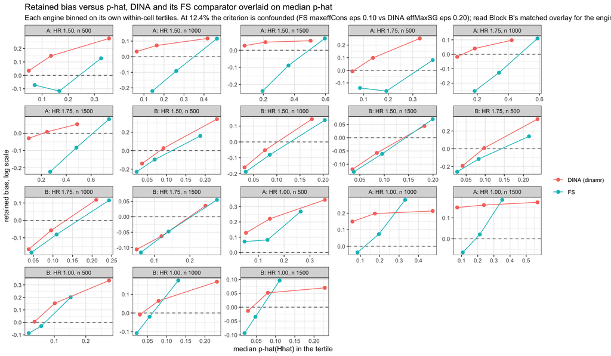

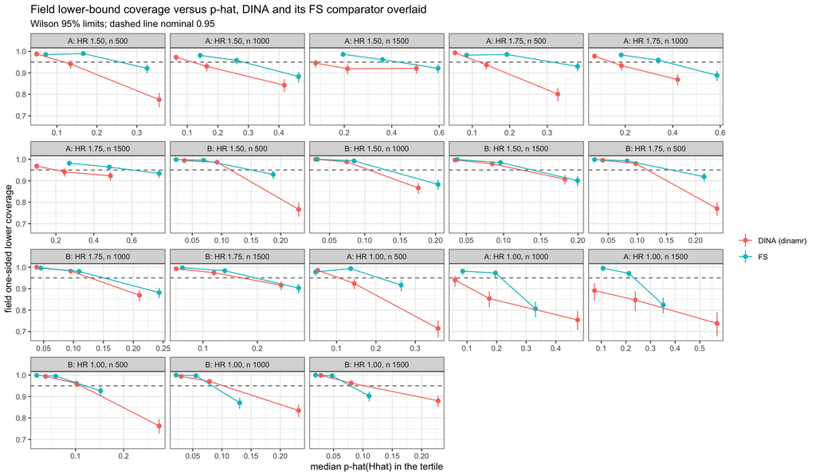

```r
if (!have(labs) || !exists("FSP") || !have(FSP)) skip_note("the bias-versus-p-hat overlay") else {
OV <- FSP
OV$cellf <- factor(OV$cell, levels = labs)
print(ggplot(OV, aes(p_hat_med, retained_bias_log, colour = engine, group = engine)) +
  geom_hline(yintercept = 0, linetype = 2, colour = "grey40") +
  geom_point(size = 2) + geom_line() +
  facet_wrap(~ cellf, scales = "free") +
  labs(x = "median p-hat(Hhat) in the tertile", y = "retained bias, log scale", colour = NULL,
       title = "Retained bias versus p-hat, DINA and its FS comparator overlaid on median p-hat",
       subtitle = "Each engine binned on its own within-cell tertiles. At 12.4% the criterion is confounded (FS maxeffCons eps 0.10 vs DINA effMaxSG eps 0.20); read Block B's matched overlay for the engine comparison.") +
  theme_bw(base_size = 10))
print(ggplot(OV, aes(p_hat_med, fldH_cov, colour = engine, group = engine)) +
  geom_hline(yintercept = 0.95, linetype = 2, colour = "grey40") +
  geom_pointrange(aes(ymin = wilson_lo, ymax = wilson_hi), size = 0.3) + geom_line() +
  facet_wrap(~ cellf, scales = "free_x") +
  labs(x = "median p-hat(Hhat) in the tertile", y = "field one-sided lower coverage", colour = NULL,
       title = "Field lower-bound coverage versus p-hat, DINA and its FS comparator overlaid",
       subtitle = "Wilson 95% limits; dashed line nominal 0.95") +
  theme_bw(base_size = 10))
}
```

# 10 The null cells (HR 1.00)

> **What HR 1.00 is on this path, verified from source (Gate 0, `TASK_dinamr_blockC_grfprobe_2026-09-11`).** It is **a planted region with HR 1.00 inside it, not a global null.** `FS_S7_HR` sets `target_hr_harm`, which “calibrate[s] `k_inter` to this Cox HR **in the harm subgroup**” (`sim_fs_maxeffCons_fb_mr_field_m1_template.qmd:340`). The harm rule itself is `{er <= quantile(er, z1_quantile)} & {meno == 0}` (template lines 344–346), **the same form at every HR** and a function of `FS_S7_Z1Q` alone – HR does not enter it. The DGM is pinned at `dgm_model <- "alt"` (template line 488), a literal with no environment override; the harness’s genuine global-null path (`model = "null"`, “uniform treatment effect”, `R/sim_aft_gbsg.R:93`) is unreachable from this template. So `HR 1.00` names the calibration target inside a region that is planted regardless, and the calibration confirms it: `k_inter` is **not** zero (+0.567917 at 12.4%, -8.579297 at 31%), and the planted contrast is **HR(H) = 1.00 against HR(Hᶜ) = 0.657 (12.4%) and 0.721 (31%)**, with overall causal HR 0.685 and 0.792. The treatment effect is heterogeneous at these cells: the planted region is **differentially null against a benefiting complement**, not harmed. Because there is no planted harm at these cells, this section uses no harm vocabulary for them.

> **Which quantities are structurally undefined here: none of the classification set.** Because the region indicator is planted by the rule and not by the effect size, `harm_col <- "flag_harm"` (template line 661) resolves at HR 1.00 exactly as it does at HR 1.50, with super-population prevalence 0.1242 and 0.3065. The per-replicate **oracle** θ̂(H) is a Cox fit on that same planted region and is defined (its target is simply log 1.00 = 0); **sens, spec, PPV and NPV** are defined against the same planted H and are finite on every detected replicate. The only columns that are structurally absent here are the ones already structurally absent on **every** DINA cell – `n_cons_qual`, `band_n` (present, all-NA: no consistency screen) and `p_star` (not a recorder column at all) – and they are reported as such in Section 1.2, never as failures. No quantity in this document is dropped, NA-ed or suppressed on account of HR 1.00.

> **The rate here is a `selection_rate`, and nothing more is read into it (Larry, 2026-09-11).** The planted region carries HR 1.00 and DINA’s effect floor is log(0.90), **deliberately sub-null**, so a replicate that returns that region is making an **admissible selection** under the criterion in force. Naming the rate for an error would mislabel correct behaviour, so it is named for what it counts and read as nothing else.

> **What speaks to a false claim is bound location, not selection.** Section 10.2 reports, per Block C cell, the share of field lower bounds **at or above 1.00** and **at or above 1.25** — the same columns as the Block A location table (`scripts_dinamr/blockA_rest.R:74-75`) — and those columns carry the question. The selection rate does not.

> **Vocabulary in Block C.** These cells have no planted harm, so no harm vocabulary is used for them anywhere in this section. The planted region is described as **differentially null against a benefiting complement**: HR = 1.00 inside it, HR = 0.657 (12.4%) / 0.721 (31%) outside it. Every Block C caption states this beside the conditional-on-proposed-family label.

What is recorded is the selection rate under the screen and, among selections, where every bound sits relative to the realized β(Ĥ) and β(Ĥᶜ) of whatever region DINA returned. Nothing here is scored.

**Criterion match at the null, as everywhere else.** The FS comparator is `cert20` (`effMaxSG`, ε 0.20) at all three n at **31% – criterion-matched to DINA**; and `tier2` at n 500 / `p12ext` at n 1000 and 1500 (`maxeffCons`, ε 0.10) at **12.4% – not matched**, where the criterion is the fourth confounded difference set out in Section 7. Every FS number below carries its own `campaign / sg_focus / eps`.

```r
if (!length(null_labs)) skip_note("the null-cell table (no HR 1.00 cell on disk)") else {
NUL <- do.call(rbind, lapply(null_labs, function(k) {
  r <- B[[k]]$results; d <- prep(r)
  if (!nrow(d)) return(NULL)
  data.frame(cell = k, block = BLK[[k]], n = NN[[k]], selection_rate = mean(r$detected %in% 1L),
             n_eval = nrow(d), K_med = stats::median(r$n_family, na.rm = TRUE),
             beta_H_mean = mean(d$betaHhat_H), beta_Hc_mean = mean(d$betaHhat_Hc),
             harm_field_1s = mean(d$betaHhat_H >= d$fld_H_lo1s),
             comp_field_s_1s = mean(d$betaHhat_Hc <= d$fld_Hc_up1s_s),
             comp_field_1s = mean(d$betaHhat_Hc <= d$fld_Hc_up1s),
             H_lower_mean = mean(d$fld_H_lo1s),
             share_H_lower_ge_100 = mean(d$fld_H_lo1s >= 1.00),
             share_H_lower_ge_125 = mean(d$fld_H_lo1s >= 1.25),
             Hc_upper_mean = mean(d$fld_Hc_up1s_s),
             share_Hc_upper_lt_085 = mean(d$fld_Hc_up1s_s < 0.85),
             share_Hc_upper_lt_080 = mean(d$fld_Hc_up1s_s < 0.80)) }))
if (!have(NUL)) skip_note("the null-cell table") else
kbl(NUL, digits = 4, booktabs = TRUE, row.names = FALSE,
    caption = paste("Null cells, both prevalence blocks: the SELECTION RATE under the screen -- a selection rate and nothing more, since the planted region clears DINA's deliberately sub-null log(0.90) floor and returning it is an admissible selection; the median proposed-family size; among selections the realized beta on the region and on its complement, the one-sided rate of each bound against its own realized beta, and THE BOUNDS BY LOCATION (share of the region's lower bound at or above 1.00 and at or above 1.25; share of the complement upper bound below 0.85 and 0.80). Bound location, not the selection rate, is what speaks to a false claim -- see @sec-null-location. Recorded, not scored.",
                    "Conditional-on-proposed-family estimand throughout, on selected replicates only. BLOCK C CELLS ARE DIFFERENTIALLY NULL AGAINST A BENEFITING COMPLEMENT -- the planted region carries HR 1.00 and its complement HR 0.657 (12.4%) / 0.721 (31%) -- so there is no planted harm here and no harm vocabulary is used.")) |>
  kable_styling(font_size = 9)
}
```

Null cells, both prevalence blocks: the SELECTION RATE under the screen -- a selection rate and nothing more, since the planted region clears DINA's deliberately sub-null log(0.90) floor and returning it is an admissible selection; the median proposed-family size; among selections the realized beta on the region and on its complement, the one-sided rate of each bound against its own realized beta, and THE BOUNDS BY LOCATION (share of the region's lower bound at or above 1.00 and at or above 1.25; share of the complement upper bound below 0.85 and 0.80). Bound location, not the selection rate, is what speaks to a false claim -- see @sec-null-location. Recorded, not scored. Conditional-on-proposed-family estimand throughout, on selected replicates only. BLOCK C CELLS ARE DIFFERENTIALLY NULL AGAINST A BENEFITING COMPLEMENT -- the planted region carries HR 1.00 and its complement HR 0.657 (12.4%) / 0.721 (31%) -- so there is no planted harm here and no harm vocabulary is used.

| cell | block | n | selection_rate | n_eval | K_med | beta_H_mean | beta_Hc_mean | harm_field_1s | comp_field_s_1s | comp_field_1s | H_lower_mean | share_H_lower_ge_100 | share_H_lower_ge_125 | Hc_upper_mean | share_Hc_upper_lt_085 | share_Hc_upper_lt_080 |
| --- | --- | --- | --- | --- | --- | --- | --- | --- | --- | --- | --- | --- | --- | --- | --- | --- |
| A: HR 1.00, n 500 | A | 500 | 0.7135 | 1427 | 137.0 | 0.6908 | 0.6627 | 0.8746 | 0.9299 | 0.9271 | 0.5232 | 0.0189 | 0.0035 | 0.8235 | 0.6076 | 0.4261 |
| A: HR 1.00, n 1000 | A | 1000 | 0.5245 | 1049 | 66.0 | 0.7108 | 0.6602 | 0.8494 | 0.9466 | 0.9438 | 0.5884 | 0.0162 | 0.0010 | 0.7741 | 0.8294 | 0.6549 |
| A: HR 1.00, n 1500 | A | 1500 | 0.3435 | 687 | 36.0 | 0.7275 | 0.6581 | 0.8253 | 0.9534 | 0.9520 | 0.6318 | 0.0087 | 0.0015 | 0.7502 | 0.9534 | 0.8137 |
| B: HR 1.00, n 500 | B | 500 | 0.9300 | 1860 | 485.5 | 0.8312 | 0.7663 | 0.9059 | 0.9027 | 0.8946 | 0.5881 | 0.0301 | 0.0086 | 0.9316 | 0.2747 | 0.1559 |
| B: HR 1.00, n 1000 | B | 1000 | 0.9260 | 1852 | 349.0 | 0.8632 | 0.7562 | 0.9330 | 0.9320 | 0.9239 | 0.6383 | 0.0157 | 0.0032 | 0.8710 | 0.4163 | 0.1998 |
| B: HR 1.00, n 1500 | B | 1500 | 0.8880 | 1776 | 278.5 | 0.8839 | 0.7449 | 0.9471 | 0.9358 | 0.9251 | 0.6847 | 0.0096 | 0.0017 | 0.8387 | 0.5749 | 0.3018 |

## 10.1 Every product at the null, absolute levels

```r
if (!have(VSN) || !have(VSN[VSN$arm == "null", ])) skip_note("the null-cell product table") else {
vn <- VSN[VSN$arm == "null", ]
# Block C carries no planted harm, so the shared column names -- built for the
# harm blocks -- are renamed here to region / complement vocabulary.
vn2 <- vn[, c("cell","block","n","n_eval","harm_field","harm_field_lo","harm_field_hi",
              "ij2_H","ij2_H_lo","ij2_H_hi","miss_below","miss_above",
              "comp_field_s","comp_field_s_lo","comp_field_s_hi","comp_field",
              "ij2_Hc","ij2_Hc_lo","ij2_Hc_hi",
              "joint_bonf","joint_s_bonf","joint_s_bonf_lo","joint_s_bonf_hi")]
names(vn2) <- c("cell","block","n","n_eval","region_field","region_field_lo","region_field_hi",
                "region_ij2","region_ij2_lo","region_ij2_hi","miss_below","miss_above",
                "compl_field_s","compl_field_s_lo","compl_field_s_hi","compl_field",
                "compl_ij2","compl_ij2_lo","compl_ij2_hi",
                "joint_bonf","joint_s_bonf","joint_s_bonf_lo","joint_s_bonf_hi")
kbl(vn2, digits = 4, booktabs = TRUE, row.names = FALSE,
    caption = paste("BLOCK C (HR 1.00), both prevalence blocks, EVERY PRODUCT AT ITS ABSOLUTE LEVEL -- not a difference from FS. One-sided 95% LOWER coverage of beta(Hhat) on the identified region by the field bound; two-sided IJ two-term on the region with the miss split by side; one-sided UPPER coverage of beta(Hhat^c) by field-s with the unscaled field beside it; two-sided IJ two-term on the complement; and both Bonferroni joint pairs. Wilson limits throughout.",
                    "Conditional-on-proposed-family estimand throughout, on selected replicates only. BLOCK C CELLS ARE DIFFERENTIALLY NULL AGAINST A BENEFITING COMPLEMENT -- the planted region carries HR 1.00 and its complement HR 0.657 (12.4%) / 0.721 (31%) -- so there is no planted harm here and no harm vocabulary is used.",
                    "beta(Hhat) and beta(Hhat^c) are the realized targets of whatever region DINA returned.")) |>
  kable_styling(font_size = 8) |> scroll_box(width = "100%")
}
```

BLOCK C (HR 1.00), both prevalence blocks, EVERY PRODUCT AT ITS ABSOLUTE LEVEL -- not a difference from FS. One-sided 95% LOWER coverage of beta(Hhat) on the identified region by the field bound; two-sided IJ two-term on the region with the miss split by side; one-sided UPPER coverage of beta(Hhat^c) by field-s with the unscaled field beside it; two-sided IJ two-term on the complement; and both Bonferroni joint pairs. Wilson limits throughout. Conditional-on-proposed-family estimand throughout, on selected replicates only. BLOCK C CELLS ARE DIFFERENTIALLY NULL AGAINST A BENEFITING COMPLEMENT -- the planted region carries HR 1.00 and its complement HR 0.657 (12.4%) / 0.721 (31%) -- so there is no planted harm here and no harm vocabulary is used. beta(Hhat) and beta(Hhat^c) are the realized targets of whatever region DINA returned.

| cell | block | n | n_eval | region_field | region_field_lo | region_field_hi | region_ij2 | region_ij2_lo | region_ij2_hi | miss_below | miss_above | compl_field_s | compl_field_s_lo | compl_field_s_hi | compl_field | compl_ij2 | compl_ij2_lo | compl_ij2_hi | joint_bonf | joint_s_bonf | joint_s_bonf_lo | joint_s_bonf_hi |
| --- | --- | --- | --- | --- | --- | --- | --- | --- | --- | --- | --- | --- | --- | --- | --- | --- | --- | --- | --- | --- | --- | --- |
| A: HR 1.00, n 500 | A | 500 | 1427 | 0.8746 | 0.8564 | 0.8907 | 0.9916 | 0.9854 | 0.9952 | 0.0077 | 7e-04 | 0.9299 | 0.9155 | 0.9420 | 0.9271 | 1.0000 | 0.9973 | 1.0000 | 0.9026 | 0.9075 | 0.8914 | 0.9215 |
| A: HR 1.00, n 1000 | A | 1000 | 1049 | 0.8494 | 0.8265 | 0.8697 | 0.9886 | 0.9801 | 0.9934 | 0.0114 | 0e+00 | 0.9466 | 0.9313 | 0.9587 | 0.9438 | 1.0000 | 0.9964 | 1.0000 | 0.8856 | 0.8875 | 0.8670 | 0.9052 |
| A: HR 1.00, n 1500 | A | 1500 | 687 | 0.8253 | 0.7951 | 0.8519 | 0.9898 | 0.9791 | 0.9951 | 0.0102 | 0e+00 | 0.9534 | 0.9350 | 0.9668 | 0.9520 | 1.0000 | 0.9944 | 1.0000 | 0.8821 | 0.8821 | 0.8558 | 0.9041 |
| B: HR 1.00, n 500 | B | 500 | 1860 | 0.9059 | 0.8918 | 0.9184 | 0.9919 | 0.9867 | 0.9951 | 0.0081 | 0e+00 | 0.9027 | 0.8884 | 0.9153 | 0.8946 | 1.0000 | 0.9979 | 1.0000 | 0.8957 | 0.9027 | 0.8884 | 0.9153 |
| B: HR 1.00, n 1000 | B | 1000 | 1852 | 0.9330 | 0.9207 | 0.9436 | 0.9941 | 0.9894 | 0.9967 | 0.0059 | 0e+00 | 0.9320 | 0.9196 | 0.9426 | 0.9239 | 0.9989 | 0.9961 | 0.9997 | 0.9255 | 0.9325 | 0.9202 | 0.9431 |
| B: HR 1.00, n 1500 | B | 1500 | 1776 | 0.9471 | 0.9357 | 0.9566 | 0.9966 | 0.9926 | 0.9985 | 0.0028 | 6e-04 | 0.9358 | 0.9234 | 0.9463 | 0.9251 | 1.0000 | 0.9978 | 1.0000 | 0.9381 | 0.9414 | 0.9295 | 0.9514 |

## 10.2 Bound location in Block C

This is the table that speaks to a false claim. The selection rate does not: returning a region that clears a deliberately sub-null floor is admissible. **Where the lower bound sits** is the question, and it is asked with the same columns as the Block A location table (`scripts_dinamr/blockA_rest.R:63-76`), including the two share columns at **1.00** and **1.25**.

```r
if (!length(null_labs)) skip_note("the Block C location table") else {
LOC <- do.call(rbind, lapply(null_labs, function(k) {
  b <- B[[k]]; d <- prep(b$results)
  if (!nrow(d)) return(NULL)
  data.frame(cell = k, block = BLK[[k]], n = NN[[k]], n_eval = nrow(d),
             med_fld_H_lo1s   = stats::median(d$fld_H_lo1s),
             med_theta_Hhat   = stats::median(d$betaHhat_H),
             med_fld_H_est2   = stats::median(d$fld_H_est2),
             med_naive_H      = stats::median(d$nv_H_est),
             bound_minus_theta = stats::median(d$fld_H_lo1s) - stats::median(d$betaHhat_H),
             bound_over_theta  = stats::median(d$fld_H_lo1s) / stats::median(d$betaHhat_H),
             med_paired_ratio  = stats::median(d$fld_H_lo1s / d$betaHhat_H),
             planted_marg_H    = unname(b$truth$marg_H),
             share_bound_ge_1.00 = mean(d$fld_H_lo1s >= 1.00),
             share_bound_ge_1.25 = mean(d$fld_H_lo1s >= 1.25)) }))
if (!have(LOC)) skip_note("the Block C location table") else
kbl(LOC, digits = 4, booktabs = TRUE, row.names = FALSE,
    caption = paste("BLOCK C, BOUND LOCATION -- the same columns as the Block A location table (scripts_dinamr/blockA_rest.R:63-76). The median field lower bound against the median realized theta(Hhat) on the HR scale, the field point estimate and the naive estimate beside them, the bound-to-target gap in difference, ratio and paired-ratio form, the planted marginal target, and THE TWO SHARE COLUMNS: the share of field lower bounds at or above 1.00 and at or above 1.25. These shares are what speak to a claim the data do not support; the selection rate does not, since the planted region clears DINA's deliberately sub-null log(0.90) floor and returning it is admissible.",
                    "Conditional-on-proposed-family estimand throughout, on selected replicates only. BLOCK C CELLS ARE DIFFERENTIALLY NULL AGAINST A BENEFITING COMPLEMENT -- the planted region carries HR 1.00 and its complement HR 0.657 (12.4%) / 0.721 (31%) -- so there is no planted harm here and no harm vocabulary is used.")) |>
  kable_styling(font_size = 9)
}
```

BLOCK C, BOUND LOCATION -- the same columns as the Block A location table (scripts_dinamr/blockA_rest.R:63-76). The median field lower bound against the median realized theta(Hhat) on the HR scale, the field point estimate and the naive estimate beside them, the bound-to-target gap in difference, ratio and paired-ratio form, the planted marginal target, and THE TWO SHARE COLUMNS: the share of field lower bounds at or above 1.00 and at or above 1.25. These shares are what speak to a claim the data do not support; the selection rate does not, since the planted region clears DINA's deliberately sub-null log(0.90) floor and returning it is admissible. Conditional-on-proposed-family estimand throughout, on selected replicates only. BLOCK C CELLS ARE DIFFERENTIALLY NULL AGAINST A BENEFITING COMPLEMENT -- the planted region carries HR 1.00 and its complement HR 0.657 (12.4%) / 0.721 (31%) -- so there is no planted harm here and no harm vocabulary is used.

| cell | block | n | n_eval | med_fld_H_lo1s | med_theta_Hhat | med_fld_H_est2 | med_naive_H | bound_minus_theta | bound_over_theta | med_paired_ratio | planted_marg_H | share_bound_ge_1.00 | share_bound_ge_1.25 |
| --- | --- | --- | --- | --- | --- | --- | --- | --- | --- | --- | --- | --- | --- |
| A: HR 1.00, n 500 | A | 500 | 1427 | 0.4924 | 0.6833 | 0.8413 | 1.2960 | -0.1909 | 0.7207 | 0.7159 | 1.0005 | 0.0189 | 0.0035 |
| A: HR 1.00, n 1000 | A | 1000 | 1049 | 0.5721 | 0.7096 | 0.8364 | 1.0913 | -0.1375 | 0.8062 | 0.8064 | 1.0005 | 0.0162 | 0.0010 |
| A: HR 1.00, n 1500 | A | 1500 | 687 | 0.6119 | 0.7267 | 0.8371 | 1.0128 | -0.1147 | 0.8421 | 0.8599 | 1.0005 | 0.0087 | 0.0015 |
| B: HR 1.00, n 500 | B | 500 | 1860 | 0.5556 | 0.8320 | 0.9408 | 1.5388 | -0.2763 | 0.6679 | 0.6651 | 0.9999 | 0.0301 | 0.0086 |
| B: HR 1.00, n 1000 | B | 1000 | 1852 | 0.6206 | 0.8767 | 0.9025 | 1.2326 | -0.2561 | 0.7079 | 0.7155 | 0.9999 | 0.0157 | 0.0032 |
| B: HR 1.00, n 1500 | B | 1500 | 1776 | 0.6705 | 0.9016 | 0.8969 | 1.1000 | -0.2311 | 0.7437 | 0.7615 | 0.9999 | 0.0096 | 0.0017 |

## 10.3 The null cells beside their FS comparator, with the criterion named

```r
if (!length(null_labs)) skip_note("the null-cell FS comparison") else {
NFS <- do.call(rbind, lapply(null_labs, function(k) {
  x <- fs_for(k); r <- B[[k]]$results
  dn <- r[r$detected %in% 1L & is.finite(r$betaHhat_H) & is.finite(r$fld_H_lo1s), , drop = FALSE]
  row <- data.frame(cell = k, block = BLK[[k]], n = NN[[k]],
    dina_criterion = "dinamr / effMaxSG / eps 0.2",
    dina_selection = mean(r$detected %in% 1L),
    dina_K_med = stats::median(r$n_family, na.rm = TRUE),
    dina_field_H = if (nrow(dn)) mean(dn$betaHhat_H >= dn$fld_H_lo1s) else NA_real_,
    dina_ij2_H = if (nrow(dn)) mean(dn$betaHhat_H >= dn$mr_H_lo & dn$betaHhat_H <= dn$mr_H_hi) else NA_real_)
  if (is.null(x)) return(cbind(row, fs_criterion = "not on disk", fs_matched = NA,
                               fs_selection = NA_real_, fs_K_med = NA_real_,
                               fs_field_H = NA_real_, fs_ij2_H = NA_real_))
  fr <- x$b$results
  fd <- fr[fr$detected %in% 1L & is.finite(fr$betaHhat_H) & is.finite(fr$fld_H_lo1s), , drop = FALSE]
  cbind(row, fs_criterion = fs_crit(x),
        fs_matched = identical(x$focus, "effMaxSG") && isTRUE(all.equal(x$eps, 0.20)),
        fs_selection = mean(fr$detected %in% 1L),
        fs_K_med = stats::median(fr$n_family, na.rm = TRUE),
        fs_field_H = if (nrow(fd)) mean(fd$betaHhat_H >= fd$fld_H_lo1s) else NA_real_,
        fs_ij2_H = if (nrow(fd)) mean(fd$betaHhat_H >= fd$mr_H_lo & fd$betaHhat_H <= fd$mr_H_hi) else NA_real_) }))
if (!have(NFS)) skip_note("the null-cell FS comparison") else
kbl(NFS, digits = 4, booktabs = TRUE, row.names = FALSE,
    caption = paste("Block C beside the committed FS comparator that shares the DGM draws, read as it stands. ABSOLUTE LEVELS on both sides; no difference column, and no contest. fs_matched is TRUE only where the FS comparator's own sg_focus and eps equal DINA's (effMaxSG, 0.20) -- TRUE at 31% (cert20), FALSE at 12.4% (tier2 / p12ext, maxeffCons at eps 0.10), where the criterion is a fourth confounded difference on top of identifier, family construction and detection set. dina_selection / fs_selection are selection rates and nothing more: the planted region clears DINA's sub-null log(0.90) floor, so returning it is an admissible selection.",
                    "Conditional-on-proposed-family estimand throughout, on selected replicates only. BLOCK C CELLS ARE DIFFERENTIALLY NULL AGAINST A BENEFITING COMPLEMENT -- the planted region carries HR 1.00 and its complement HR 0.657 (12.4%) / 0.721 (31%) -- so there is no planted harm here and no harm vocabulary is used.")) |>
  kable_styling(font_size = 9)
}
```

Block C beside the committed FS comparator that shares the DGM draws, read as it stands. ABSOLUTE LEVELS on both sides; no difference column, and no contest. fs_matched is TRUE only where the FS comparator's own sg_focus and eps equal DINA's (effMaxSG, 0.20) -- TRUE at 31% (cert20), FALSE at 12.4% (tier2 / p12ext, maxeffCons at eps 0.10), where the criterion is a fourth confounded difference on top of identifier, family construction and detection set. dina_selection / fs_selection are selection rates and nothing more: the planted region clears DINA's sub-null log(0.90) floor, so returning it is an admissible selection. Conditional-on-proposed-family estimand throughout, on selected replicates only. BLOCK C CELLS ARE DIFFERENTIALLY NULL AGAINST A BENEFITING COMPLEMENT -- the planted region carries HR 1.00 and its complement HR 0.657 (12.4%) / 0.721 (31%) -- so there is no planted harm here and no harm vocabulary is used.

| cell | block | n | dina_criterion | dina_selection | dina_K_med | dina_field_H | dina_ij2_H | fs_criterion | fs_matched | fs_selection | fs_K_med | fs_field_H | fs_ij2_H |
| --- | --- | --- | --- | --- | --- | --- | --- | --- | --- | --- | --- | --- | --- |
| A: HR 1.00, n 500 | A | 500 | dinamr / effMaxSG / eps 0.2 | 0.7135 | 137.0 | 0.8746 | 0.9916 | tier2 / maxeffCons / eps 0.1 | FALSE | 0.6805 | 1223 | 0.9625 | 0.9860 |
| A: HR 1.00, n 1000 | A | 1000 | dinamr / effMaxSG / eps 0.2 | 0.5245 | 66.0 | 0.8494 | 0.9886 | p12ext / maxeffCons / eps 0.1 | FALSE | 0.6595 | 1300 | 0.9204 | 0.9803 |
| A: HR 1.00, n 1500 | A | 1500 | dinamr / effMaxSG / eps 0.2 | 0.3435 | 36.0 | 0.8253 | 0.9898 | p12ext / maxeffCons / eps 0.1 | FALSE | 0.6240 | 1297 | 0.9303 | 0.9824 |
| B: HR 1.00, n 500 | B | 500 | dinamr / effMaxSG / eps 0.2 | 0.9300 | 485.5 | 0.9059 | 0.9919 | cert20 / effMaxSG / eps 0.2 | TRUE | 0.9205 | 1223 | 0.9734 | 0.9946 |
| B: HR 1.00, n 1000 | B | 1000 | dinamr / effMaxSG / eps 0.2 | 0.9260 | 349.0 | 0.9330 | 0.9941 | cert20 / effMaxSG / eps 0.2 | TRUE | 0.9545 | 1299 | 0.9560 | 0.9948 |
| B: HR 1.00, n 1500 | B | 1500 | dinamr / effMaxSG / eps 0.2 | 0.8880 | 278.5 | 0.9471 | 0.9966 | cert20 / effMaxSG / eps 0.2 | TRUE | 0.9590 | 1297 | 0.9666 | 0.9964 |

# 11 Numbers for the record

**Detection and proposed-family size (the headline):**

- A: HR 1.50, n 500: detection 0.875 (1750/2000); family size median 253.5, q90 1111.2; realized trial prevalence 0.124
- A: HR 1.50, n 1000: detection 0.839 (1677/2000); family size median 156, q90 628; realized trial prevalence 0.124
- A: HR 1.50, n 1500: detection 0.798 (1597/2000); family size median 103, q90 394; realized trial prevalence 0.124
- A: HR 1.75, n 500: detection 0.908 (1816/2000); family size median 332, q90 1273.5; realized trial prevalence 0.124
- A: HR 1.75, n 1000: detection 0.906 (1813/2000); family size median 232, q90 807.2; realized trial prevalence 0.124
- A: HR 1.75, n 1500: detection 0.898 (1796/2000); family size median 177, q90 526; realized trial prevalence 0.124
- B: HR 1.50, n 500: detection 0.999 (1997/2000); family size median 1495, q90 2880.8; realized trial prevalence 0.306
- B: HR 1.50, n 1000: detection 1.000 (2000/2000); family size median 1709.5, q90 2984.3; realized trial prevalence 0.306
- B: HR 1.50, n 1500: detection 1.000 (2000/2000); family size median 1743.5, q90 2850.3; realized trial prevalence 0.306
- B: HR 1.75, n 500: detection 1.000 (2000/2000); family size median 1954.5, q90 2982.2; realized trial prevalence 0.306
- B: HR 1.75, n 1000: detection 1.000 (2000/2000); family size median 2257.5, q90 3160; realized trial prevalence 0.306
- B: HR 1.75, n 1500: detection 1.000 (2000/2000); family size median 2355.5, q90 3108; realized trial prevalence 0.306
- A: HR 1.00, n 500: detection 0.714 (1427/2000); family size median 137, q90 745.6; realized trial prevalence 0.124
- A: HR 1.00, n 1000: detection 0.524 (1049/2000); family size median 66, q90 355.4; realized trial prevalence 0.124
- A: HR 1.00, n 1500: detection 0.344 (687/2000); family size median 36, q90 211.2; realized trial prevalence 0.124
- B: HR 1.00, n 500: detection 0.930 (1860/2000); family size median 485.5, q90 1965.4; realized trial prevalence 0.306
- B: HR 1.00, n 1000: detection 0.926 (1852/2000); family size median 349, q90 1347.8; realized trial prevalence 0.306
- B: HR 1.00, n 1500: detection 0.888 (1776/2000); family size median 278.5, q90 895.5; realized trial prevalence 0.306

**Coverage versus n (harm cells; field lower / field-s upper / IJ two-sided H / IJ two-sided Hc / joint_s Bonferroni) – conditional-on-proposed-family throughout:**

- A: HR 1.50, n 500 (n_eval 1750): harm field 0.902 [0.887, 0.915]; complement field-s 0.922 [0.909, 0.934] (field 0.921); IJ two-sided 0.995 / 1.000; joint_s Bonferroni 0.909 [0.894, 0.921]
- A: HR 1.50, n 1000 (n_eval 1677): harm field 0.915 [0.901, 0.928]; complement field-s 0.942 [0.930, 0.952] (field 0.941); IJ two-sided 0.989 / 0.999; joint_s Bonferroni 0.928 [0.915, 0.940]
- A: HR 1.50, n 1500 (n_eval 1597): harm field 0.929 [0.915, 0.940]; complement field-s 0.946 [0.934, 0.956] (field 0.940); IJ two-sided 0.992 / 1.000; joint_s Bonferroni 0.935 [0.922, 0.946]
- A: HR 1.75, n 500 (n_eval 1816): harm field 0.911 [0.897, 0.923]; complement field-s 0.921 [0.908, 0.933] (field 0.918); IJ two-sided 0.995 / 1.000; joint_s Bonferroni 0.917 [0.903, 0.929]
- A: HR 1.75, n 1000 (n_eval 1813): harm field 0.927 [0.914, 0.938]; complement field-s 0.939 [0.927, 0.949] (field 0.938); IJ two-sided 0.991 / 0.999; joint_s Bonferroni 0.930 [0.917, 0.941]
- A: HR 1.75, n 1500 (n_eval 1796): harm field 0.944 [0.933, 0.954]; complement field-s 0.949 [0.938, 0.958] (field 0.948); IJ two-sided 0.991 / 1.000; joint_s Bonferroni 0.942 [0.930, 0.951]
- B: HR 1.50, n 500 (n_eval 1997): harm field 0.916 [0.903, 0.927]; complement field-s 0.910 [0.897, 0.922] (field 0.900); IJ two-sided 0.990 / 1.000; joint_s Bonferroni 0.912 [0.899, 0.924]
- B: HR 1.50, n 1000 (n_eval 2000): harm field 0.952 [0.941, 0.960]; complement field-s 0.936 [0.925, 0.946] (field 0.928); IJ two-sided 0.987 / 1.000; joint_s Bonferroni 0.946 [0.935, 0.955]
- B: HR 1.50, n 1500 (n_eval 2000): harm field 0.961 [0.952, 0.969]; complement field-s 0.942 [0.931, 0.951] (field 0.932); IJ two-sided 0.984 / 1.000; joint_s Bonferroni 0.954 [0.943, 0.962]
- B: HR 1.75, n 500 (n_eval 2000): harm field 0.915 [0.902, 0.927]; complement field-s 0.919 [0.907, 0.931] (field 0.916); IJ two-sided 0.987 / 1.000; joint_s Bonferroni 0.908 [0.895, 0.920]
- B: HR 1.75, n 1000 (n_eval 2000): harm field 0.951 [0.940, 0.959]; complement field-s 0.944 [0.933, 0.953] (field 0.940); IJ two-sided 0.977 / 1.000; joint_s Bonferroni 0.944 [0.933, 0.953]
- B: HR 1.75, n 1500 (n_eval 2000): harm field 0.961 [0.952, 0.969]; complement field-s 0.944 [0.933, 0.953] (field 0.935); IJ two-sided 0.980 / 1.000; joint_s Bonferroni 0.952 [0.942, 0.961]

**The two-sided harm-block trajectory at 12.4%, miss split by side:**

- A: HR 1.50, n 500: IJ two-sided 0.995 [0.990, 0.997]; miss below 0.004, miss above 0.001
- A: HR 1.50, n 1000: IJ two-sided 0.989 [0.982, 0.993]; miss below 0.009, miss above 0.002
- A: HR 1.50, n 1500: IJ two-sided 0.992 [0.987, 0.996]; miss below 0.003, miss above 0.005
- A: HR 1.75, n 500: IJ two-sided 0.995 [0.991, 0.997]; miss below 0.005, miss above 0.000
- A: HR 1.75, n 1000: IJ two-sided 0.991 [0.986, 0.995]; miss below 0.006, miss above 0.003
- A: HR 1.75, n 1500: IJ two-sided 0.991 [0.986, 0.995]; miss below 0.003, miss above 0.006

**Classification versus n and prevalence:**

- A: HR 1.50, n 500: detection 0.875; sens 0.530 spec 0.852 ppv 0.349 npv 0.929; |Hhat|/|H| median 1.476 q90 2.260; beta(Hhat) 0.882 vs planted 1.509; beta(Hhat^c) 0.679 vs planted 0.657; naive optimism 1.954 marginal-SD / 1.781 error-SD (H), -0.747 / -0.780 (Hc); mean p-hat 0.196; family median 253.5
- A: HR 1.50, n 1000: detection 0.839; sens 0.650 spec 0.895 ppv 0.492 npv 0.948; |Hhat|/|H| median 1.304 q90 1.976; beta(Hhat) 1.009 vs planted 1.509; beta(Hhat^c) 0.665 vs planted 0.657; naive optimism 1.363 marginal-SD / 1.437 error-SD (H), -0.518 / -0.519 (Hc); mean p-hat 0.228; family median 156
- A: HR 1.50, n 1500: detection 0.798; sens 0.727 spec 0.903 ppv 0.546 npv 0.959; |Hhat|/|H| median 1.299 q90 1.978; beta(Hhat) 1.056 vs planted 1.509; beta(Hhat^c) 0.658 vs planted 0.657; naive optimism 0.964 marginal-SD / 1.223 error-SD (H), -0.434 / -0.436 (Hc); mean p-hat 0.277; family median 103
- A: HR 1.75, n 500: detection 0.908; sens 0.593 spec 0.867 ppv 0.408 npv 0.939; |Hhat|/|H| median 1.445 q90 2.233; beta(Hhat) 1.006 vs planted 1.769; beta(Hhat^c) 0.680 vs planted 0.657; naive optimism 1.737 marginal-SD / 1.639 error-SD (H), -0.710 / -0.736 (Hc); mean p-hat 0.189; family median 332
- A: HR 1.75, n 1000: detection 0.906; sens 0.726 spec 0.916 ppv 0.582 npv 0.960; |Hhat|/|H| median 1.248 q90 1.824; beta(Hhat) 1.210 vs planted 1.769; beta(Hhat^c) 0.662 vs planted 0.657; naive optimism 1.053 marginal-SD / 1.195 error-SD (H), -0.443 / -0.442 (Hc); mean p-hat 0.238; family median 232
- A: HR 1.75, n 1500: detection 0.898; sens 0.804 spec 0.928 ppv 0.643 npv 0.971; |Hhat|/|H| median 1.245 q90 1.730; beta(Hhat) 1.281 vs planted 1.769; beta(Hhat^c) 0.653 vs planted 0.657; naive optimism 0.680 marginal-SD / 0.915 error-SD (H), -0.357 / -0.352 (Hc); mean p-hat 0.296; family median 177
- B: HR 1.50, n 500: detection 0.999; sens 0.497 spec 0.902 ppv 0.674 npv 0.808; |Hhat|/|H| median 0.667 q90 1.048; beta(Hhat) 1.228 vs planted 1.499; beta(Hhat^c) 0.827 vs planted 0.721; naive optimism 1.916 marginal-SD / 1.581 error-SD (H), -0.776 / -0.880 (Hc); mean p-hat 0.130; family median 1495
- B: HR 1.50, n 1000: detection 1.000; sens 0.642 spec 0.933 ppv 0.799 npv 0.863; |Hhat|/|H| median 0.776 q90 1.148; beta(Hhat) 1.346 vs planted 1.499; beta(Hhat^c) 0.790 vs planted 0.721; naive optimism 1.376 marginal-SD / 1.154 error-SD (H), -0.593 / -0.737 (Hc); mean p-hat 0.104; family median 1709.5
- B: HR 1.50, n 1500: detection 1.000; sens 0.788 spec 0.939 ppv 0.850 npv 0.918; |Hhat|/|H| median 0.999 q90 1.248; beta(Hhat) 1.393 vs planted 1.499; beta(Hhat^c) 0.754 vs planted 0.721; naive optimism 0.877 marginal-SD / 0.775 error-SD (H), -0.472 / -0.591 (Hc); mean p-hat 0.110; family median 1743.5
- B: HR 1.75, n 500: detection 1.000; sens 0.538 spec 0.921 ppv 0.733 npv 0.824; |Hhat|/|H| median 0.669 q90 1.043; beta(Hhat) 1.460 vs planted 1.746; beta(Hhat^c) 0.841 vs planted 0.721; naive optimism 1.754 marginal-SD / 1.401 error-SD (H), -0.672 / -0.788 (Hc); mean p-hat 0.138; family median 1954.5
- B: HR 1.75, n 1000: detection 1.000; sens 0.689 spec 0.950 ppv 0.848 npv 0.882; |Hhat|/|H| median 0.806 q90 1.137; beta(Hhat) 1.609 vs planted 1.746; beta(Hhat^c) 0.794 vs planted 0.721; naive optimism 1.174 marginal-SD / 0.975 error-SD (H), -0.452 / -0.598 (Hc); mean p-hat 0.125; family median 2257.5
- B: HR 1.75, n 1500: detection 1.000; sens 0.822 spec 0.955 ppv 0.889 npv 0.931; |Hhat|/|H| median 1.000 q90 1.198; beta(Hhat) 1.660 vs planted 1.746; beta(Hhat^c) 0.755 vs planted 0.721; naive optimism 0.683 marginal-SD / 0.615 error-SD (H), -0.353 / -0.466 (Hc); mean p-hat 0.149; family median 2355.5
- A: HR 1.00, n 500: detection 0.714; sens 0.346 spec 0.825 ppv 0.218 npv 0.900; |Hhat|/|H| median 1.483 q90 2.342; beta(Hhat) 0.691 vs planted 1.000; beta(Hhat^c) 0.663 vs planted 0.657; naive optimism 2.390 marginal-SD / 2.225 error-SD (H), -0.734 / -0.744 (Hc); mean p-hat 0.206; family median 137
- A: HR 1.00, n 1000: detection 0.524; sens 0.378 spec 0.852 ppv 0.269 npv 0.907; |Hhat|/|H| median 1.325 q90 2.090; beta(Hhat) 0.711 vs planted 1.000; beta(Hhat^c) 0.660 vs planted 0.657; naive optimism 2.488 marginal-SD / 2.338 error-SD (H), -0.492 / -0.507 (Hc); mean p-hat 0.249; family median 66
- A: HR 1.00, n 1500: detection 0.344; sens 0.421 spec 0.866 ppv 0.314 npv 0.914; |Hhat|/|H| median 1.260 q90 2.008; beta(Hhat) 0.728 vs planted 1.000; beta(Hhat^c) 0.658 vs planted 0.657; naive optimism 2.642 marginal-SD / 2.420 error-SD (H), -0.363 / -0.367 (Hc); mean p-hat 0.308; family median 36
- B: HR 1.00, n 500: detection 0.930; sens 0.356 spec 0.849 ppv 0.497 npv 0.753; |Hhat|/|H| median 0.636 q90 1.056; beta(Hhat) 0.831 vs planted 1.000; beta(Hhat^c) 0.766 vs planted 0.721; naive optimism 2.123 marginal-SD / 1.977 error-SD (H), -0.948 / -0.982 (Hc); mean p-hat 0.155; family median 485.5
- B: HR 1.00, n 1000: detection 0.926; sens 0.457 spec 0.870 ppv 0.593 npv 0.790; |Hhat|/|H| median 0.684 q90 1.160; beta(Hhat) 0.863 vs planted 1.000; beta(Hhat^c) 0.756 vs planted 0.721; naive optimism 1.857 marginal-SD / 1.666 error-SD (H), -0.884 / -0.957 (Hc); mean p-hat 0.131; family median 349
- B: HR 1.00, n 1500: detection 0.888; sens 0.578 spec 0.871 ppv 0.656 npv 0.833; |Hhat|/|H| median 0.830 q90 1.307; beta(Hhat) 0.884 vs planted 1.000; beta(Hhat^c) 0.745 vs planted 0.721; naive optimism 1.585 marginal-SD / 1.411 error-SD (H), -0.848 / -0.947 (Hc); mean p-hat 0.134; family median 278.5

**Proposed-family size and its stabilization:**

- A: HR 1.50, n 500: K min 1, q10 18, median 253.5, q90 1111.2, max 3229; mean 437.071, SD 524.887, CV 1.201, IQR/median 2.026
- A: HR 1.50, n 1000: K min 1, q10 14, median 156, q90 628, max 2596; mean 258.035, SD 305.729, CV 1.185, IQR/median 1.917
- A: HR 1.50, n 1500: K min 1, q10 8, median 103, q90 394, max 1954; mean 166.482, SD 190.082, CV 1.142, IQR/median 2.000
- A: HR 1.75, n 500: K min 1, q10 28, median 332, q90 1273.5, max 3246; mean 516.394, SD 570.480, CV 1.105, IQR/median 1.795
- A: HR 1.75, n 1000: K min 1, q10 26, median 232, q90 807.2, max 2721; mean 336.753, SD 356.543, CV 1.059, IQR/median 1.595
- A: HR 1.75, n 1500: K min 1, q10 18, median 177, q90 526, max 2315; mean 236.622, SD 236.851, CV 1.001, IQR/median 1.516
- B: HR 1.50, n 500: K min 3, q10 407.6, median 1495, q90 2880.8, max 3556; mean 1597.258, SD 900.429, CV 0.564, IQR/median 0.992
- B: HR 1.50, n 1000: K min 48, q10 662.8, median 1709.5, q90 2984.3, max 3814; mean 1784.682, SD 844.589, CV 0.473, IQR/median 0.790
- B: HR 1.50, n 1500: K min 55, q10 760.7, median 1743.5, q90 2850.3, max 3794; mean 1782.546, SD 772.647, CV 0.433, IQR/median 0.679
- B: HR 1.75, n 500: K min 37, q10 667, median 1954.5, q90 2982.2, max 3557; mean 1890.439, SD 848.429, CV 0.449, IQR/median 0.697
- B: HR 1.75, n 1000: K min 241, q10 1185.8, median 2257.5, q90 3160, max 3821; mean 2211.533, SD 745.448, CV 0.337, IQR/median 0.512
- B: HR 1.75, n 1500: K min 384, q10 1341.9, median 2355.5, q90 3108, max 3726; mean 2276.633, SD 673.402, CV 0.296, IQR/median 0.440
- A: HR 1.00, n 500: K min 1, q10 13, median 137, q90 745.6, max 3224; mean 292.771, SD 416.286, CV 1.422, IQR/median 2.423
- A: HR 1.00, n 1000: K min 1, q10 5.8, median 66, q90 355.4, max 1611; mean 140.819, SD 200.289, CV 1.422, IQR/median 2.333
- A: HR 1.00, n 1500: K min 1, q10 2, median 36, q90 211.2, max 1186; mean 80.527, SD 117.396, CV 1.458, IQR/median 2.569
- B: HR 1.00, n 500: K min 1, q10 42, median 485.5, q90 1965.4, max 3476; mean 766.597, SD 772.826, CV 1.008, IQR/median 1.967
- B: HR 1.00, n 1000: K min 1, q10 37.1, median 349, q90 1347.8, max 3739; mean 553.530, SD 599.559, CV 1.083, IQR/median 1.741
- B: HR 1.00, n 1500: K min 1, q10 29, median 278.5, q90 895.5, max 3364; mean 392.918, SD 423.503, CV 1.078, IQR/median 1.440

**The stable-pick stratum (p-hat tertiles, observed -> Gaussian-implied):**

- A: HR 1.50, n 500: harm field 0.988 / 0.942 / 0.775 (implied 0.981 / 0.908 / 0.724); complement field-s 0.966 / 0.931 / 0.870 (implied 0.970 / 0.938 / 0.855); mean ef_s +0.0146 / -0.0207 / -0.0814
- A: HR 1.50, n 1000: harm field 0.973 / 0.930 / 0.843 (implied 0.963 / 0.912 / 0.809); complement field-s 0.966 / 0.962 / 0.898 (implied 0.972 / 0.953 / 0.893); mean ef_s +0.0267 / -0.0044 / -0.0457
- A: HR 1.50, n 1500: harm field 0.946 / 0.919 / 0.921 (implied 0.944 / 0.904 / 0.863); complement field-s 0.966 / 0.957 / 0.915 (implied 0.968 / 0.952 / 0.918); mean ef_s +0.0187 / -0.0066 / -0.0289
- A: HR 1.75, n 500: harm field 0.993 / 0.937 / 0.801 (implied 0.984 / 0.921 / 0.751); complement field-s 0.952 / 0.944 / 0.868 (implied 0.958 / 0.948 / 0.869); mean ef_s +0.0107 / -0.0176 / -0.0676
- A: HR 1.75, n 1000: harm field 0.979 / 0.934 / 0.869 (implied 0.970 / 0.920 / 0.844); complement field-s 0.969 / 0.942 / 0.905 (implied 0.969 / 0.944 / 0.907); mean ef_s +0.0250 / -0.0016 / -0.0358
- A: HR 1.75, n 1500: harm field 0.968 / 0.941 / 0.923 (implied 0.953 / 0.941 / 0.884); complement field-s 0.965 / 0.960 / 0.922 (implied 0.963 / 0.956 / 0.921); mean ef_s +0.0181 / +0.0020 / -0.0272
- B: HR 1.50, n 500: harm field 0.994 / 0.987 / 0.767 (implied 0.995 / 0.967 / 0.709); complement field-s 0.946 / 0.910 / 0.873 (implied 0.943 / 0.907 / 0.886); mean ef_s -0.0108 / -0.0364 / -0.0499
- B: HR 1.50, n 1000: harm field 1.000 / 0.988 / 0.867 (implied 0.999 / 0.989 / 0.817); complement field-s 0.972 / 0.938 / 0.900 (implied 0.967 / 0.937 / 0.906); mean ef_s +0.0186 / -0.0166 / -0.0354
- B: HR 1.50, n 1500: harm field 0.997 / 0.979 / 0.907 (implied 0.997 / 0.983 / 0.894); complement field-s 0.966 / 0.949 / 0.912 (implied 0.957 / 0.947 / 0.911); mean ef_s +0.0164 / -0.0037 / -0.0293
- B: HR 1.75, n 500: harm field 0.996 / 0.980 / 0.770 (implied 0.997 / 0.967 / 0.711); complement field-s 0.954 / 0.907 / 0.898 (implied 0.952 / 0.911 / 0.903); mean ef_s +0.0039 / -0.0363 / -0.0421
- B: HR 1.75, n 1000: harm field 1.000 / 0.982 / 0.869 (implied 0.998 / 0.985 / 0.839); complement field-s 0.972 / 0.951 / 0.908 (implied 0.966 / 0.946 / 0.916); mean ef_s +0.0207 / -0.0096 / -0.0295
- B: HR 1.75, n 1500: harm field 0.993 / 0.975 / 0.916 (implied 0.993 / 0.983 / 0.909); complement field-s 0.961 / 0.955 / 0.916 (implied 0.960 / 0.947 / 0.912); mean ef_s +0.0154 / -0.0024 / -0.0270
- A: HR 1.00, n 500: harm field 0.985 / 0.924 / 0.714 (implied 0.972 / 0.881 / 0.669); complement field-s 0.956 / 0.943 / 0.891 (implied 0.973 / 0.940 / 0.893); mean ef_s +0.0184 / -0.0228 / -0.0677
- A: HR 1.00, n 1000: harm field 0.940 / 0.854 / 0.754 (implied 0.921 / 0.814 / 0.696); complement field-s 0.977 / 0.968 / 0.894 (implied 0.986 / 0.952 / 0.905); mean ef_s +0.0285 / -0.0089 / -0.0423
- A: HR 1.00, n 1500: harm field 0.891 / 0.847 / 0.738 (implied 0.865 / 0.775 / 0.696); complement field-s 0.978 / 0.965 / 0.917 (implied 0.975 / 0.967 / 0.916); mean ef_s +0.0171 / +0.0028 / -0.0321
- B: HR 1.00, n 500: harm field 0.994 / 0.961 / 0.763 (implied 0.994 / 0.932 / 0.695); complement field-s 0.950 / 0.914 / 0.844 (implied 0.951 / 0.923 / 0.836); mean ef_s -0.0085 / -0.0358 / -0.0821
- B: HR 1.00, n 1000: harm field 0.994 / 0.971 / 0.835 (implied 0.996 / 0.956 / 0.783); complement field-s 0.964 / 0.942 / 0.890 (implied 0.957 / 0.933 / 0.873); mean ef_s -0.0007 / -0.0198 / -0.0582
- B: HR 1.00, n 1500: harm field 0.998 / 0.963 / 0.880 (implied 0.996 / 0.946 / 0.852); complement field-s 0.978 / 0.947 / 0.882 (implied 0.968 / 0.943 / 0.880); mean ef_s +0.0053 / -0.0209 / -0.0491

**Null cells (recorded, not scored):**

- A: HR 1.00, n 500: selection rate 0.714; beta(Hhat) 0.691, beta(Hhat^c) 0.663; harm lower one-sided rate 0.875, complement field-s upper 0.930; harm lower mean 0.523 (share >= 1.00 0.019); complement upper mean 0.823 (share < 0.80 0.426)
- A: HR 1.00, n 1000: selection rate 0.524; beta(Hhat) 0.711, beta(Hhat^c) 0.660; harm lower one-sided rate 0.849, complement field-s upper 0.947; harm lower mean 0.588 (share >= 1.00 0.016); complement upper mean 0.774 (share < 0.80 0.655)
- A: HR 1.00, n 1500: selection rate 0.344; beta(Hhat) 0.728, beta(Hhat^c) 0.658; harm lower one-sided rate 0.825, complement field-s upper 0.953; harm lower mean 0.632 (share >= 1.00 0.009); complement upper mean 0.750 (share < 0.80 0.814)
- B: HR 1.00, n 500: selection rate 0.930; beta(Hhat) 0.831, beta(Hhat^c) 0.766; harm lower one-sided rate 0.906, complement field-s upper 0.903; harm lower mean 0.588 (share >= 1.00 0.030); complement upper mean 0.932 (share < 0.80 0.156)
- B: HR 1.00, n 1000: selection rate 0.926; beta(Hhat) 0.863, beta(Hhat^c) 0.756; harm lower one-sided rate 0.933, complement field-s upper 0.932; harm lower mean 0.638 (share >= 1.00 0.016); complement upper mean 0.871 (share < 0.80 0.200)
- B: HR 1.00, n 1500: selection rate 0.888; beta(Hhat) 0.884, beta(Hhat^c) 0.745; harm lower one-sided rate 0.947, complement field-s upper 0.936; harm lower mean 0.685 (share >= 1.00 0.010); complement upper mean 0.839 (share < 0.80 0.302)

**Null cells, every product at its absolute level (conditional-on-proposed-family throughout):**

- A: HR 1.00, n 500 (n_eval 1427): harm field 0.875 [0.856, 0.891]; IJ two-sided H 0.992 [0.985, 0.995] (miss below 0.008, above 0.001); complement field-s 0.930 [0.915, 0.942] (field 0.927); IJ two-sided Hc 1.000 [0.997, 1.000]; joint Bonferroni 0.903; joint_s Bonferroni 0.907 [0.891, 0.921]
- A: HR 1.00, n 1000 (n_eval 1049): harm field 0.849 [0.826, 0.870]; IJ two-sided H 0.989 [0.980, 0.993] (miss below 0.011, above 0.000); complement field-s 0.947 [0.931, 0.959] (field 0.944); IJ two-sided Hc 1.000 [0.996, 1.000]; joint Bonferroni 0.886; joint_s Bonferroni 0.888 [0.867, 0.905]
- A: HR 1.00, n 1500 (n_eval 687): harm field 0.825 [0.795, 0.852]; IJ two-sided H 0.990 [0.979, 0.995] (miss below 0.010, above 0.000); complement field-s 0.953 [0.935, 0.967] (field 0.952); IJ two-sided Hc 1.000 [0.994, 1.000]; joint Bonferroni 0.882; joint_s Bonferroni 0.882 [0.856, 0.904]
- B: HR 1.00, n 500 (n_eval 1860): harm field 0.906 [0.892, 0.918]; IJ two-sided H 0.992 [0.987, 0.995] (miss below 0.008, above 0.000); complement field-s 0.903 [0.888, 0.915] (field 0.895); IJ two-sided Hc 1.000 [0.998, 1.000]; joint Bonferroni 0.896; joint_s Bonferroni 0.903 [0.888, 0.915]
- B: HR 1.00, n 1000 (n_eval 1852): harm field 0.933 [0.921, 0.944]; IJ two-sided H 0.994 [0.989, 0.997] (miss below 0.006, above 0.000); complement field-s 0.932 [0.920, 0.943] (field 0.924); IJ two-sided Hc 0.999 [0.996, 1.000]; joint Bonferroni 0.925; joint_s Bonferroni 0.933 [0.920, 0.943]
- B: HR 1.00, n 1500 (n_eval 1776): harm field 0.947 [0.936, 0.957]; IJ two-sided H 0.997 [0.993, 0.998] (miss below 0.003, above 0.001); complement field-s 0.936 [0.923, 0.946] (field 0.925); IJ two-sided Hc 1.000 [0.998, 1.000]; joint Bonferroni 0.938; joint_s Bonferroni 0.941 [0.930, 0.951]

*Block C is differentially null against a benefiting complement, not a global null (Gate 0, Section 10): k_inter is nonzero and HR(region) = 1.00 sits against HR(complement) = 0.657 at 12.4% and 0.721 at 31%. The rate at these cells is a selection rate and nothing more – the planted region clears DINA’s deliberately sub-null log(0.90) floor, so returning it is an admissible selection. What speaks to a false claim is bound location, below.*

**Block C bound location – the columns that speak to a claim the data do not support:**

- A: HR 1.00, n 500: median field lower bound 0.492 against median theta(Hhat) 0.683 (ratio 0.721, paired-ratio median 0.716); planted marginal target 1.000; SHARE OF LOWER BOUNDS >= 1.00 0.019, >= 1.25 0.004
- A: HR 1.00, n 1000: median field lower bound 0.572 against median theta(Hhat) 0.710 (ratio 0.806, paired-ratio median 0.806); planted marginal target 1.000; SHARE OF LOWER BOUNDS >= 1.00 0.016, >= 1.25 0.001
- A: HR 1.00, n 1500: median field lower bound 0.612 against median theta(Hhat) 0.727 (ratio 0.842, paired-ratio median 0.860); planted marginal target 1.000; SHARE OF LOWER BOUNDS >= 1.00 0.009, >= 1.25 0.001
- B: HR 1.00, n 500: median field lower bound 0.556 against median theta(Hhat) 0.832 (ratio 0.668, paired-ratio median 0.665); planted marginal target 1.000; SHARE OF LOWER BOUNDS >= 1.00 0.030, >= 1.25 0.009
- B: HR 1.00, n 1000: median field lower bound 0.621 against median theta(Hhat) 0.877 (ratio 0.708, paired-ratio median 0.716); planted marginal target 1.000; SHARE OF LOWER BOUNDS >= 1.00 0.016, >= 1.25 0.003
- B: HR 1.00, n 1500: median field lower bound 0.670 against median theta(Hhat) 0.902 (ratio 0.744, paired-ratio median 0.761); planted marginal target 1.000; SHARE OF LOWER BOUNDS >= 1.00 0.010, >= 1.25 0.002

**Null cells beside the FS comparator, absolute levels, criterion named:**

- A: HR 1.00, n 500: DINA selection 0.714, family median 137, field 0.875, IJ two-sided 0.992 | FS (tier2 / maxeffCons / eps 0.1, criterion-matched FALSE) selection 0.680, family median 1223, field 0.963, IJ two-sided 0.986
- A: HR 1.00, n 1000: DINA selection 0.524, family median 66, field 0.849, IJ two-sided 0.989 | FS (p12ext / maxeffCons / eps 0.1, criterion-matched FALSE) selection 0.659, family median 1300, field 0.920, IJ two-sided 0.980
- A: HR 1.00, n 1500: DINA selection 0.344, family median 36, field 0.825, IJ two-sided 0.990 | FS (p12ext / maxeffCons / eps 0.1, criterion-matched FALSE) selection 0.624, family median 1297, field 0.930, IJ two-sided 0.982
- B: HR 1.00, n 500: DINA selection 0.930, family median 485.5, field 0.906, IJ two-sided 0.992 | FS (cert20 / effMaxSG / eps 0.2, criterion-matched TRUE) selection 0.920, family median 1223, field 0.973, IJ two-sided 0.995
- B: HR 1.00, n 1000: DINA selection 0.926, family median 349, field 0.933, IJ two-sided 0.994 | FS (cert20 / effMaxSG / eps 0.2, criterion-matched TRUE) selection 0.955, family median 1299, field 0.956, IJ two-sided 0.995
- B: HR 1.00, n 1500: DINA selection 0.888, family median 278.5, field 0.947, IJ two-sided 0.997 | FS (cert20 / effMaxSG / eps 0.2, criterion-matched TRUE) selection 0.959, family median 1297, field 0.967, IJ two-sided 0.996

**No acceptance criteria.** None was pre-registered for this campaign and none is proposed. The FS ranges in Section 7 are reference lines only. Exploratory; report and wait.